# W3cubDocs

/Matplotlib 3.1

# matplotlib.collections

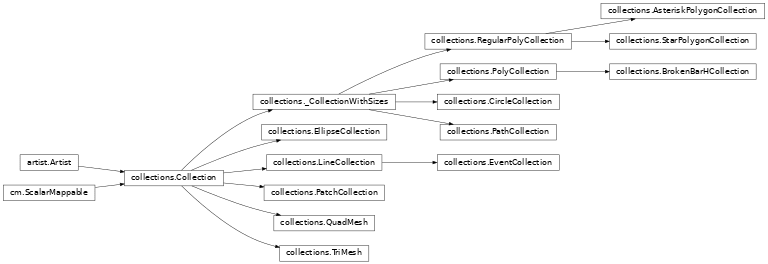

Classes for the efficient drawing of large collections of objects that share most properties, e.g., a large number of line segments or polygons.

The classes are not meant to be as flexible as their single element counterparts (e.g., you may not be able to select all line styles) but they are meant to be fast for common use cases (e.g., a large set of solid line segments).

**`class matplotlib.collections.AsteriskPolygonCollection(numsides, rotation=0, sizes=(1, ), **kwargs)` [[source]](https://matplotlib.org/3.1.1/_modules/matplotlib/collections.html#AsteriskPolygonCollection)**

Bases: `matplotlib.collections.RegularPolyCollection`

Draw a collection of regular asterisks with *numsides* points.

**numsides**

the number of sides of the polygon

**rotation**

the rotation of the polygon in radians

**sizes**

gives the area of the circle circumscribing the regular polygon in points^2

Valid Collection keyword arguments:

- *edgecolors*: None
- *facecolors*: None
- *linewidths*: None
- *antialiaseds*: None
- *offsets*: None
- *transOffset*: transforms.IdentityTransform()
- *norm*: None (optional for `matplotlib.cm.ScalarMappable`)
- *cmap*: None (optional for `matplotlib.cm.ScalarMappable`)

*offsets* and *transOffset* are used to translate the patch after rendering (default no offsets)

If any of *edgecolors*, *facecolors*, *linewidths*, *antialiaseds* are None, they default to their `matplotlib.rcParams` patch setting, in sequence form.

Example: see [Lasso Demo](https://matplotlib.org/3.1.1/gallery/event_handling/lasso_demo.html) for a complete example:

```
offsets = np.random.rand(20,2)
facecolors = [cm.jet(x) for x in np.random.rand(20)]
black = (0,0,0,1)

collection = RegularPolyCollection(
    numsides=5, # a pentagon
    rotation=0, sizes=(50,),
    facecolors=facecolors,
    edgecolors=(black,),
    linewidths=(1,),
    offsets=offsets,
    transOffset=ax.transData,
    )
```

**`add_callback(self, func)`**

Add a callback function that will be called whenever one of the `Artist`'s properties changes.

Parameters:

**`func : callable`**

The callback function. It must have the signature:

```
def func(artist: Artist) -> Any
```

where *artist* is the calling `Artist`. Return values may exist but are ignored.

Returns:

**`oid : int`**

The observer id associated with the callback. This id can be used for removing the callback with `remove_callback` later.

See also

**`remove_callback`**

**`add_checker(self, checker)`**

Add an entry to a dictionary of boolean flags that are set to True when the mappable is changed.

**`aname`**

**`autoscale(self)`**

Autoscale the scalar limits on the norm instance using the current array

**`autoscale_None(self)`**

Autoscale the scalar limits on the norm instance using the current array, changing only limits that are None

**`axes`**

The `Axes` instance the artist resides in, or *None*.

**`changed(self)`**

Call this whenever the mappable is changed to notify all the callbackSM listeners to the 'changed' signal

**`check_update(self, checker)`**

If mappable has changed since the last check, return True; else return False

**`contains(self, mouseevent)`**

Test whether the mouse event occurred in the collection.

Returns `bool, dict(ind=itemlist)`, where every item in itemlist contains the event.

**`convert_xunits(self, x)`**

Convert *x* using the unit type of the xaxis.

If the artist is not in contained in an Axes or if the xaxis does not have units, *x* itself is returned.

**`convert_yunits(self, y)`**

Convert *y* using the unit type of the yaxis.

If the artist is not in contained in an Axes or if the yaxis does not have units, *y* itself is returned.

**`draw(self, renderer)`**

Draw the Artist using the given renderer.

This method will be overridden in the Artist subclasses. Typically, it is implemented to not have any effect if the Artist is not visible (`Artist.get_visible` is *False*).

| Parameters: | **`renderer : RendererBase subclass.`** |
| --- | --- |

**`findobj(self, match=None, include_self=True)`**

Find artist objects.

Recursively find all `Artist` instances contained in the artist.

Parameters:

**match**

A filter criterion for the matches. This can be

- *None*: Return all objects contained in artist.
- A function with signature `def match(artist: Artist) -> bool`. The result will only contain artists for which the function returns *True*.
- A class instance: e.g., `Line2D`. The result will only contain artists of this class or its subclasses (`isinstance` check).

**`include_self : bool`**

Include *self* in the list to be checked for a match.

Returns:

**`artists : list of Artist`**

**`format_cursor_data(self, data)`**

Return a string representation of *data*.

Note

This method is intended to be overridden by artist subclasses. As an end-user of Matplotlib you will most likely not call this method yourself.

The default implementation converts ints and floats and arrays of ints and floats into a comma-separated string enclosed in square brackets.

See also

**`get_cursor_data`**

**`get_agg_filter(self)`**

Return filter function to be used for agg filter.

**`get_alpha(self)`**

Return the alpha value used for blending - not supported on all backends

**`get_animated(self)`**

Return the animated state.

**`get_array(self)`**

Return the array

**`get_capstyle(self)`**

**`get_children(self)`**

Return a list of the child `Artist`s of this `Artist`.

**`get_clim(self)`**

return the min, max of the color limits for image scaling

**`get_clip_box(self)`**

Return the clipbox.

**`get_clip_on(self)`**

Return whether the artist uses clipping.

**`get_clip_path(self)`**

Return the clip path.

**`get_cmap(self)`**

return the colormap

**`get_contains(self)`**

Return the custom contains function of the artist if set, or *None*.

See also

**`set_contains`**

**`get_cursor_data(self, event)`**

Return the cursor data for a given event.

Note

This method is intended to be overridden by artist subclasses. As an end-user of Matplotlib you will most likely not call this method yourself.

Cursor data can be used by Artists to provide additional context information for a given event. The default implementation just returns *None*.

Subclasses can override the method and return arbitrary data. However, when doing so, they must ensure that `format_cursor_data` can convert the data to a string representation.

The only current use case is displaying the z-value of an `AxesImage` in the status bar of a plot window, while moving the mouse.

| Parameters: | **`event : matplotlib.backend_bases.MouseEvent`** |
| --- | --- |

See also

**`format_cursor_data`**

**`get_dashes(self)`**

Alias for `get_linestyle`.

**`get_datalim(self, transData)`**

**`get_ec(self)`**

Alias for `get_edgecolor`.

**`get_edgecolor(self)`**

**`get_edgecolors(self)`**

Alias for `get_edgecolor`.

**`get_facecolor(self)`**

**`get_facecolors(self)`**

Alias for `get_facecolor`.

**`get_fc(self)`**

Alias for `get_facecolor`.

**`get_figure(self)`**

Return the `Figure` instance the artist belongs to.

**`get_fill(self)`**

return whether fill is set

**`get_gid(self)`**

Return the group id.

**`get_hatch(self)`**

Return the current hatching pattern.

**`get_in_layout(self)`**

Return boolean flag, `True` if artist is included in layout calculations.

E.g. [Constrained Layout Guide](https://matplotlib.org/3.1.1/tutorials/intermediate/constrainedlayout_guide.html), `Figure.tight_layout()`, and `fig.savefig(fname, bbox_inches='tight')`.

**`get_joinstyle(self)`**

**`get_label(self)`**

Return the label used for this artist in the legend.

**`get_linestyle(self)`**

**`get_linestyles(self)`**

Alias for `get_linestyle`.

**`get_linewidth(self)`**

**`get_linewidths(self)`**

Alias for `get_linewidth`.

**`get_ls(self)`**

Alias for `get_linestyle`.

**`get_lw(self)`**

Alias for `get_linewidth`.

**`get_numsides(self)`**

**`get_offset_position(self)`**

Returns how offsets are applied for the collection. If *offset_position* is 'screen', the offset is applied after the master transform has been applied, that is, the offsets are in screen coordinates. If offset_position is 'data', the offset is applied before the master transform, i.e., the offsets are in data coordinates.

**`get_offset_transform(self)`**

**`get_offsets(self)`**

Return the offsets for the collection.

**`get_path_effects(self)`**

**`get_paths(self)`**

**`get_picker(self)`**

Return the picking behavior of the artist.

The possible values are described in `set_picker`.

See also

**`set_picker, pickable,` `pick`**

**`get_pickradius(self)`**

**`get_rasterized(self)`**

Return whether the artist is to be rasterized.

**`get_rotation(self)`**

**`get_sizes(self)`**

Returns the sizes of the elements in the collection. The value represents the 'area' of the element.

| Returns: | **`sizes : array`** The 'area' of each element. |
| --- | --- |

**`get_sketch_params(self)`**

Returns the sketch parameters for the artist.

Returns:

**`sketch_params : tuple or None`**

A 3-tuple with the following elements:

- *scale*: The amplitude of the wiggle perpendicular to the source line.
- *length*: The length of the wiggle along the line.
- *randomness*: The scale factor by which the length is shrunken or expanded.

Returns *None* if no sketch parameters were set.

**`get_snap(self)`**

Returns the snap setting.

See `set_snap` for details.

**`get_tightbbox(self, renderer)`**

Like `Artist.get_window_extent`, but includes any clipping.

| Parameters: | **`renderer : RendererBase instance`** renderer that will be used to draw the figures (i.e. `fig.canvas.get_renderer()`) |
| --- | --- |
| Returns: | **`bbox : BBox`** The enclosing bounding box (in figure pixel co-ordinates). |

**`get_transform(self)`**

Return the `Transform` instance used by this artist.

**`get_transformed_clip_path_and_affine(self)`**

Return the clip path with the non-affine part of its transformation applied, and the remaining affine part of its transformation.

**`get_transforms(self)`**

**`get_url(self)`**

Return the url.

**`get_urls(self)`**

**`get_visible(self)`**

Return the visibility.

**`get_window_extent(self, renderer)`**

Get the axes bounding box in display space.

The bounding box' width and height are nonnegative.

Subclasses should override for inclusion in the bounding box "tight" calculation. Default is to return an empty bounding box at 0, 0.

Be careful when using this function, the results will not update if the artist window extent of the artist changes. The extent can change due to any changes in the transform stack, such as changing the axes limits, the figure size, or the canvas used (as is done when saving a figure). This can lead to unexpected behavior where interactive figures will look fine on the screen, but will save incorrectly.

**`get_zorder(self)`**

Return the artist's zorder.

**`have_units(self)`**

Return *True* if units are set on the *x* or *y* axes.

**`is_transform_set(self)`**

Return whether the Artist has an explicitly set transform.

This is *True* after `set_transform` has been called.

**`mouseover`**

**`pchanged(self)`**

Call all of the registered callbacks.

This function is triggered internally when a property is changed.

See also

**`add_callback`**

**`remove_callback`**

**`pick(self, mouseevent)`**

Process a pick event.

Each child artist will fire a pick event if *mouseevent* is over the artist and the artist has picker set.

See also

**`set_picker, get_picker,` `pickable`**

**`pickable(self)`**

Return whether the artist is pickable.

See also

**`set_picker, get_picker,` `pick`**

**`properties(self)`**

Return a dictionary of all the properties of the artist.

**`remove(self)`**

Remove the artist from the figure if possible.

The effect will not be visible until the figure is redrawn, e.g., with `FigureCanvasBase.draw_idle`. Call `relim` to update the axes limits if desired.

Note: `relim` will not see collections even if the collection was added to the axes with *autolim* = True.

Note: there is no support for removing the artist's legend entry.

**`remove_callback(self, oid)`**

Remove a callback based on its observer id.

See also

**`add_callback`**

**`set(self, **kwargs)`**

A property batch setter. Pass *kwargs* to set properties.

**`set_aa(self, aa)`**

Alias for `set_antialiased`.

**`set_agg_filter(self, filter_func)`**

Set the agg filter.

| Parameters: | **`filter_func : callable`** A filter function, which takes a (m, n, 3) float array and a dpi value, and returns a (m, n, 3) array. |
| --- | --- |

**`set_alpha(self, alpha)`**

Set the alpha transparencies of the collection.

| Parameters: | **`alpha : float or None`** |
| --- | --- |

**`set_animated(self, b)`**

Set the artist's animation state.

| Parameters: | **`b : bool`** |
| --- | --- |

**`set_antialiased(self, aa)`**

Set the antialiasing state for rendering.

| Parameters: | **`aa : bool or sequence of bools`** |
| --- | --- |

**`set_antialiaseds(self, aa)`**

Alias for `set_antialiased`.

**`set_array(self, A)`**

Set the image array from numpy array *A*.

| Parameters: | **`A : ndarray`** |
| --- | --- |

**`set_capstyle(self, cs)`**

Set the capstyle for the collection (for all its elements).

| Parameters: | **`cs : {'butt', 'round', 'projecting'}`** The capstyle |
| --- | --- |

**`set_clim(self, vmin=None, vmax=None)`**

set the norm limits for image scaling; if *vmin* is a length2 sequence, interpret it as `(vmin, vmax)` which is used to support setp

ACCEPTS: a length 2 sequence of floats; may be overridden in methods that have `vmin` and `vmax` kwargs.

**`set_clip_box(self, clipbox)`**

Set the artist's clip `Bbox`.

| Parameters: | **`clipbox : Bbox`** |
| --- | --- |

**`set_clip_on(self, b)`**

Set whether the artist uses clipping.

When False artists will be visible out side of the axes which can lead to unexpected results.

| Parameters: | **`b : bool`** |
| --- | --- |

**`set_clip_path(self, path, transform=None)`**

Set the artist's clip path, which may be:

- a `Patch` (or subclass) instance; or
- a `Path` instance, in which case a `Transform` instance, which will be applied to the path before using it for clipping, must be provided; or
- `None`, to remove a previously set clipping path.

For efficiency, if the path happens to be an axis-aligned rectangle, this method will set the clipping box to the corresponding rectangle and set the clipping path to `None`.

ACCEPTS: [(`Path`, `Transform`) | `Patch` | None]

**`set_cmap(self, cmap)`**

set the colormap for luminance data

| Parameters: | **`cmap : colormap or registered colormap name`** |
| --- | --- |

**`set_color(self, c)`**

Set both the edgecolor and the facecolor.

| Parameters: | **`c : color or sequence of rgba tuples`** |
| --- | --- |

See also

**`Collection.set_facecolor,` `Collection.set_edgecolor`**

For setting the edge or face color individually.

**`set_contains(self, picker)`**

Define a custom contains test for the artist.

The provided callable replaces the default `contains` method of the artist.

Parameters:

**`picker : callable`**

A custom picker function to evaluate if an event is within the artist. The function must have the signature:

```
def contains(artist: Artist, event: MouseEvent) -> bool, dict
```

that returns:

- a bool indicating if the event is within the artist
- a dict of additional information. The dict should at least return the same information as the default `contains()` implementation of the respective artist, but may provide additional information.

**`set_dashes(self, ls)`**

Alias for `set_linestyle`.

**`set_ec(self, c)`**

Alias for `set_edgecolor`.

**`set_edgecolor(self, c)`**

Set the edgecolor(s) of the collection.

| Parameters: | **`c : color or sequence of colors or 'face'`** The collection edgecolor(s). If a sequence, the patches cycle through it. If 'face', match the facecolor. |
| --- | --- |

**`set_edgecolors(self, c)`**

Alias for `set_edgecolor`.

**`set_facecolor(self, c)`**

Set the facecolor(s) of the collection. *c* can be a matplotlib color spec (all patches have same color), or a sequence of specs; if it is a sequence the patches will cycle through the sequence.

If *c* is 'none', the patch will not be filled.

| Parameters: | **`c : color or sequence of colors`** |
| --- | --- |

**`set_facecolors(self, c)`**

Alias for `set_facecolor`.

**`set_fc(self, c)`**

Alias for `set_facecolor`.

**`set_figure(self, fig)`**

Set the `Figure` instance the artist belongs to.

| Parameters: | **`fig : Figure`** |
| --- | --- |

**`set_gid(self, gid)`**

Set the (group) id for the artist.

| Parameters: | **`gid : str`** |
| --- | --- |

**`set_hatch(self, hatch)`**

Set the hatching pattern

*hatch* can be one of:

```
/   - diagonal hatching
\   - back diagonal
|   - vertical
-   - horizontal
+   - crossed
x   - crossed diagonal
o   - small circle
O   - large circle
.   - dots
*   - stars
```

Letters can be combined, in which case all the specified hatchings are done. If same letter repeats, it increases the density of hatching of that pattern.

Hatching is supported in the PostScript, PDF, SVG and Agg backends only.

Unlike other properties such as linewidth and colors, hatching can only be specified for the collection as a whole, not separately for each member.

| Parameters: | **`hatch : {'/', '\\', '\|', '-', '+', 'x', 'o', 'O', '.', '*'}`** |
| --- | --- |

**`set_in_layout(self, in_layout)`**

Set if artist is to be included in layout calculations, E.g. [Constrained Layout Guide](https://matplotlib.org/3.1.1/tutorials/intermediate/constrainedlayout_guide.html), `Figure.tight_layout()`, and `fig.savefig(fname, bbox_inches='tight')`.

| Parameters: | **`in_layout : bool`** |
| --- | --- |

**`set_joinstyle(self, js)`**

Set the joinstyle for the collection (for all its elements).

| Parameters: | **`js : {'miter', 'round', 'bevel'}`** The joinstyle |
| --- | --- |

**`set_label(self, s)`**

Set a label that will be displayed in the legend.

| Parameters: | **`s : object`** *s* will be converted to a string by calling [`str`](https://docs.python.org/3/library/stdtypes.html#str). |
| --- | --- |

**`set_linestyle(self, ls)`**

Set the linestyle(s) for the collection.

| linestyle | description |
| --- | --- |
| `'-'` or `'solid'` | solid line |
| `'--'` or `'dashed'` | dashed line |
| `'-.'` or `'dashdot'` | dash-dotted line |
| `':'` or `'dotted'` | dotted line |

Alternatively a dash tuple of the following form can be provided:

```
(offset, onoffseq),
```

where `onoffseq` is an even length tuple of on and off ink in points.

| Parameters: | **`ls : {'-', '--', '-.', ':', '', (offset, on-off-seq), ...}`** The line style. |
| --- | --- |

**`set_linestyles(self, ls)`**

Alias for `set_linestyle`.

**`set_linewidth(self, lw)`**

Set the linewidth(s) for the collection. *lw* can be a scalar or a sequence; if it is a sequence the patches will cycle through the sequence

| Parameters: | **`lw : float or sequence of floats`** |
| --- | --- |

**`set_linewidths(self, lw)`**

Alias for `set_linewidth`.

**`set_ls(self, ls)`**

Alias for `set_linestyle`.

**`set_lw(self, lw)`**

Alias for `set_linewidth`.

**`set_norm(self, norm)`**

Set the normalization instance.

| Parameters: | **`norm : Normalize`** |
| --- | --- |

#### Notes

If there are any colorbars using the mappable for this norm, setting the norm of the mappable will reset the norm, locator, and formatters on the colorbar to default.

**`set_offset_position(self, offset_position)`**

Set how offsets are applied. If *offset_position* is 'screen' (default) the offset is applied after the master transform has been applied, that is, the offsets are in screen coordinates. If offset_position is 'data', the offset is applied before the master transform, i.e., the offsets are in data coordinates.

| Parameters: | **`offset_position : {'screen', 'data'}`** |
| --- | --- |

**`set_offsets(self, offsets)`**

Set the offsets for the collection.

| Parameters: | **`offsets : float or sequence of floats`** |
| --- | --- |

**`set_path_effects(self, path_effects)`**

Set the path effects.

| Parameters: | **`path_effects : AbstractPathEffect`** |
| --- | --- |

**`set_paths(self)`**

**`set_picker(self, picker)`**

Define the picking behavior of the artist.

Parameters:

**`picker : None or bool or float or callable`**

This can be one of the following:

- *None*: Picking is disabled for this artist (default).
- A boolean: If *True* then picking will be enabled and the artist will fire a pick event if the mouse event is over the artist.
- A float: If picker is a number it is interpreted as an epsilon tolerance in points and the artist will fire off an event if it's data is within epsilon of the mouse event. For some artists like lines and patch collections, the artist may provide additional data to the pick event that is generated, e.g., the indices of the data within epsilon of the pick event
- A function: If picker is callable, it is a user supplied function which determines whether the artist is hit by the mouse event:

  ```
  hit, props = picker(artist, mouseevent)
  ```

  to determine the hit test. if the mouse event is over the artist, return *hit=True* and props is a dictionary of properties you want added to the PickEvent attributes.

**`set_pickradius(self, pr)`**

Set the pick radius used for containment tests.

| Parameters: | **`d : float`** Pick radius, in points. |
| --- | --- |

**`set_rasterized(self, rasterized)`**

Force rasterized (bitmap) drawing in vector backend output.

Defaults to None, which implies the backend's default behavior.

| Parameters: | **`rasterized : bool or None`** |
| --- | --- |

**`set_sizes(self, sizes, dpi=72.0)`**

Set the sizes of each member of the collection.

| Parameters: | **`sizes : ndarray or None`** The size to set for each element of the collection. The value is the 'area' of the element. **`dpi : float`** The dpi of the canvas. Defaults to 72.0. |
| --- | --- |

**`set_sketch_params(self, scale=None, length=None, randomness=None)`**

Sets the sketch parameters.

[output not shown]

**`set_snap(self, snap)`**

Set the snapping behavior.

Snapping aligns positions with the pixel grid, which results in clearer images. For example, if a black line of 1px width was defined at a position in between two pixels, the resulting image would contain the interpolated value of that line in the pixel grid, which would be a grey value on both adjacent pixel positions. In contrast, snapping will move the line to the nearest integer pixel value, so that the resulting image will really contain a 1px wide black line.

Snapping is currently only supported by the Agg and MacOSX backends.

Parameters:

**`snap : bool or None`**

Possible values:

- *True*: Snap vertices to the nearest pixel center.
- *False*: Do not modify vertex positions.
- *None*: (auto) If the path contains only rectilinear line segments, round to the nearest pixel center.

**`set_transform(self, t)`**

Set the artist transform.

| Parameters: | **`t : Transform`** |
| --- | --- |

**`set_url(self, url)`**

Set the url for the artist.

| Parameters: | **`url : str`** |
| --- | --- |

**`set_urls(self, urls)`**

| Parameters: | **`urls : List[str] or None`** |
| --- | --- |

**`set_visible(self, b)`**

Set the artist's visibility.

| Parameters: | **`b : bool`** |
| --- | --- |

**`set_zorder(self, level)`**

Set the zorder for the artist. Artists with lower zorder values are drawn first.

| Parameters: | **`level : float`** |
| --- | --- |

**`stale`**

Whether the artist is 'stale' and needs to be re-drawn for the output to match the internal state of the artist.

**`sticky_edges`**

`x` and `y` sticky edge lists for autoscaling.

When performing autoscaling, if a data limit coincides with a value in the corresponding sticky_edges list, then no margin will be added--the view limit "sticks" to the edge. A typical use case is histograms, where one usually expects no margin on the bottom edge (0) of the histogram.

This attribute cannot be assigned to; however, the `x` and `y` lists can be modified in place as needed.

#### Examples

```
>>> artist.sticky_edges.x[:] = (xmin, xmax)
>>> artist.sticky_edges.y[:] = (ymin, ymax)
```

**`to_rgba(self, x, alpha=None, bytes=False, norm=True)`**

Return a normalized rgba array corresponding to *x*.

In the normal case, *x* is a 1-D or 2-D sequence of scalars, and the corresponding ndarray of rgba values will be returned, based on the norm and colormap set for this ScalarMappable.

There is one special case, for handling images that are already rgb or rgba, such as might have been read from an image file. If *x* is an ndarray with 3 dimensions, and the last dimension is either 3 or 4, then it will be treated as an rgb or rgba array, and no mapping will be done. The array can be uint8, or it can be floating point with values in the 0-1 range; otherwise a ValueError will be raised. If it is a masked array, the mask will be ignored. If the last dimension is 3, the *alpha* kwarg (defaulting to 1) will be used to fill in the transparency. If the last dimension is 4, the *alpha* kwarg is ignored; it does not replace the pre-existing alpha. A ValueError will be raised if the third dimension is other than 3 or 4.

In either case, if *bytes* is *False* (default), the rgba array will be floats in the 0-1 range; if it is *True*, the returned rgba array will be uint8 in the 0 to 255 range.

If norm is False, no normalization of the input data is performed, and it is assumed to be in the range (0-1).

**`update(self, props)`**

Update this artist's properties from the dictionary *props*.

**`update_from(self, other)`**

copy properties from other to self

**`update_scalarmappable(self)`**

Update colors from the scalar mappable array, if it is not None.

**`zorder = 0`**

**`class matplotlib.collections.BrokenBarHCollection(xranges, yrange, **kwargs)` [[source]](https://matplotlib.org/3.1.1/_modules/matplotlib/collections.html#BrokenBarHCollection)**

Bases: `matplotlib.collections.PolyCollection`

A collection of horizontal bars spanning *yrange* with a sequence of *xranges*.

**xranges**

sequence of (*xmin*, *xwidth*)

**yrange**

*ymin*, *ywidth*

Valid Collection keyword arguments:

- *edgecolors*: None
- *facecolors*: None
- *linewidths*: None
- *antialiaseds*: None
- *offsets*: None
- *transOffset*: transforms.IdentityTransform()
- *norm*: None (optional for `matplotlib.cm.ScalarMappable`)
- *cmap*: None (optional for `matplotlib.cm.ScalarMappable`)

*offsets* and *transOffset* are used to translate the patch after rendering (default no offsets)

If any of *edgecolors*, *facecolors*, *linewidths*, *antialiaseds* are None, they default to their `matplotlib.rcParams` patch setting, in sequence form.

**`add_callback(self, func)`**

Add a callback function that will be called whenever one of the `Artist`'s properties changes.

Parameters:

**`func : callable`**

The callback function. It must have the signature:

```
def func(artist: Artist) -> Any
```

where *artist* is the calling `Artist`. Return values may exist but are ignored.

Returns:

**`oid : int`**

The observer id associated with the callback. This id can be used for removing the callback with `remove_callback` later.

See also

**`remove_callback`**

**`add_checker(self, checker)`**

Add an entry to a dictionary of boolean flags that are set to True when the mappable is changed.

**`aname`**

**`autoscale(self)`**

Autoscale the scalar limits on the norm instance using the current array

**`autoscale_None(self)`**

Autoscale the scalar limits on the norm instance using the current array, changing only limits that are None

**`axes`**

The `Axes` instance the artist resides in, or *None*.

**`changed(self)`**

Call this whenever the mappable is changed to notify all the callbackSM listeners to the 'changed' signal

**`check_update(self, checker)`**

If mappable has changed since the last check, return True; else return False

**`contains(self, mouseevent)`**

Test whether the mouse event occurred in the collection.

Returns `bool, dict(ind=itemlist)`, where every item in itemlist contains the event.

**`convert_xunits(self, x)`**

Convert *x* using the unit type of the xaxis.

If the artist is not in contained in an Axes or if the xaxis does not have units, *x* itself is returned.

**`convert_yunits(self, y)`**

Convert *y* using the unit type of the yaxis.

If the artist is not in contained in an Axes or if the yaxis does not have units, *y* itself is returned.

**`draw(self, renderer)`**

Draw the Artist using the given renderer.

This method will be overridden in the Artist subclasses. Typically, it is implemented to not have any effect if the Artist is not visible (`Artist.get_visible` is *False*).

| Parameters: | **`renderer : RendererBase subclass.`** |
| --- | --- |

**`findobj(self, match=None, include_self=True)`**

Find artist objects.

Recursively find all `Artist` instances contained in the artist.

Parameters:

**match**

A filter criterion for the matches. This can be

- *None*: Return all objects contained in artist.
- A function with signature `def match(artist: Artist) -> bool`. The result will only contain artists for which the function returns *True*.
- A class instance: e.g., `Line2D`. The result will only contain artists of this class or its subclasses (`isinstance` check).

**`include_self : bool`**

Include *self* in the list to be checked for a match.

Returns:

**`artists : list of Artist`**

**`format_cursor_data(self, data)`**

Return a string representation of *data*.

Note

This method is intended to be overridden by artist subclasses. As an end-user of Matplotlib you will most likely not call this method yourself.

The default implementation converts ints and floats and arrays of ints and floats into a comma-separated string enclosed in square brackets.

See also

**`get_cursor_data`**

**`get_agg_filter(self)`**

Return filter function to be used for agg filter.

**`get_alpha(self)`**

Return the alpha value used for blending - not supported on all backends

**`get_animated(self)`**

Return the animated state.

**`get_array(self)`**

Return the array

**`get_capstyle(self)`**

**`get_children(self)`**

Return a list of the child `Artist`s of this `Artist`.

**`get_clim(self)`**

return the min, max of the color limits for image scaling

**`get_clip_box(self)`**

Return the clipbox.

**`get_clip_on(self)`**

Return whether the artist uses clipping.

**`get_clip_path(self)`**

Return the clip path.

**`get_cmap(self)`**

return the colormap

**`get_contains(self)`**

Return the custom contains function of the artist if set, or *None*.

See also

**`set_contains`**

**`get_cursor_data(self, event)`**

Return the cursor data for a given event.

Note

This method is intended to be overridden by artist subclasses. As an end-user of Matplotlib you will most likely not call this method yourself.

Cursor data can be used by Artists to provide additional context information for a given event. The default implementation just returns *None*.

Subclasses can override the method and return arbitrary data. However, when doing so, they must ensure that `format_cursor_data` can convert the data to a string representation.

The only current use case is displaying the z-value of an `AxesImage` in the status bar of a plot window, while moving the mouse.

| Parameters: | **`event : matplotlib.backend_bases.MouseEvent`** |
| --- | --- |

See also

**`format_cursor_data`**

**`get_dashes(self)`**

Alias for `get_linestyle`.

**`get_datalim(self, transData)`**

**`get_ec(self)`**

Alias for `get_edgecolor`.

**`get_edgecolor(self)`**

**`get_edgecolors(self)`**

Alias for `get_edgecolor`.

**`get_facecolor(self)`**

**`get_facecolors(self)`**

Alias for `get_facecolor`.

**`get_fc(self)`**

Alias for `get_facecolor`.

**`get_figure(self)`**

Return the `Figure` instance the artist belongs to.

**`get_fill(self)`**

return whether fill is set

**`get_gid(self)`**

Return the group id.

**`get_hatch(self)`**

Return the current hatching pattern.

**`get_in_layout(self)`**

Return boolean flag, `True` if artist is included in layout calculations.

E.g. [Constrained Layout Guide](https://matplotlib.org/3.1.1/tutorials/intermediate/constrainedlayout_guide.html), `Figure.tight_layout()`, and `fig.savefig(fname, bbox_inches='tight')`.

**`get_joinstyle(self)`**

**`get_label(self)`**

Return the label used for this artist in the legend.

**`get_linestyle(self)`**

**`get_linestyles(self)`**

Alias for `get_linestyle`.

**`get_linewidth(self)`**

**`get_linewidths(self)`**

Alias for `get_linewidth`.

**`get_ls(self)`**

Alias for `get_linestyle`.

**`get_lw(self)`**

Alias for `get_linewidth`.

**`get_offset_position(self)`**

Returns how offsets are applied for the collection. If *offset_position* is 'screen', the offset is applied after the master transform has been applied, that is, the offsets are in screen coordinates. If offset_position is 'data', the offset is applied before the master transform, i.e., the offsets are in data coordinates.

**`get_offset_transform(self)`**

**`get_offsets(self)`**

Return the offsets for the collection.

**`get_path_effects(self)`**

**`get_paths(self)`**

**`get_picker(self)`**

Return the picking behavior of the artist.

The possible values are described in `set_picker`.

See also

**`set_picker, pickable,` `pick`**

**`get_pickradius(self)`**

**`get_rasterized(self)`**

Return whether the artist is to be rasterized.

**`get_sizes(self)`**

Returns the sizes of the elements in the collection. The value represents the 'area' of the element.

| Returns: | **`sizes : array`** The 'area' of each element. |
| --- | --- |

**`get_sketch_params(self)`**

Returns the sketch parameters for the artist.

Returns:

**`sketch_params : tuple or None`**

A 3-tuple with the following elements:

- *scale*: The amplitude of the wiggle perpendicular to the source line.
- *length*: The length of the wiggle along the line.
- *randomness*: The scale factor by which the length is shrunken or expanded.

Returns *None* if no sketch parameters were set.

**`get_snap(self)`**

Returns the snap setting.

See `set_snap` for details.

**`get_tightbbox(self, renderer)`**

Like `Artist.get_window_extent`, but includes any clipping.

| Parameters: | **`renderer : RendererBase instance`** renderer that will be used to draw the figures (i.e. `fig.canvas.get_renderer()`) |
| --- | --- |
| Returns: | **`bbox : BBox`** The enclosing bounding box (in figure pixel co-ordinates). |

**`get_transform(self)`**

Return the `Transform` instance used by this artist.

**`get_transformed_clip_path_and_affine(self)`**

Return the clip path with the non-affine part of its transformation applied, and the remaining affine part of its transformation.

**`get_transforms(self)`**

**`get_url(self)`**

Return the url.

**`get_urls(self)`**

**`get_visible(self)`**

Return the visibility.

**`get_window_extent(self, renderer)`**

Get the axes bounding box in display space.

The bounding box' width and height are nonnegative.

Subclasses should override for inclusion in the bounding box "tight" calculation. Default is to return an empty bounding box at 0, 0.

Be careful when using this function, the results will not update if the artist window extent of the artist changes. The extent can change due to any changes in the transform stack, such as changing the axes limits, the figure size, or the canvas used (as is done when saving a figure). This can lead to unexpected behavior where interactive figures will look fine on the screen, but will save incorrectly.

**`get_zorder(self)`**

Return the artist's zorder.

**`have_units(self)`**

Return *True* if units are set on the *x* or *y* axes.

**`is_transform_set(self)`**

Return whether the Artist has an explicitly set transform.

This is *True* after `set_transform` has been called.

**`mouseover`**

**`pchanged(self)`**

Call all of the registered callbacks.

This function is triggered internally when a property is changed.

See also

**`add_callback`**

**`remove_callback`**

**`pick(self, mouseevent)`**

Process a pick event.

Each child artist will fire a pick event if *mouseevent* is over the artist and the artist has picker set.

See also

**`set_picker, get_picker,` `pickable`**

**`pickable(self)`**

Return whether the artist is pickable.

See also

**`set_picker, get_picker,` `pick`**

**`properties(self)`**

Return a dictionary of all the properties of the artist.

**`remove(self)`**

Remove the artist from the figure if possible.

The effect will not be visible until the figure is redrawn, e.g., with `FigureCanvasBase.draw_idle`. Call `relim` to update the axes limits if desired.

Note: `relim` will not see collections even if the collection was added to the axes with *autolim* = True.

Note: there is no support for removing the artist's legend entry.

**`remove_callback(self, oid)`**

Remove a callback based on its observer id.

See also

**`add_callback`**

**`set(self, **kwargs)`**

A property batch setter. Pass *kwargs* to set properties.

**`set_aa(self, aa)`**

Alias for `set_antialiased`.

**`set_agg_filter(self, filter_func)`**

Set the agg filter.

| Parameters: | **`filter_func : callable`** A filter function, which takes a (m, n, 3) float array and a dpi value, and returns a (m, n, 3) array. |
| --- | --- |

**`set_alpha(self, alpha)`**

Set the alpha transparencies of the collection.

| Parameters: | **`alpha : float or None`** |
| --- | --- |

**`set_animated(self, b)`**

Set the artist's animation state.

| Parameters: | **`b : bool`** |
| --- | --- |

**`set_antialiased(self, aa)`**

Set the antialiasing state for rendering.

| Parameters: | **`aa : bool or sequence of bools`** |
| --- | --- |

**`set_antialiaseds(self, aa)`**

Alias for `set_antialiased`.

**`set_array(self, A)`**

Set the image array from numpy array *A*.

| Parameters: | **`A : ndarray`** |
| --- | --- |

**`set_capstyle(self, cs)`**

Set the capstyle for the collection (for all its elements).

| Parameters: | **`cs : {'butt', 'round', 'projecting'}`** The capstyle |
| --- | --- |

**`set_clim(self, vmin=None, vmax=None)`**

set the norm limits for image scaling; if *vmin* is a length2 sequence, interpret it as `(vmin, vmax)` which is used to support setp

ACCEPTS: a length 2 sequence of floats; may be overridden in methods that have `vmin` and `vmax` kwargs.

**`set_clip_box(self, clipbox)`**

Set the artist's clip `Bbox`.

| Parameters: | **`clipbox : Bbox`** |
| --- | --- |

**`set_clip_on(self, b)`**

Set whether the artist uses clipping.

When False artists will be visible out side of the axes which can lead to unexpected results.

| Parameters: | **`b : bool`** |
| --- | --- |

**`set_clip_path(self, path, transform=None)`**

Set the artist's clip path, which may be:

- a `Patch` (or subclass) instance; or
- a `Path` instance, in which case a `Transform` instance, which will be applied to the path before using it for clipping, must be provided; or
- `None`, to remove a previously set clipping path.

For efficiency, if the path happens to be an axis-aligned rectangle, this method will set the clipping box to the corresponding rectangle and set the clipping path to `None`.

ACCEPTS: [(`Path`, `Transform`) | `Patch` | None]

**`set_cmap(self, cmap)`**

set the colormap for luminance data

| Parameters: | **`cmap : colormap or registered colormap name`** |
| --- | --- |

**`set_color(self, c)`**

Set both the edgecolor and the facecolor.

| Parameters: | **`c : color or sequence of rgba tuples`** |
| --- | --- |

See also

**`Collection.set_facecolor,` `Collection.set_edgecolor`**

For setting the edge or face color individually.

**`set_contains(self, picker)`**

Define a custom contains test for the artist.

The provided callable replaces the default `contains` method of the artist.

Parameters:

**`picker : callable`**

A custom picker function to evaluate if an event is within the artist. The function must have the signature:

```
def contains(artist: Artist, event: MouseEvent) -> bool, dict
```

that returns:

- a bool indicating if the event is within the artist
- a dict of additional information. The dict should at least return the same information as the default `contains()` implementation of the respective artist, but may provide additional information.

**`set_dashes(self, ls)`**

Alias for `set_linestyle`.

**`set_ec(self, c)`**

Alias for `set_edgecolor`.

**`set_edgecolor(self, c)`**

Set the edgecolor(s) of the collection.

| Parameters: | **`c : color or sequence of colors or 'face'`** The collection edgecolor(s). If a sequence, the patches cycle through it. If 'face', match the facecolor. |
| --- | --- |

**`set_edgecolors(self, c)`**

Alias for `set_edgecolor`.

**`set_facecolor(self, c)`**

Set the facecolor(s) of the collection. *c* can be a matplotlib color spec (all patches have same color), or a sequence of specs; if it is a sequence the patches will cycle through the sequence.

If *c* is 'none', the patch will not be filled.

| Parameters: | **`c : color or sequence of colors`** |
| --- | --- |

**`set_facecolors(self, c)`**

Alias for `set_facecolor`.

**`set_fc(self, c)`**

Alias for `set_facecolor`.

**`set_figure(self, fig)`**

Set the `Figure` instance the artist belongs to.

| Parameters: | **`fig : Figure`** |
| --- | --- |

**`set_gid(self, gid)`**

Set the (group) id for the artist.

| Parameters: | **`gid : str`** |
| --- | --- |

**`set_hatch(self, hatch)`**

Set the hatching pattern

*hatch* can be one of:

```
/   - diagonal hatching
\   - back diagonal
|   - vertical
-   - horizontal
+   - crossed
x   - crossed diagonal
o   - small circle
O   - large circle
.   - dots
*   - stars
```

Letters can be combined, in which case all the specified hatchings are done. If same letter repeats, it increases the density of hatching of that pattern.

Hatching is supported in the PostScript, PDF, SVG and Agg backends only.

Unlike other properties such as linewidth and colors, hatching can only be specified for the collection as a whole, not separately for each member.

| Parameters: | **`hatch : {'/', '\\', '\|', '-', '+', 'x', 'o', 'O', '.', '*'}`** |
| --- | --- |

**`set_in_layout(self, in_layout)`**

Set if artist is to be included in layout calculations, E.g. [Constrained Layout Guide](https://matplotlib.org/3.1.1/tutorials/intermediate/constrainedlayout_guide.html), `Figure.tight_layout()`, and `fig.savefig(fname, bbox_inches='tight')`.

| Parameters: | **`in_layout : bool`** |
| --- | --- |

**`set_joinstyle(self, js)`**

Set the joinstyle for the collection (for all its elements).

| Parameters: | **`js : {'miter', 'round', 'bevel'}`** The joinstyle |
| --- | --- |

**`set_label(self, s)`**

Set a label that will be displayed in the legend.

| Parameters: | **`s : object`** *s* will be converted to a string by calling [`str`](https://docs.python.org/3/library/stdtypes.html#str). |
| --- | --- |

**`set_linestyle(self, ls)`**

Set the linestyle(s) for the collection.

| linestyle | description |
| --- | --- |
| `'-'` or `'solid'` | solid line |
| `'--'` or `'dashed'` | dashed line |
| `'-.'` or `'dashdot'` | dash-dotted line |
| `':'` or `'dotted'` | dotted line |

Alternatively a dash tuple of the following form can be provided:

```
(offset, onoffseq),
```

where `onoffseq` is an even length tuple of on and off ink in points.

| Parameters: | **`ls : {'-', '--', '-.', ':', '', (offset, on-off-seq), ...}`** The line style. |
| --- | --- |

**`set_linestyles(self, ls)`**

Alias for `set_linestyle`.

**`set_linewidth(self, lw)`**

Set the linewidth(s) for the collection. *lw* can be a scalar or a sequence; if it is a sequence the patches will cycle through the sequence

| Parameters: | **`lw : float or sequence of floats`** |
| --- | --- |

**`set_linewidths(self, lw)`**

Alias for `set_linewidth`.

**`set_ls(self, ls)`**

Alias for `set_linestyle`.

**`set_lw(self, lw)`**

Alias for `set_linewidth`.

**`set_norm(self, norm)`**

Set the normalization instance.

| Parameters: | **`norm : Normalize`** |
| --- | --- |

#### Notes

If there are any colorbars using the mappable for this norm, setting the norm of the mappable will reset the norm, locator, and formatters on the colorbar to default.

**`set_offset_position(self, offset_position)`**

Set how offsets are applied. If *offset_position* is 'screen' (default) the offset is applied after the master transform has been applied, that is, the offsets are in screen coordinates. If offset_position is 'data', the offset is applied before the master transform, i.e., the offsets are in data coordinates.

| Parameters: | **`offset_position : {'screen', 'data'}`** |
| --- | --- |

**`set_offsets(self, offsets)`**

Set the offsets for the collection.

| Parameters: | **`offsets : float or sequence of floats`** |
| --- | --- |

**`set_path_effects(self, path_effects)`**

Set the path effects.

| Parameters: | **`path_effects : AbstractPathEffect`** |
| --- | --- |

**`set_paths(self, verts, closed=True)`**

This allows one to delay initialization of the vertices.

**`set_picker(self, picker)`**

Define the picking behavior of the artist.

Parameters:

**`picker : None or bool or float or callable`**

This can be one of the following:

- *None*: Picking is disabled for this artist (default).
- A boolean: If *True* then picking will be enabled and the artist will fire a pick event if the mouse event is over the artist.
- A float: If picker is a number it is interpreted as an epsilon tolerance in points and the artist will fire off an event if it's data is within epsilon of the mouse event. For some artists like lines and patch collections, the artist may provide additional data to the pick event that is generated, e.g., the indices of the data within epsilon of the pick event
- A function: If picker is callable, it is a user supplied function which determines whether the artist is hit by the mouse event:

  ```
  hit, props = picker(artist, mouseevent)
  ```

  to determine the hit test. if the mouse event is over the artist, return *hit=True* and props is a dictionary of properties you want added to the PickEvent attributes.

**`set_pickradius(self, pr)`**

Set the pick radius used for containment tests.

| Parameters: | **`d : float`** Pick radius, in points. |
| --- | --- |

**`set_rasterized(self, rasterized)`**

Force rasterized (bitmap) drawing in vector backend output.

Defaults to None, which implies the backend's default behavior.

| Parameters: | **`rasterized : bool or None`** |
| --- | --- |

**`set_sizes(self, sizes, dpi=72.0)`**

Set the sizes of each member of the collection.

| Parameters: | **`sizes : ndarray or None`** The size to set for each element of the collection. The value is the 'area' of the element. **`dpi : float`** The dpi of the canvas. Defaults to 72.0. |
| --- | --- |

**`set_sketch_params(self, scale=None, length=None, randomness=None)`**

Sets the sketch parameters.

[output not shown]

**`set_snap(self, snap)`**

Set the snapping behavior.

Snapping aligns positions with the pixel grid, which results in clearer images. For example, if a black line of 1px width was defined at a position in between two pixels, the resulting image would contain the interpolated value of that line in the pixel grid, which would be a grey value on both adjacent pixel positions. In contrast, snapping will move the line to the nearest integer pixel value, so that the resulting image will really contain a 1px wide black line.

Snapping is currently only supported by the Agg and MacOSX backends.

Parameters:

**`snap : bool or None`**

Possible values:

- *True*: Snap vertices to the nearest pixel center.
- *False*: Do not modify vertex positions.
- *None*: (auto) If the path contains only rectilinear line segments, round to the nearest pixel center.

**`set_transform(self, t)`**

Set the artist transform.

| Parameters: | **`t : Transform`** |
| --- | --- |

**`set_url(self, url)`**

Set the url for the artist.

| Parameters: | **`url : str`** |
| --- | --- |

**`set_urls(self, urls)`**

| Parameters: | **`urls : List[str] or None`** |
| --- | --- |

**`set_verts(self, verts, closed=True)`**

This allows one to delay initialization of the vertices.

**`set_verts_and_codes(self, verts, codes)`**

This allows one to initialize vertices with path codes.

**`set_visible(self, b)`**

Set the artist's visibility.

| Parameters: | **`b : bool`** |
| --- | --- |

**`set_zorder(self, level)`**

Set the zorder for the artist. Artists with lower zorder values are drawn first.

| Parameters: | **`level : float`** |
| --- | --- |

**`static span_where(x, ymin, ymax, where, **kwargs)` [[source]](https://matplotlib.org/3.1.1/_modules/matplotlib/collections.html#BrokenBarHCollection.span_where)**

Create a BrokenBarHCollection to plot horizontal bars from over the regions in *x* where *where* is True. The bars range on the y-axis from *ymin* to *ymax*

A `BrokenBarHCollection` is returned. *kwargs* are passed on to the collection.

**`stale`**

Whether the artist is 'stale' and needs to be re-drawn for the output to match the internal state of the artist.

**`sticky_edges`**

`x` and `y` sticky edge lists for autoscaling.

When performing autoscaling, if a data limit coincides with a value in the corresponding sticky_edges list, then no margin will be added--the view limit "sticks" to the edge. A typical use case is histograms, where one usually expects no margin on the bottom edge (0) of the histogram.

This attribute cannot be assigned to; however, the `x` and `y` lists can be modified in place as needed.

#### Examples

```
>>> artist.sticky_edges.x[:] = (xmin, xmax)
>>> artist.sticky_edges.y[:] = (ymin, ymax)
```

**`to_rgba(self, x, alpha=None, bytes=False, norm=True)`**

Return a normalized rgba array corresponding to *x*.

In the normal case, *x* is a 1-D or 2-D sequence of scalars, and the corresponding ndarray of rgba values will be returned, based on the norm and colormap set for this ScalarMappable.

There is one special case, for handling images that are already rgb or rgba, such as might have been read from an image file. If *x* is an ndarray with 3 dimensions, and the last dimension is either 3 or 4, then it will be treated as an rgb or rgba array, and no mapping will be done. The array can be uint8, or it can be floating point with values in the 0-1 range; otherwise a ValueError will be raised. If it is a masked array, the mask will be ignored. If the last dimension is 3, the *alpha* kwarg (defaulting to 1) will be used to fill in the transparency. If the last dimension is 4, the *alpha* kwarg is ignored; it does not replace the pre-existing alpha. A ValueError will be raised if the third dimension is other than 3 or 4.

In either case, if *bytes* is *False* (default), the rgba array will be floats in the 0-1 range; if it is *True*, the returned rgba array will be uint8 in the 0 to 255 range.

If norm is False, no normalization of the input data is performed, and it is assumed to be in the range (0-1).

**`update(self, props)`**

Update this artist's properties from the dictionary *props*.

**`update_from(self, other)`**

copy properties from other to self

**`update_scalarmappable(self)`**

Update colors from the scalar mappable array, if it is not None.

**`zorder = 0`**

**`class matplotlib.collections.CircleCollection(sizes, **kwargs)` [[source]](https://matplotlib.org/3.1.1/_modules/matplotlib/collections.html#CircleCollection)**

Bases: `matplotlib.collections._CollectionWithSizes`

A collection of circles, drawn using splines.

*sizes* Gives the area of the circle in points^2

Valid Collection keyword arguments:

- *edgecolors*: None
- *facecolors*: None
- *linewidths*: None
- *antialiaseds*: None
- *offsets*: None
- *transOffset*: transforms.IdentityTransform()
- *norm*: None (optional for `matplotlib.cm.ScalarMappable`)
- *cmap*: None (optional for `matplotlib.cm.ScalarMappable`)

*offsets* and *transOffset* are used to translate the patch after rendering (default no offsets)

If any of *edgecolors*, *facecolors*, *linewidths*, *antialiaseds* are None, they default to their `matplotlib.rcParams` patch setting, in sequence form.

**`add_callback(self, func)`**

Add a callback function that will be called whenever one of the `Artist`'s properties changes.

Parameters:

**`func : callable`**

The callback function. It must have the signature:

```
def func(artist: Artist) -> Any
```

where *artist* is the calling `Artist`. Return values may exist but are ignored.

Returns:

**`oid : int`**

The observer id associated with the callback. This id can be used for removing the callback with `remove_callback` later.

See also

**`remove_callback`**

**`add_checker(self, checker)`**

Add an entry to a dictionary of boolean flags that are set to True when the mappable is changed.

**`aname`**

**`autoscale(self)`**

Autoscale the scalar limits on the norm instance using the current array

**`autoscale_None(self)`**

Autoscale the scalar limits on the norm instance using the current array, changing only limits that are None

**`axes`**

The `Axes` instance the artist resides in, or *None*.

**`changed(self)`**

Call this whenever the mappable is changed to notify all the callbackSM listeners to the 'changed' signal

**`check_update(self, checker)`**

If mappable has changed since the last check, return True; else return False

**`contains(self, mouseevent)`**

Test whether the mouse event occurred in the collection.

Returns `bool, dict(ind=itemlist)`, where every item in itemlist contains the event.

**`convert_xunits(self, x)`**

Convert *x* using the unit type of the xaxis.

If the artist is not in contained in an Axes or if the xaxis does not have units, *x* itself is returned.

**`convert_yunits(self, y)`**

Convert *y* using the unit type of the yaxis.

If the artist is not in contained in an Axes or if the yaxis does not have units, *y* itself is returned.

**`draw(self, renderer)`**

Draw the Artist using the given renderer.

This method will be overridden in the Artist subclasses. Typically, it is implemented to not have any effect if the Artist is not visible (`Artist.get_visible` is *False*).

| Parameters: | **`renderer : RendererBase subclass.`** |
| --- | --- |

**`findobj(self, match=None, include_self=True)`**

Find artist objects.

Recursively find all `Artist` instances contained in the artist.

Parameters:

**match**

A filter criterion for the matches. This can be

- *None*: Return all objects contained in artist.
- A function with signature `def match(artist: Artist) -> bool`. The result will only contain artists for which the function returns *True*.
- A class instance: e.g., `Line2D`. The result will only contain artists of this class or its subclasses (`isinstance` check).

**`include_self : bool`**

Include *self* in the list to be checked for a match.

Returns:

**`artists : list of Artist`**

**`format_cursor_data(self, data)`**

Return a string representation of *data*.

Note

This method is intended to be overridden by artist subclasses. As an end-user of Matplotlib you will most likely not call this method yourself.

The default implementation converts ints and floats and arrays of ints and floats into a comma-separated string enclosed in square brackets.

See also

**`get_cursor_data`**

**`get_agg_filter(self)`**

Return filter function to be used for agg filter.

**`get_alpha(self)`**

Return the alpha value used for blending - not supported on all backends

**`get_animated(self)`**

Return the animated state.

**`get_array(self)`**

Return the array

**`get_capstyle(self)`**

**`get_children(self)`**

Return a list of the child `Artist`s of this `Artist`.

**`get_clim(self)`**

return the min, max of the color limits for image scaling

**`get_clip_box(self)`**

Return the clipbox.

**`get_clip_on(self)`**

Return whether the artist uses clipping.

**`get_clip_path(self)`**

Return the clip path.

**`get_cmap(self)`**

return the colormap

**`get_contains(self)`**

Return the custom contains function of the artist if set, or *None*.

See also

**`set_contains`**

**`get_cursor_data(self, event)`**

Return the cursor data for a given event.

Note

This method is intended to be overridden by artist subclasses. As an end-user of Matplotlib you will most likely not call this method yourself.

Cursor data can be used by Artists to provide additional context information for a given event. The default implementation just returns *None*.

Subclasses can override the method and return arbitrary data. However, when doing so, they must ensure that `format_cursor_data` can convert the data to a string representation.

The only current use case is displaying the z-value of an `AxesImage` in the status bar of a plot window, while moving the mouse.

| Parameters: | **`event : matplotlib.backend_bases.MouseEvent`** |
| --- | --- |

See also

**`format_cursor_data`**

**`get_dashes(self)`**

Alias for `get_linestyle`.

**`get_datalim(self, transData)`**

**`get_ec(self)`**

Alias for `get_edgecolor`.

**`get_edgecolor(self)`**

**`get_edgecolors(self)`**

Alias for `get_edgecolor`.

**`get_facecolor(self)`**

**`get_facecolors(self)`**

Alias for `get_facecolor`.

**`get_fc(self)`**

Alias for `get_facecolor`.

**`get_figure(self)`**

Return the `Figure` instance the artist belongs to.

**`get_fill(self)`**

return whether fill is set

**`get_gid(self)`**

Return the group id.

**`get_hatch(self)`**

Return the current hatching pattern.

**`get_in_layout(self)`**

Return boolean flag, `True` if artist is included in layout calculations.

E.g. [Constrained Layout Guide](https://matplotlib.org/3.1.1/tutorials/intermediate/constrainedlayout_guide.html), `Figure.tight_layout()`, and `fig.savefig(fname, bbox_inches='tight')`.

**`get_joinstyle(self)`**

**`get_label(self)`**

Return the label used for this artist in the legend.

**`get_linestyle(self)`**

**`get_linestyles(self)`**

Alias for `get_linestyle`.

**`get_linewidth(self)`**

**`get_linewidths(self)`**

Alias for `get_linewidth`.

**`get_ls(self)`**

Alias for `get_linestyle`.

**`get_lw(self)`**

Alias for `get_linewidth`.

**`get_offset_position(self)`**

Returns how offsets are applied for the collection. If *offset_position* is 'screen', the offset is applied after the master transform has been applied, that is, the offsets are in screen coordinates. If offset_position is 'data', the offset is applied before the master transform, i.e., the offsets are in data coordinates.

**`get_offset_transform(self)`**

**`get_offsets(self)`**

Return the offsets for the collection.

**`get_path_effects(self)`**

**`get_paths(self)`**

**`get_picker(self)`**

Return the picking behavior of the artist.

The possible values are described in `set_picker`.

See also

**`set_picker, pickable,` `pick`**

**`get_pickradius(self)`**

**`get_rasterized(self)`**

Return whether the artist is to be rasterized.

**`get_sizes(self)`**

Returns the sizes of the elements in the collection. The value represents the 'area' of the element.

| Returns: | **`sizes : array`** The 'area' of each element. |
| --- | --- |

**`get_sketch_params(self)`**

Returns the sketch parameters for the artist.

Returns:

**`sketch_params : tuple or None`**

A 3-tuple with the following elements:

- *scale*: The amplitude of the wiggle perpendicular to the source line.
- *length*: The length of the wiggle along the line.
- *randomness*: The scale factor by which the length is shrunken or expanded.

Returns *None* if no sketch parameters were set.

**`get_snap(self)`**

Returns the snap setting.

See `set_snap` for details.

**`get_tightbbox(self, renderer)`**

Like `Artist.get_window_extent`, but includes any clipping.

| Parameters: | **`renderer : RendererBase instance`** renderer that will be used to draw the figures (i.e. `fig.canvas.get_renderer()`) |
| --- | --- |
| Returns: | **`bbox : BBox`** The enclosing bounding box (in figure pixel co-ordinates). |

**`get_transform(self)`**

Return the `Transform` instance used by this artist.

**`get_transformed_clip_path_and_affine(self)`**

Return the clip path with the non-affine part of its transformation applied, and the remaining affine part of its transformation.

**`get_transforms(self)`**

**`get_url(self)`**

Return the url.

**`get_urls(self)`**

**`get_visible(self)`**

Return the visibility.

**`get_window_extent(self, renderer)`**

Get the axes bounding box in display space.

The bounding box' width and height are nonnegative.

Subclasses should override for inclusion in the bounding box "tight" calculation. Default is to return an empty bounding box at 0, 0.

Be careful when using this function, the results will not update if the artist window extent of the artist changes. The extent can change due to any changes in the transform stack, such as changing the axes limits, the figure size, or the canvas used (as is done when saving a figure). This can lead to unexpected behavior where interactive figures will look fine on the screen, but will save incorrectly.

**`get_zorder(self)`**

Return the artist's zorder.

**`have_units(self)`**

Return *True* if units are set on the *x* or *y* axes.

**`is_transform_set(self)`**

Return whether the Artist has an explicitly set transform.

This is *True* after `set_transform` has been called.

**`mouseover`**

**`pchanged(self)`**

Call all of the registered callbacks.

This function is triggered internally when a property is changed.

See also

**`add_callback`**

**`remove_callback`**

**`pick(self, mouseevent)`**

Process a pick event.

Each child artist will fire a pick event if *mouseevent* is over the artist and the artist has picker set.

See also

**`set_picker, get_picker,` `pickable`**

**`pickable(self)`**

Return whether the artist is pickable.

See also

**`set_picker, get_picker,` `pick`**

**`properties(self)`**

Return a dictionary of all the properties of the artist.

**`remove(self)`**

Remove the artist from the figure if possible.

The effect will not be visible until the figure is redrawn, e.g., with `FigureCanvasBase.draw_idle`. Call `relim` to update the axes limits if desired.

Note: `relim` will not see collections even if the collection was added to the axes with *autolim* = True.

Note: there is no support for removing the artist's legend entry.

**`remove_callback(self, oid)`**

Remove a callback based on its observer id.

See also

**`add_callback`**

**`set(self, **kwargs)`**

A property batch setter. Pass *kwargs* to set properties.

**`set_aa(self, aa)`**

Alias for `set_antialiased`.

**`set_agg_filter(self, filter_func)`**

Set the agg filter.

| Parameters: | **`filter_func : callable`** A filter function, which takes a (m, n, 3) float array and a dpi value, and returns a (m, n, 3) array. |
| --- | --- |

**`set_alpha(self, alpha)`**

Set the alpha transparencies of the collection.

| Parameters: | **`alpha : float or None`** |
| --- | --- |

**`set_animated(self, b)`**

Set the artist's animation state.

| Parameters: | **`b : bool`** |
| --- | --- |

**`set_antialiased(self, aa)`**

Set the antialiasing state for rendering.

| Parameters: | **`aa : bool or sequence of bools`** |
| --- | --- |

**`set_antialiaseds(self, aa)`**

Alias for `set_antialiased`.

**`set_array(self, A)`**

Set the image array from numpy array *A*.

| Parameters: | **`A : ndarray`** |
| --- | --- |

**`set_capstyle(self, cs)`**

Set the capstyle for the collection (for all its elements).

| Parameters: | **`cs : {'butt', 'round', 'projecting'}`** The capstyle |
| --- | --- |

**`set_clim(self, vmin=None, vmax=None)`**

set the norm limits for image scaling; if *vmin* is a length2 sequence, interpret it as `(vmin, vmax)` which is used to support setp

ACCEPTS: a length 2 sequence of floats; may be overridden in methods that have `vmin` and `vmax` kwargs.

**`set_clip_box(self, clipbox)`**

Set the artist's clip `Bbox`.

| Parameters: | **`clipbox : Bbox`** |
| --- | --- |

**`set_clip_on(self, b)`**

Set whether the artist uses clipping.

When False artists will be visible out side of the axes which can lead to unexpected results.

| Parameters: | **`b : bool`** |
| --- | --- |

**`set_clip_path(self, path, transform=None)`**

Set the artist's clip path, which may be:

- a `Patch` (or subclass) instance; or
- a `Path` instance, in which case a `Transform` instance, which will be applied to the path before using it for clipping, must be provided; or
- `None`, to remove a previously set clipping path.

For efficiency, if the path happens to be an axis-aligned rectangle, this method will set the clipping box to the corresponding rectangle and set the clipping path to `None`.

ACCEPTS: [(`Path`, `Transform`) | `Patch` | None]

**`set_cmap(self, cmap)`**

set the colormap for luminance data

| Parameters: | **`cmap : colormap or registered colormap name`** |
| --- | --- |

**`set_color(self, c)`**

Set both the edgecolor and the facecolor.

| Parameters: | **`c : color or sequence of rgba tuples`** |
| --- | --- |

See also

**`Collection.set_facecolor,` `Collection.set_edgecolor`**

For setting the edge or face color individually.

**`set_contains(self, picker)`**

Define a custom contains test for the artist.

The provided callable replaces the default `contains` method of the artist.

Parameters:

**`picker : callable`**

A custom picker function to evaluate if an event is within the artist. The function must have the signature:

```
def contains(artist: Artist, event: MouseEvent) -> bool, dict
```

that returns:

- a bool indicating if the event is within the artist
- a dict of additional information. The dict should at least return the same information as the default `contains()` implementation of the respective artist, but may provide additional information.

**`set_dashes(self, ls)`**

Alias for `set_linestyle`.

**`set_ec(self, c)`**

Alias for `set_edgecolor`.

**`set_edgecolor(self, c)`**

Set the edgecolor(s) of the collection.

| Parameters: | **`c : color or sequence of colors or 'face'`** The collection edgecolor(s). If a sequence, the patches cycle through it. If 'face', match the facecolor. |
| --- | --- |

**`set_edgecolors(self, c)`**

Alias for `set_edgecolor`.

**`set_facecolor(self, c)`**

Set the facecolor(s) of the collection. *c* can be a matplotlib color spec (all patches have same color), or a sequence of specs; if it is a sequence the patches will cycle through the sequence.

If *c* is 'none', the patch will not be filled.

| Parameters: | **`c : color or sequence of colors`** |
| --- | --- |

**`set_facecolors(self, c)`**

Alias for `set_facecolor`.

**`set_fc(self, c)`**

Alias for `set_facecolor`.

**`set_figure(self, fig)`**

Set the `Figure` instance the artist belongs to.

| Parameters: | **`fig : Figure`** |
| --- | --- |

**`set_gid(self, gid)`**

Set the (group) id for the artist.

| Parameters: | **`gid : str`** |
| --- | --- |

**`set_hatch(self, hatch)`**

Set the hatching pattern

*hatch* can be one of:

```
/   - diagonal hatching
\   - back diagonal
|   - vertical
-   - horizontal
+   - crossed
x   - crossed diagonal
o   - small circle
O   - large circle
.   - dots
*   - stars
```

Letters can be combined, in which case all the specified hatchings are done. If same letter repeats, it increases the density of hatching of that pattern.

Hatching is supported in the PostScript, PDF, SVG and Agg backends only.

Unlike other properties such as linewidth and colors, hatching can only be specified for the collection as a whole, not separately for each member.

| Parameters: | **`hatch : {'/', '\\', '\|', '-', '+', 'x', 'o', 'O', '.', '*'}`** |
| --- | --- |

**`set_in_layout(self, in_layout)`**

Set if artist is to be included in layout calculations, E.g. [Constrained Layout Guide](https://matplotlib.org/3.1.1/tutorials/intermediate/constrainedlayout_guide.html), `Figure.tight_layout()`, and `fig.savefig(fname, bbox_inches='tight')`.

| Parameters: | **`in_layout : bool`** |
| --- | --- |

**`set_joinstyle(self, js)`**

Set the joinstyle for the collection (for all its elements).

| Parameters: | **`js : {'miter', 'round', 'bevel'}`** The joinstyle |
| --- | --- |

**`set_label(self, s)`**

Set a label that will be displayed in the legend.

| Parameters: | **`s : object`** *s* will be converted to a string by calling [`str`](https://docs.python.org/3/library/stdtypes.html#str). |
| --- | --- |

**`set_linestyle(self, ls)`**

Set the linestyle(s) for the collection.

| linestyle | description |
| --- | --- |
| `'-'` or `'solid'` | solid line |
| `'--'` or `'dashed'` | dashed line |
| `'-.'` or `'dashdot'` | dash-dotted line |
| `':'` or `'dotted'` | dotted line |

Alternatively a dash tuple of the following form can be provided:

```
(offset, onoffseq),
```

where `onoffseq` is an even length tuple of on and off ink in points.

| Parameters: | **`ls : {'-', '--', '-.', ':', '', (offset, on-off-seq), ...}`** The line style. |
| --- | --- |

**`set_linestyles(self, ls)`**

Alias for `set_linestyle`.

**`set_linewidth(self, lw)`**

Set the linewidth(s) for the collection. *lw* can be a scalar or a sequence; if it is a sequence the patches will cycle through the sequence

| Parameters: | **`lw : float or sequence of floats`** |
| --- | --- |

**`set_linewidths(self, lw)`**

Alias for `set_linewidth`.

**`set_ls(self, ls)`**

Alias for `set_linestyle`.

**`set_lw(self, lw)`**

Alias for `set_linewidth`.

**`set_norm(self, norm)`**

Set the normalization instance.

| Parameters: | **`norm : Normalize`** |
| --- | --- |

#### Notes

If there are any colorbars using the mappable for this norm, setting the norm of the mappable will reset the norm, locator, and formatters on the colorbar to default.

**`set_offset_position(self, offset_position)`**

Set how offsets are applied. If *offset_position* is 'screen' (default) the offset is applied after the master transform has been applied, that is, the offsets are in screen coordinates. If offset_position is 'data', the offset is applied before the master transform, i.e., the offsets are in data coordinates.

| Parameters: | **`offset_position : {'screen', 'data'}`** |
| --- | --- |

**`set_offsets(self, offsets)`**

Set the offsets for the collection.

| Parameters: | **`offsets : float or sequence of floats`** |
| --- | --- |

**`set_path_effects(self, path_effects)`**

Set the path effects.

| Parameters: | **`path_effects : AbstractPathEffect`** |
| --- | --- |

**`set_paths(self)`**

**`set_picker(self, picker)`**

Define the picking behavior of the artist.

Parameters:

**`picker : None or bool or float or callable`**

This can be one of the following:

- *None*: Picking is disabled for this artist (default).
- A boolean: If *True* then picking will be enabled and the artist will fire a pick event if the mouse event is over the artist.
- A float: If picker is a number it is interpreted as an epsilon tolerance in points and the artist will fire off an event if it's data is within epsilon of the mouse event. For some artists like lines and patch collections, the artist may provide additional data to the pick event that is generated, e.g., the indices of the data within epsilon of the pick event
- A function: If picker is callable, it is a user supplied function which determines whether the artist is hit by the mouse event:

  ```
  hit, props = picker(artist, mouseevent)
  ```

  to determine the hit test. if the mouse event is over the artist, return *hit=True* and props is a dictionary of properties you want added to the PickEvent attributes.

**`set_pickradius(self, pr)`**

Set the pick radius used for containment tests.

| Parameters: | **`d : float`** Pick radius, in points. |
| --- | --- |

**`set_rasterized(self, rasterized)`**

Force rasterized (bitmap) drawing in vector backend output.

Defaults to None, which implies the backend's default behavior.

| Parameters: | **`rasterized : bool or None`** |
| --- | --- |

**`set_sizes(self, sizes, dpi=72.0)`**

Set the sizes of each member of the collection.

| Parameters: | **`sizes : ndarray or None`** The size to set for each element of the collection. The value is the 'area' of the element. **`dpi : float`** The dpi of the canvas. Defaults to 72.0. |
| --- | --- |

**`set_sketch_params(self, scale=None, length=None, randomness=None)`**

Sets the sketch parameters.

[output not shown]

**`set_snap(self, snap)`**

Set the snapping behavior.

Snapping aligns positions with the pixel grid, which results in clearer images. For example, if a black line of 1px width was defined at a position in between two pixels, the resulting image would contain the interpolated value of that line in the pixel grid, which would be a grey value on both adjacent pixel positions. In contrast, snapping will move the line to the nearest integer pixel value, so that the resulting image will really contain a 1px wide black line.

Snapping is currently only supported by the Agg and MacOSX backends.

Parameters:

**`snap : bool or None`**

Possible values:

- *True*: Snap vertices to the nearest pixel center.
- *False*: Do not modify vertex positions.
- *None*: (auto) If the path contains only rectilinear line segments, round to the nearest pixel center.

**`set_transform(self, t)`**

Set the artist transform.

| Parameters: | **`t : Transform`** |
| --- | --- |

**`set_url(self, url)`**

Set the url for the artist.

| Parameters: | **`url : str`** |
| --- | --- |

**`set_urls(self, urls)`**

| Parameters: | **`urls : List[str] or None`** |
| --- | --- |

**`set_visible(self, b)`**

Set the artist's visibility.

| Parameters: | **`b : bool`** |
| --- | --- |

**`set_zorder(self, level)`**

Set the zorder for the artist. Artists with lower zorder values are drawn first.

| Parameters: | **`level : float`** |
| --- | --- |

**`stale`**

Whether the artist is 'stale' and needs to be re-drawn for the output to match the internal state of the artist.

**`sticky_edges`**

`x` and `y` sticky edge lists for autoscaling.

When performing autoscaling, if a data limit coincides with a value in the corresponding sticky_edges list, then no margin will be added--the view limit "sticks" to the edge. A typical use case is histograms, where one usually expects no margin on the bottom edge (0) of the histogram.

This attribute cannot be assigned to; however, the `x` and `y` lists can be modified in place as needed.

#### Examples

```
>>> artist.sticky_edges.x[:] = (xmin, xmax)
>>> artist.sticky_edges.y[:] = (ymin, ymax)
```

**`to_rgba(self, x, alpha=None, bytes=False, norm=True)`**

Return a normalized rgba array corresponding to *x*.

In the normal case, *x* is a 1-D or 2-D sequence of scalars, and the corresponding ndarray of rgba values will be returned, based on the norm and colormap set for this ScalarMappable.

There is one special case, for handling images that are already rgb or rgba, such as might have been read from an image file. If *x* is an ndarray with 3 dimensions, and the last dimension is either 3 or 4, then it will be treated as an rgb or rgba array, and no mapping will be done. The array can be uint8, or it can be floating point with values in the 0-1 range; otherwise a ValueError will be raised. If it is a masked array, the mask will be ignored. If the last dimension is 3, the *alpha* kwarg (defaulting to 1) will be used to fill in the transparency. If the last dimension is 4, the *alpha* kwarg is ignored; it does not replace the pre-existing alpha. A ValueError will be raised if the third dimension is other than 3 or 4.

In either case, if *bytes* is *False* (default), the rgba array will be floats in the 0-1 range; if it is *True*, the returned rgba array will be uint8 in the 0 to 255 range.

If norm is False, no normalization of the input data is performed, and it is assumed to be in the range (0-1).

**`update(self, props)`**

Update this artist's properties from the dictionary *props*.

**`update_from(self, other)`**

copy properties from other to self

**`update_scalarmappable(self)`**

Update colors from the scalar mappable array, if it is not None.

**`zorder = 0`**

**`class matplotlib.collections.Collection(edgecolors=None, facecolors=None, linewidths=None, linestyles='solid', capstyle=None, joinstyle=None, antialiaseds=None, offsets=None, transOffset=None, norm=None, cmap=None, pickradius=5.0, hatch=None, urls=None, offset_position='screen', zorder=1, **kwargs)` [[source]](https://matplotlib.org/3.1.1/_modules/matplotlib/collections.html#Collection)**

Bases: `matplotlib.artist.Artist`, `matplotlib.cm.ScalarMappable`

Base class for Collections. Must be subclassed to be usable.

All properties in a collection must be sequences or scalars; if scalars, they will be converted to sequences. The property of the ith element of the collection is:

```
prop[i % len(props)]
```

Exceptions are *capstyle* and *joinstyle* properties, these can only be set globally for the whole collection.

Keyword arguments and default values:

- *edgecolors*: None
- *facecolors*: None
- *linewidths*: None
- *capstyle*: None
- *joinstyle*: None
- *antialiaseds*: None
- *offsets*: None
- *transOffset*: transforms.IdentityTransform()
- *offset_position*: 'screen' (default) or 'data'
- *norm*: None (optional for `matplotlib.cm.ScalarMappable`)
- *cmap*: None (optional for `matplotlib.cm.ScalarMappable`)
- *hatch*: None
- *zorder*: 1

*offsets* and *transOffset* are used to translate the patch after rendering (default no offsets). If offset_position is 'screen' (default) the offset is applied after the master transform has been applied, that is, the offsets are in screen coordinates. If offset_position is 'data', the offset is applied before the master transform, i.e., the offsets are in data coordinates.

If any of *edgecolors*, *facecolors*, *linewidths*, *antialiaseds* are None, they default to their `matplotlib.rcParams` patch setting, in sequence form.

The use of `ScalarMappable` is optional. If the `ScalarMappable` matrix _A is not None (i.e., a call to set_array has been made), at draw time a call to scalar mappable will be made to set the face colors.

Create a Collection

**`add_callback(self, func)`**

Add a callback function that will be called whenever one of the `Artist`'s properties changes.

Parameters:

**`func : callable`**

The callback function. It must have the signature:

```
def func(artist: Artist) -> Any
```

where *artist* is the calling `Artist`. Return values may exist but are ignored.

Returns:

**`oid : int`**

The observer id associated with the callback. This id can be used for removing the callback with `remove_callback` later.

See also

**`remove_callback`**

**`add_checker(self, checker)`**

Add an entry to a dictionary of boolean flags that are set to True when the mappable is changed.

**`aname`**

**`autoscale(self)`**

Autoscale the scalar limits on the norm instance using the current array

**`autoscale_None(self)`**

Autoscale the scalar limits on the norm instance using the current array, changing only limits that are None

**`axes`**

The `Axes` instance the artist resides in, or *None*.

**`changed(self)`**

Call this whenever the mappable is changed to notify all the callbackSM listeners to the 'changed' signal

**`check_update(self, checker)`**

If mappable has changed since the last check, return True; else return False

**`contains(self, mouseevent)` [[source]](https://matplotlib.org/3.1.1/_modules/matplotlib/collections.html#Collection.contains)**

Test whether the mouse event occurred in the collection.

Returns `bool, dict(ind=itemlist)`, where every item in itemlist contains the event.

**`convert_xunits(self, x)`**

Convert *x* using the unit type of the xaxis.

If the artist is not in contained in an Axes or if the xaxis does not have units, *x* itself is returned.

**`convert_yunits(self, y)`**

Convert *y* using the unit type of the yaxis.

If the artist is not in contained in an Axes or if the yaxis does not have units, *y* itself is returned.

**`draw(self, renderer)` [[source]](https://matplotlib.org/3.1.1/_modules/matplotlib/collections.html#Collection.draw)**

Draw the Artist using the given renderer.

This method will be overridden in the Artist subclasses. Typically, it is implemented to not have any effect if the Artist is not visible (`Artist.get_visible` is *False*).

| Parameters: | **`renderer : RendererBase subclass.`** |
| --- | --- |

**`findobj(self, match=None, include_self=True)`**

Find artist objects.

Recursively find all `Artist` instances contained in the artist.

Parameters:

**match**

A filter criterion for the matches. This can be

- *None*: Return all objects contained in artist.
- A function with signature `def match(artist: Artist) -> bool`. The result will only contain artists for which the function returns *True*.
- A class instance: e.g., `Line2D`. The result will only contain artists of this class or its subclasses (`isinstance` check).

**`include_self : bool`**

Include *self* in the list to be checked for a match.

Returns:

**`artists : list of Artist`**

**`format_cursor_data(self, data)`**

Return a string representation of *data*.

Note

This method is intended to be overridden by artist subclasses. As an end-user of Matplotlib you will most likely not call this method yourself.

The default implementation converts ints and floats and arrays of ints and floats into a comma-separated string enclosed in square brackets.

See also

**`get_cursor_data`**

**`get_agg_filter(self)`**

Return filter function to be used for agg filter.

**`get_alpha(self)`**

Return the alpha value used for blending - not supported on all backends

**`get_animated(self)`**

Return the animated state.

**`get_array(self)`**

Return the array

**`get_capstyle(self)` [[source]](https://matplotlib.org/3.1.1/_modules/matplotlib/collections.html#Collection.get_capstyle)**

**`get_children(self)`**

Return a list of the child `Artist`s of this `Artist`.

**`get_clim(self)`**

return the min, max of the color limits for image scaling

**`get_clip_box(self)`**

Return the clipbox.

**`get_clip_on(self)`**

Return whether the artist uses clipping.

**`get_clip_path(self)`**

Return the clip path.

**`get_cmap(self)`**

return the colormap

**`get_contains(self)`**

Return the custom contains function of the artist if set, or *None*.

See also

**`set_contains`**

**`get_cursor_data(self, event)`**

Return the cursor data for a given event.

Note

This method is intended to be overridden by artist subclasses. As an end-user of Matplotlib you will most likely not call this method yourself.

Cursor data can be used by Artists to provide additional context information for a given event. The default implementation just returns *None*.

Subclasses can override the method and return arbitrary data. However, when doing so, they must ensure that `format_cursor_data` can convert the data to a string representation.

The only current use case is displaying the z-value of an `AxesImage` in the status bar of a plot window, while moving the mouse.

| Parameters: | **`event : matplotlib.backend_bases.MouseEvent`** |
| --- | --- |

See also

**`format_cursor_data`**

**`get_dashes(self)`**

Alias for `get_linestyle`.

**`get_datalim(self, transData)` [[source]](https://matplotlib.org/3.1.1/_modules/matplotlib/collections.html#Collection.get_datalim)**

**`get_ec(self)`**

Alias for `get_edgecolor`.

**`get_edgecolor(self)` [[source]](https://matplotlib.org/3.1.1/_modules/matplotlib/collections.html#Collection.get_edgecolor)**

**`get_edgecolors(self)`**

Alias for `get_edgecolor`.

**`get_facecolor(self)` [[source]](https://matplotlib.org/3.1.1/_modules/matplotlib/collections.html#Collection.get_facecolor)**

**`get_facecolors(self)`**

Alias for `get_facecolor`.

**`get_fc(self)`**

Alias for `get_facecolor`.

**`get_figure(self)`**

Return the `Figure` instance the artist belongs to.

**`get_fill(self)` [[source]](https://matplotlib.org/3.1.1/_modules/matplotlib/collections.html#Collection.get_fill)**

return whether fill is set

**`get_gid(self)`**

Return the group id.

**`get_hatch(self)` [[source]](https://matplotlib.org/3.1.1/_modules/matplotlib/collections.html#Collection.get_hatch)**

Return the current hatching pattern.

**`get_in_layout(self)`**

Return boolean flag, `True` if artist is included in layout calculations.

E.g. [Constrained Layout Guide](https://matplotlib.org/3.1.1/tutorials/intermediate/constrainedlayout_guide.html), `Figure.tight_layout()`, and `fig.savefig(fname, bbox_inches='tight')`.

**`get_joinstyle(self)` [[source]](https://matplotlib.org/3.1.1/_modules/matplotlib/collections.html#Collection.get_joinstyle)**

**`get_label(self)`**

Return the label used for this artist in the legend.

**`get_linestyle(self)` [[source]](https://matplotlib.org/3.1.1/_modules/matplotlib/collections.html#Collection.get_linestyle)**

**`get_linestyles(self)`**

Alias for `get_linestyle`.

**`get_linewidth(self)` [[source]](https://matplotlib.org/3.1.1/_modules/matplotlib/collections.html#Collection.get_linewidth)**

**`get_linewidths(self)`**

Alias for `get_linewidth`.

**`get_ls(self)`**

Alias for `get_linestyle`.

**`get_lw(self)`**

Alias for `get_linewidth`.

**`get_offset_position(self)` [[source]](https://matplotlib.org/3.1.1/_modules/matplotlib/collections.html#Collection.get_offset_position)**

Returns how offsets are applied for the collection. If *offset_position* is 'screen', the offset is applied after the master transform has been applied, that is, the offsets are in screen coordinates. If offset_position is 'data', the offset is applied before the master transform, i.e., the offsets are in data coordinates.

**`get_offset_transform(self)` [[source]](https://matplotlib.org/3.1.1/_modules/matplotlib/collections.html#Collection.get_offset_transform)**

**`get_offsets(self)` [[source]](https://matplotlib.org/3.1.1/_modules/matplotlib/collections.html#Collection.get_offsets)**

Return the offsets for the collection.

**`get_path_effects(self)`**

**`get_paths(self)` [[source]](https://matplotlib.org/3.1.1/_modules/matplotlib/collections.html#Collection.get_paths)**

**`get_picker(self)`**

Return the picking behavior of the artist.

The possible values are described in `set_picker`.

See also

**`set_picker, pickable,` `pick`**

**`get_pickradius(self)` [[source]](https://matplotlib.org/3.1.1/_modules/matplotlib/collections.html#Collection.get_pickradius)**

**`get_rasterized(self)`**

Return whether the artist is to be rasterized.

**`get_sketch_params(self)`**

Returns the sketch parameters for the artist.

Returns:

**`sketch_params : tuple or None`**

A 3-tuple with the following elements:

- *scale*: The amplitude of the wiggle perpendicular to the source line.
- *length*: The length of the wiggle along the line.
- *randomness*: The scale factor by which the length is shrunken or expanded.

Returns *None* if no sketch parameters were set.

**`get_snap(self)`**

Returns the snap setting.

See `set_snap` for details.

**`get_tightbbox(self, renderer)`**

Like `Artist.get_window_extent`, but includes any clipping.

| Parameters: | **`renderer : RendererBase instance`** renderer that will be used to draw the figures (i.e. `fig.canvas.get_renderer()`) |
| --- | --- |
| Returns: | **`bbox : BBox`** The enclosing bounding box (in figure pixel co-ordinates). |

**`get_transform(self)`**

Return the `Transform` instance used by this artist.

**`get_transformed_clip_path_and_affine(self)`**

Return the clip path with the non-affine part of its transformation applied, and the remaining affine part of its transformation.

**`get_transforms(self)` [[source]](https://matplotlib.org/3.1.1/_modules/matplotlib/collections.html#Collection.get_transforms)**

**`get_url(self)`**

Return the url.

**`get_urls(self)` [[source]](https://matplotlib.org/3.1.1/_modules/matplotlib/collections.html#Collection.get_urls)**

**`get_visible(self)`**

Return the visibility.

**`get_window_extent(self, renderer)` [[source]](https://matplotlib.org/3.1.1/_modules/matplotlib/collections.html#Collection.get_window_extent)**

Get the axes bounding box in display space.

The bounding box' width and height are nonnegative.

Subclasses should override for inclusion in the bounding box "tight" calculation. Default is to return an empty bounding box at 0, 0.

Be careful when using this function, the results will not update if the artist window extent of the artist changes. The extent can change due to any changes in the transform stack, such as changing the axes limits, the figure size, or the canvas used (as is done when saving a figure). This can lead to unexpected behavior where interactive figures will look fine on the screen, but will save incorrectly.

**`get_zorder(self)`**

Return the artist's zorder.

**`have_units(self)`**

Return *True* if units are set on the *x* or *y* axes.

**`is_transform_set(self)`**

Return whether the Artist has an explicitly set transform.

This is *True* after `set_transform` has been called.

**`mouseover`**

**`pchanged(self)`**

Call all of the registered callbacks.

This function is triggered internally when a property is changed.

See also

**`add_callback`**

**`remove_callback`**

**`pick(self, mouseevent)`**

Process a pick event.

Each child artist will fire a pick event if *mouseevent* is over the artist and the artist has picker set.

See also

**`set_picker, get_picker,` `pickable`**

**`pickable(self)`**

Return whether the artist is pickable.

See also

**`set_picker, get_picker,` `pick`**

**`properties(self)`**

Return a dictionary of all the properties of the artist.

**`remove(self)`**

Remove the artist from the figure if possible.

The effect will not be visible until the figure is redrawn, e.g., with `FigureCanvasBase.draw_idle`. Call `relim` to update the axes limits if desired.

Note: `relim` will not see collections even if the collection was added to the axes with *autolim* = True.

Note: there is no support for removing the artist's legend entry.

**`remove_callback(self, oid)`**

Remove a callback based on its observer id.

See also

**`add_callback`**

**`set(self, **kwargs)`**

A property batch setter. Pass *kwargs* to set properties.

**`set_aa(self, aa)`**

Alias for `set_antialiased`.

**`set_agg_filter(self, filter_func)`**

Set the agg filter.

| Parameters: | **`filter_func : callable`** A filter function, which takes a (m, n, 3) float array and a dpi value, and returns a (m, n, 3) array. |
| --- | --- |

**`set_alpha(self, alpha)` [[source]](https://matplotlib.org/3.1.1/_modules/matplotlib/collections.html#Collection.set_alpha)**

Set the alpha transparencies of the collection.

| Parameters: | **`alpha : float or None`** |
| --- | --- |

**`set_animated(self, b)`**

Set the artist's animation state.

| Parameters: | **`b : bool`** |
| --- | --- |

**`set_antialiased(self, aa)` [[source]](https://matplotlib.org/3.1.1/_modules/matplotlib/collections.html#Collection.set_antialiased)**

Set the antialiasing state for rendering.

| Parameters: | **`aa : bool or sequence of bools`** |
| --- | --- |

**`set_antialiaseds(self, aa)`**

Alias for `set_antialiased`.

**`set_array(self, A)`**

Set the image array from numpy array *A*.

| Parameters: | **`A : ndarray`** |
| --- | --- |

**`set_capstyle(self, cs)` [[source]](https://matplotlib.org/3.1.1/_modules/matplotlib/collections.html#Collection.set_capstyle)**

Set the capstyle for the collection (for all its elements).

| Parameters: | **`cs : {'butt', 'round', 'projecting'}`** The capstyle |
| --- | --- |

**`set_clim(self, vmin=None, vmax=None)`**

set the norm limits for image scaling; if *vmin* is a length2 sequence, interpret it as `(vmin, vmax)` which is used to support setp

ACCEPTS: a length 2 sequence of floats; may be overridden in methods that have `vmin` and `vmax` kwargs.

**`set_clip_box(self, clipbox)`**

Set the artist's clip `Bbox`.

| Parameters: | **`clipbox : Bbox`** |
| --- | --- |

**`set_clip_on(self, b)`**

Set whether the artist uses clipping.

When False artists will be visible out side of the axes which can lead to unexpected results.

| Parameters: | **`b : bool`** |
| --- | --- |

**`set_clip_path(self, path, transform=None)`**

Set the artist's clip path, which may be:

- a `Patch` (or subclass) instance; or
- a `Path` instance, in which case a `Transform` instance, which will be applied to the path before using it for clipping, must be provided; or
- `None`, to remove a previously set clipping path.

For efficiency, if the path happens to be an axis-aligned rectangle, this method will set the clipping box to the corresponding rectangle and set the clipping path to `None`.

ACCEPTS: [(`Path`, `Transform`) | `Patch` | None]

**`set_cmap(self, cmap)`**

set the colormap for luminance data

| Parameters: | **`cmap : colormap or registered colormap name`** |
| --- | --- |

**`set_color(self, c)` [[source]](https://matplotlib.org/3.1.1/_modules/matplotlib/collections.html#Collection.set_color)**

Set both the edgecolor and the facecolor.

| Parameters: | **`c : color or sequence of rgba tuples`** |
| --- | --- |

See also

**`Collection.set_facecolor,` `Collection.set_edgecolor`**

For setting the edge or face color individually.

**`set_contains(self, picker)`**

Define a custom contains test for the artist.

The provided callable replaces the default `contains` method of the artist.

Parameters:

**`picker : callable`**

A custom picker function to evaluate if an event is within the artist. The function must have the signature:

```
def contains(artist: Artist, event: MouseEvent) -> bool, dict
```

that returns:

- a bool indicating if the event is within the artist
- a dict of additional information. The dict should at least return the same information as the default `contains()` implementation of the respective artist, but may provide additional information.

**`set_dashes(self, ls)`**

Alias for `set_linestyle`.

**`set_ec(self, c)`**

Alias for `set_edgecolor`.

**`set_edgecolor(self, c)` [[source]](https://matplotlib.org/3.1.1/_modules/matplotlib/collections.html#Collection.set_edgecolor)**

Set the edgecolor(s) of the collection.

| Parameters: | **`c : color or sequence of colors or 'face'`** The collection edgecolor(s). If a sequence, the patches cycle through it. If 'face', match the facecolor. |
| --- | --- |

**`set_edgecolors(self, c)`**

Alias for `set_edgecolor`.

**`set_facecolor(self, c)` [[source]](https://matplotlib.org/3.1.1/_modules/matplotlib/collections.html#Collection.set_facecolor)**

Set the facecolor(s) of the collection. *c* can be a matplotlib color spec (all patches have same color), or a sequence of specs; if it is a sequence the patches will cycle through the sequence.

If *c* is 'none', the patch will not be filled.

| Parameters: | **`c : color or sequence of colors`** |
| --- | --- |

**`set_facecolors(self, c)`**

Alias for `set_facecolor`.

**`set_fc(self, c)`**

Alias for `set_facecolor`.

**`set_figure(self, fig)`**

Set the `Figure` instance the artist belongs to.

| Parameters: | **`fig : Figure`** |
| --- | --- |

**`set_gid(self, gid)`**

Set the (group) id for the artist.

| Parameters: | **`gid : str`** |
| --- | --- |

**`set_hatch(self, hatch)` [[source]](https://matplotlib.org/3.1.1/_modules/matplotlib/collections.html#Collection.set_hatch)**

Set the hatching pattern

*hatch* can be one of:

```
/   - diagonal hatching
\   - back diagonal
|   - vertical
-   - horizontal
+   - crossed
x   - crossed diagonal
o   - small circle
O   - large circle
.   - dots
*   - stars
```

Letters can be combined, in which case all the specified hatchings are done. If same letter repeats, it increases the density of hatching of that pattern.

Hatching is supported in the PostScript, PDF, SVG and Agg backends only.

Unlike other properties such as linewidth and colors, hatching can only be specified for the collection as a whole, not separately for each member.

| Parameters: | **`hatch : {'/', '\\', '\|', '-', '+', 'x', 'o', 'O', '.', '*'}`** |
| --- | --- |

**`set_in_layout(self, in_layout)`**

Set if artist is to be included in layout calculations, E.g. [Constrained Layout Guide](https://matplotlib.org/3.1.1/tutorials/intermediate/constrainedlayout_guide.html), `Figure.tight_layout()`, and `fig.savefig(fname, bbox_inches='tight')`.

| Parameters: | **`in_layout : bool`** |
| --- | --- |

**`set_joinstyle(self, js)` [[source]](https://matplotlib.org/3.1.1/_modules/matplotlib/collections.html#Collection.set_joinstyle)**

Set the joinstyle for the collection (for all its elements).

| Parameters: | **`js : {'miter', 'round', 'bevel'}`** The joinstyle |
| --- | --- |

**`set_label(self, s)`**

Set a label that will be displayed in the legend.

| Parameters: | **`s : object`** *s* will be converted to a string by calling [`str`](https://docs.python.org/3/library/stdtypes.html#str). |
| --- | --- |

**`set_linestyle(self, ls)` [[source]](https://matplotlib.org/3.1.1/_modules/matplotlib/collections.html#Collection.set_linestyle)**

Set the linestyle(s) for the collection.

| linestyle | description |
| --- | --- |
| `'-'` or `'solid'` | solid line |
| `'--'` or `'dashed'` | dashed line |
| `'-.'` or `'dashdot'` | dash-dotted line |
| `':'` or `'dotted'` | dotted line |

Alternatively a dash tuple of the following form can be provided:

```
(offset, onoffseq),
```

where `onoffseq` is an even length tuple of on and off ink in points.

| Parameters: | **`ls : {'-', '--', '-.', ':', '', (offset, on-off-seq), ...}`** The line style. |
| --- | --- |

**`set_linestyles(self, ls)`**

Alias for `set_linestyle`.

**`set_linewidth(self, lw)` [[source]](https://matplotlib.org/3.1.1/_modules/matplotlib/collections.html#Collection.set_linewidth)**

Set the linewidth(s) for the collection. *lw* can be a scalar or a sequence; if it is a sequence the patches will cycle through the sequence

| Parameters: | **`lw : float or sequence of floats`** |
| --- | --- |

**`set_linewidths(self, lw)`**

Alias for `set_linewidth`.

**`set_ls(self, ls)`**

Alias for `set_linestyle`.

**`set_lw(self, lw)`**

Alias for `set_linewidth`.

**`set_norm(self, norm)`**

Set the normalization instance.

| Parameters: | **`norm : Normalize`** |
| --- | --- |

#### Notes

If there are any colorbars using the mappable for this norm, setting the norm of the mappable will reset the norm, locator, and formatters on the colorbar to default.

**`set_offset_position(self, offset_position)` [[source]](https://matplotlib.org/3.1.1/_modules/matplotlib/collections.html#Collection.set_offset_position)**

Set how offsets are applied. If *offset_position* is 'screen' (default) the offset is applied after the master transform has been applied, that is, the offsets are in screen coordinates. If offset_position is 'data', the offset is applied before the master transform, i.e., the offsets are in data coordinates.

| Parameters: | **`offset_position : {'screen', 'data'}`** |
| --- | --- |

**`set_offsets(self, offsets)` [[source]](https://matplotlib.org/3.1.1/_modules/matplotlib/collections.html#Collection.set_offsets)**

Set the offsets for the collection.

| Parameters: | **`offsets : float or sequence of floats`** |
| --- | --- |

**`set_path_effects(self, path_effects)`**

Set the path effects.

| Parameters: | **`path_effects : AbstractPathEffect`** |
| --- | --- |

**`set_paths(self)` [[source]](https://matplotlib.org/3.1.1/_modules/matplotlib/collections.html#Collection.set_paths)**

**`set_picker(self, picker)`**

Define the picking behavior of the artist.

Parameters:

**`picker : None or bool or float or callable`**

This can be one of the following:

- *None*: Picking is disabled for this artist (default).
- A boolean: If *True* then picking will be enabled and the artist will fire a pick event if the mouse event is over the artist.
- A float: If picker is a number it is interpreted as an epsilon tolerance in points and the artist will fire off an event if it's data is within epsilon of the mouse event. For some artists like lines and patch collections, the artist may provide additional data to the pick event that is generated, e.g., the indices of the data within epsilon of the pick event
- A function: If picker is callable, it is a user supplied function which determines whether the artist is hit by the mouse event:

  ```
  hit, props = picker(artist, mouseevent)
  ```

  to determine the hit test. if the mouse event is over the artist, return *hit=True* and props is a dictionary of properties you want added to the PickEvent attributes.

**`set_pickradius(self, pr)` [[source]](https://matplotlib.org/3.1.1/_modules/matplotlib/collections.html#Collection.set_pickradius)**

Set the pick radius used for containment tests.

| Parameters: | **`d : float`** Pick radius, in points. |
| --- | --- |

**`set_rasterized(self, rasterized)`**

Force rasterized (bitmap) drawing in vector backend output.

Defaults to None, which implies the backend's default behavior.

| Parameters: | **`rasterized : bool or None`** |
| --- | --- |

**`set_sketch_params(self, scale=None, length=None, randomness=None)`**

Sets the sketch parameters.

[output not shown]

**`set_snap(self, snap)`**

Set the snapping behavior.

Snapping aligns positions with the pixel grid, which results in clearer images. For example, if a black line of 1px width was defined at a position in between two pixels, the resulting image would contain the interpolated value of that line in the pixel grid, which would be a grey value on both adjacent pixel positions. In contrast, snapping will move the line to the nearest integer pixel value, so that the resulting image will really contain a 1px wide black line.

Snapping is currently only supported by the Agg and MacOSX backends.

Parameters:

**`snap : bool or None`**

Possible values:

- *True*: Snap vertices to the nearest pixel center.
- *False*: Do not modify vertex positions.
- *None*: (auto) If the path contains only rectilinear line segments, round to the nearest pixel center.

**`set_transform(self, t)`**

Set the artist transform.

| Parameters: | **`t : Transform`** |
| --- | --- |

**`set_url(self, url)`**

Set the url for the artist.

| Parameters: | **`url : str`** |
| --- | --- |

**`set_urls(self, urls)` [[source]](https://matplotlib.org/3.1.1/_modules/matplotlib/collections.html#Collection.set_urls)**

| Parameters: | **`urls : List[str] or None`** |
| --- | --- |

**`set_visible(self, b)`**

Set the artist's visibility.

| Parameters: | **`b : bool`** |
| --- | --- |

**`set_zorder(self, level)`**

Set the zorder for the artist. Artists with lower zorder values are drawn first.

| Parameters: | **`level : float`** |
| --- | --- |

**`stale`**

Whether the artist is 'stale' and needs to be re-drawn for the output to match the internal state of the artist.

**`sticky_edges`**

`x` and `y` sticky edge lists for autoscaling.

When performing autoscaling, if a data limit coincides with a value in the corresponding sticky_edges list, then no margin will be added--the view limit "sticks" to the edge. A typical use case is histograms, where one usually expects no margin on the bottom edge (0) of the histogram.

This attribute cannot be assigned to; however, the `x` and `y` lists can be modified in place as needed.

#### Examples

```
>>> artist.sticky_edges.x[:] = (xmin, xmax)
>>> artist.sticky_edges.y[:] = (ymin, ymax)
```

**`to_rgba(self, x, alpha=None, bytes=False, norm=True)`**

Return a normalized rgba array corresponding to *x*.

In the normal case, *x* is a 1-D or 2-D sequence of scalars, and the corresponding ndarray of rgba values will be returned, based on the norm and colormap set for this ScalarMappable.

There is one special case, for handling images that are already rgb or rgba, such as might have been read from an image file. If *x* is an ndarray with 3 dimensions, and the last dimension is either 3 or 4, then it will be treated as an rgb or rgba array, and no mapping will be done. The array can be uint8, or it can be floating point with values in the 0-1 range; otherwise a ValueError will be raised. If it is a masked array, the mask will be ignored. If the last dimension is 3, the *alpha* kwarg (defaulting to 1) will be used to fill in the transparency. If the last dimension is 4, the *alpha* kwarg is ignored; it does not replace the pre-existing alpha. A ValueError will be raised if the third dimension is other than 3 or 4.

In either case, if *bytes* is *False* (default), the rgba array will be floats in the 0-1 range; if it is *True*, the returned rgba array will be uint8 in the 0 to 255 range.

If norm is False, no normalization of the input data is performed, and it is assumed to be in the range (0-1).

**`update(self, props)`**

Update this artist's properties from the dictionary *props*.

**`update_from(self, other)` [[source]](https://matplotlib.org/3.1.1/_modules/matplotlib/collections.html#Collection.update_from)**

copy properties from other to self

**`update_scalarmappable(self)` [[source]](https://matplotlib.org/3.1.1/_modules/matplotlib/collections.html#Collection.update_scalarmappable)**

Update colors from the scalar mappable array, if it is not None.

**`zorder = 0`**

**`class matplotlib.collections.EllipseCollection(widths, heights, angles, units='points', **kwargs)` [[source]](https://matplotlib.org/3.1.1/_modules/matplotlib/collections.html#EllipseCollection)**

Bases: `matplotlib.collections.Collection`

A collection of ellipses, drawn using splines.

Parameters:

**`widths : array-like`**

The lengths of the first axes (e.g., major axis lengths).

**`heights : array-like`**

The lengths of second axes.

**`angles : array-like`**

The angles of the first axes, degrees CCW from the x-axis.

**`units : {'points', 'inches', 'dots', 'width', 'height', 'x', 'y', 'xy'}`**

The units in which majors and minors are given; 'width' and 'height' refer to the dimensions of the axes, while 'x' and 'y' refer to the *offsets* data units. 'xy' differs from all others in that the angle as plotted varies with the aspect ratio, and equals the specified angle only when the aspect ratio is unity. Hence it behaves the same as the `Ellipse` with `axes.transData` as its transform.

Other Parameters:

**kwargs**

Additional kwargs inherited from the base `Collection`.

Valid Collection keyword arguments:

- *edgecolors*: None
- *facecolors*: None
- *linewidths*: None
- *antialiaseds*: None
- *offsets*: None
- *transOffset*: transforms.IdentityTransform()
- *norm*: None (optional for `matplotlib.cm.ScalarMappable`)
- *cmap*: None (optional for `matplotlib.cm.ScalarMappable`)

*offsets* and *transOffset* are used to translate the patch after rendering (default no offsets)

If any of *edgecolors*, *facecolors*, *linewidths*, *antialiaseds* are None, they default to their `matplotlib.rcParams` patch setting, in sequence form.

**`add_callback(self, func)`**

Add a callback function that will be called whenever one of the `Artist`'s properties changes.

Parameters:

**`func : callable`**

The callback function. It must have the signature:

```
def func(artist: Artist) -> Any
```

where *artist* is the calling `Artist`. Return values may exist but are ignored.

Returns:

**`oid : int`**

The observer id associated with the callback. This id can be used for removing the callback with `remove_callback` later.

See also

**`remove_callback`**

**`add_checker(self, checker)`**

Add an entry to a dictionary of boolean flags that are set to True when the mappable is changed.

**`aname`**

**`autoscale(self)`**

Autoscale the scalar limits on the norm instance using the current array

**`autoscale_None(self)`**

Autoscale the scalar limits on the norm instance using the current array, changing only limits that are None

**`axes`**

The `Axes` instance the artist resides in, or *None*.

**`changed(self)`**

Call this whenever the mappable is changed to notify all the callbackSM listeners to the 'changed' signal

**`check_update(self, checker)`**

If mappable has changed since the last check, return True; else return False

**`contains(self, mouseevent)`**

Test whether the mouse event occurred in the collection.

Returns `bool, dict(ind=itemlist)`, where every item in itemlist contains the event.

**`convert_xunits(self, x)`**

Convert *x* using the unit type of the xaxis.

If the artist is not in contained in an Axes or if the xaxis does not have units, *x* itself is returned.

**`convert_yunits(self, y)`**

Convert *y* using the unit type of the yaxis.

If the artist is not in contained in an Axes or if the yaxis does not have units, *y* itself is returned.

**`draw(self, renderer)` [[source]](https://matplotlib.org/3.1.1/_modules/matplotlib/collections.html#EllipseCollection.draw)**

Draw the Artist using the given renderer.

This method will be overridden in the Artist subclasses. Typically, it is implemented to not have any effect if the Artist is not visible (`Artist.get_visible` is *False*).

| Parameters: | **`renderer : RendererBase subclass.`** |
| --- | --- |

**`findobj(self, match=None, include_self=True)`**

Find artist objects.

Recursively find all `Artist` instances contained in the artist.

Parameters:

**match**

A filter criterion for the matches. This can be

- *None*: Return all objects contained in artist.
- A function with signature `def match(artist: Artist) -> bool`. The result will only contain artists for which the function returns *True*.
- A class instance: e.g., `Line2D`. The result will only contain artists of this class or its subclasses (`isinstance` check).

**`include_self : bool`**

Include *self* in the list to be checked for a match.

Returns:

**`artists : list of Artist`**

**`format_cursor_data(self, data)`**

Return a string representation of *data*.

Note

This method is intended to be overridden by artist subclasses. As an end-user of Matplotlib you will most likely not call this method yourself.

The default implementation converts ints and floats and arrays of ints and floats into a comma-separated string enclosed in square brackets.

See also

**`get_cursor_data`**

**`get_agg_filter(self)`**

Return filter function to be used for agg filter.

**`get_alpha(self)`**

Return the alpha value used for blending - not supported on all backends

**`get_animated(self)`**

Return the animated state.

**`get_array(self)`**

Return the array

**`get_capstyle(self)`**

**`get_children(self)`**

Return a list of the child `Artist`s of this `Artist`.

**`get_clim(self)`**

return the min, max of the color limits for image scaling

**`get_clip_box(self)`**

Return the clipbox.

**`get_clip_on(self)`**

Return whether the artist uses clipping.

**`get_clip_path(self)`**

Return the clip path.

**`get_cmap(self)`**

return the colormap

**`get_contains(self)`**

Return the custom contains function of the artist if set, or *None*.

See also

**`set_contains`**

**`get_cursor_data(self, event)`**

Return the cursor data for a given event.

Note

This method is intended to be overridden by artist subclasses. As an end-user of Matplotlib you will most likely not call this method yourself.

Cursor data can be used by Artists to provide additional context information for a given event. The default implementation just returns *None*.

Subclasses can override the method and return arbitrary data. However, when doing so, they must ensure that `format_cursor_data` can convert the data to a string representation.

The only current use case is displaying the z-value of an `AxesImage` in the status bar of a plot window, while moving the mouse.

| Parameters: | **`event : matplotlib.backend_bases.MouseEvent`** |
| --- | --- |

See also

**`format_cursor_data`**

**`get_dashes(self)`**

Alias for `get_linestyle`.

**`get_datalim(self, transData)`**

**`get_ec(self)`**

Alias for `get_edgecolor`.

**`get_edgecolor(self)`**

**`get_edgecolors(self)`**

Alias for `get_edgecolor`.

**`get_facecolor(self)`**

**`get_facecolors(self)`**

Alias for `get_facecolor`.

**`get_fc(self)`**

Alias for `get_facecolor`.

**`get_figure(self)`**

Return the `Figure` instance the artist belongs to.

**`get_fill(self)`**

return whether fill is set

**`get_gid(self)`**

Return the group id.

**`get_hatch(self)`**

Return the current hatching pattern.

**`get_in_layout(self)`**

Return boolean flag, `True` if artist is included in layout calculations.

E.g. [Constrained Layout Guide](https://matplotlib.org/3.1.1/tutorials/intermediate/constrainedlayout_guide.html), `Figure.tight_layout()`, and `fig.savefig(fname, bbox_inches='tight')`.

**`get_joinstyle(self)`**

**`get_label(self)`**

Return the label used for this artist in the legend.

**`get_linestyle(self)`**

**`get_linestyles(self)`**

Alias for `get_linestyle`.

**`get_linewidth(self)`**

**`get_linewidths(self)`**

Alias for `get_linewidth`.

**`get_ls(self)`**

Alias for `get_linestyle`.

**`get_lw(self)`**

Alias for `get_linewidth`.

**`get_offset_position(self)`**

Returns how offsets are applied for the collection. If *offset_position* is 'screen', the offset is applied after the master transform has been applied, that is, the offsets are in screen coordinates. If offset_position is 'data', the offset is applied before the master transform, i.e., the offsets are in data coordinates.

**`get_offset_transform(self)`**

**`get_offsets(self)`**

Return the offsets for the collection.

**`get_path_effects(self)`**

**`get_paths(self)`**

**`get_picker(self)`**

Return the picking behavior of the artist.

The possible values are described in `set_picker`.

See also

**`set_picker, pickable,` `pick`**

**`get_pickradius(self)`**

**`get_rasterized(self)`**

Return whether the artist is to be rasterized.

**`get_sketch_params(self)`**

Returns the sketch parameters for the artist.

Returns:

**`sketch_params : tuple or None`**

A 3-tuple with the following elements:

- *scale*: The amplitude of the wiggle perpendicular to the source line.
- *length*: The length of the wiggle along the line.
- *randomness*: The scale factor by which the length is shrunken or expanded.

Returns *None* if no sketch parameters were set.

**`get_snap(self)`**

Returns the snap setting.

See `set_snap` for details.

**`get_tightbbox(self, renderer)`**

Like `Artist.get_window_extent`, but includes any clipping.

| Parameters: | **`renderer : RendererBase instance`** renderer that will be used to draw the figures (i.e. `fig.canvas.get_renderer()`) |
| --- | --- |
| Returns: | **`bbox : BBox`** The enclosing bounding box (in figure pixel co-ordinates). |

**`get_transform(self)`**

Return the `Transform` instance used by this artist.

**`get_transformed_clip_path_and_affine(self)`**

Return the clip path with the non-affine part of its transformation applied, and the remaining affine part of its transformation.

**`get_transforms(self)`**

**`get_url(self)`**

Return the url.

**`get_urls(self)`**

**`get_visible(self)`**

Return the visibility.

**`get_window_extent(self, renderer)`**

Get the axes bounding box in display space.

The bounding box' width and height are nonnegative.

Subclasses should override for inclusion in the bounding box "tight" calculation. Default is to return an empty bounding box at 0, 0.

Be careful when using this function, the results will not update if the artist window extent of the artist changes. The extent can change due to any changes in the transform stack, such as changing the axes limits, the figure size, or the canvas used (as is done when saving a figure). This can lead to unexpected behavior where interactive figures will look fine on the screen, but will save incorrectly.

**`get_zorder(self)`**

Return the artist's zorder.

**`have_units(self)`**

Return *True* if units are set on the *x* or *y* axes.

**`is_transform_set(self)`**

Return whether the Artist has an explicitly set transform.

This is *True* after `set_transform` has been called.

**`mouseover`**

**`pchanged(self)`**

Call all of the registered callbacks.

This function is triggered internally when a property is changed.

See also

**`add_callback`**

**`remove_callback`**

**`pick(self, mouseevent)`**

Process a pick event.

Each child artist will fire a pick event if *mouseevent* is over the artist and the artist has picker set.

See also

**`set_picker, get_picker,` `pickable`**

**`pickable(self)`**

Return whether the artist is pickable.

See also

**`set_picker, get_picker,` `pick`**

**`properties(self)`**

Return a dictionary of all the properties of the artist.

**`remove(self)`**

Remove the artist from the figure if possible.

The effect will not be visible until the figure is redrawn, e.g., with `FigureCanvasBase.draw_idle`. Call `relim` to update the axes limits if desired.

Note: `relim` will not see collections even if the collection was added to the axes with *autolim* = True.

Note: there is no support for removing the artist's legend entry.

**`remove_callback(self, oid)`**

Remove a callback based on its observer id.

See also

**`add_callback`**

**`set(self, **kwargs)`**

A property batch setter. Pass *kwargs* to set properties.

**`set_aa(self, aa)`**

Alias for `set_antialiased`.

**`set_agg_filter(self, filter_func)`**

Set the agg filter.

| Parameters: | **`filter_func : callable`** A filter function, which takes a (m, n, 3) float array and a dpi value, and returns a (m, n, 3) array. |
| --- | --- |

**`set_alpha(self, alpha)`**

Set the alpha transparencies of the collection.

| Parameters: | **`alpha : float or None`** |
| --- | --- |

**`set_animated(self, b)`**

Set the artist's animation state.

| Parameters: | **`b : bool`** |
| --- | --- |

**`set_antialiased(self, aa)`**

Set the antialiasing state for rendering.

| Parameters: | **`aa : bool or sequence of bools`** |
| --- | --- |

**`set_antialiaseds(self, aa)`**

Alias for `set_antialiased`.

**`set_array(self, A)`**

Set the image array from numpy array *A*.

| Parameters: | **`A : ndarray`** |
| --- | --- |

**`set_capstyle(self, cs)`**

Set the capstyle for the collection (for all its elements).

| Parameters: | **`cs : {'butt', 'round', 'projecting'}`** The capstyle |
| --- | --- |

**`set_clim(self, vmin=None, vmax=None)`**

set the norm limits for image scaling; if *vmin* is a length2 sequence, interpret it as `(vmin, vmax)` which is used to support setp

ACCEPTS: a length 2 sequence of floats; may be overridden in methods that have `vmin` and `vmax` kwargs.

**`set_clip_box(self, clipbox)`**

Set the artist's clip `Bbox`.

| Parameters: | **`clipbox : Bbox`** |
| --- | --- |

**`set_clip_on(self, b)`**

Set whether the artist uses clipping.

When False artists will be visible out side of the axes which can lead to unexpected results.

| Parameters: | **`b : bool`** |
| --- | --- |

**`set_clip_path(self, path, transform=None)`**

Set the artist's clip path, which may be:

- a `Patch` (or subclass) instance; or
- a `Path` instance, in which case a `Transform` instance, which will be applied to the path before using it for clipping, must be provided; or
- `None`, to remove a previously set clipping path.

For efficiency, if the path happens to be an axis-aligned rectangle, this method will set the clipping box to the corresponding rectangle and set the clipping path to `None`.

ACCEPTS: [(`Path`, `Transform`) | `Patch` | None]

**`set_cmap(self, cmap)`**

set the colormap for luminance data

| Parameters: | **`cmap : colormap or registered colormap name`** |
| --- | --- |

**`set_color(self, c)`**

Set both the edgecolor and the facecolor.

| Parameters: | **`c : color or sequence of rgba tuples`** |
| --- | --- |

See also

**`Collection.set_facecolor,` `Collection.set_edgecolor`**

For setting the edge or face color individually.

**`set_contains(self, picker)`**

Define a custom contains test for the artist.

The provided callable replaces the default `contains` method of the artist.

Parameters:

**`picker : callable`**

A custom picker function to evaluate if an event is within the artist. The function must have the signature:

```
def contains(artist: Artist, event: MouseEvent) -> bool, dict
```

that returns:

- a bool indicating if the event is within the artist
- a dict of additional information. The dict should at least return the same information as the default `contains()` implementation of the respective artist, but may provide additional information.

**`set_dashes(self, ls)`**

Alias for `set_linestyle`.

**`set_ec(self, c)`**

Alias for `set_edgecolor`.

**`set_edgecolor(self, c)`**

Set the edgecolor(s) of the collection.

| Parameters: | **`c : color or sequence of colors or 'face'`** The collection edgecolor(s). If a sequence, the patches cycle through it. If 'face', match the facecolor. |
| --- | --- |

**`set_edgecolors(self, c)`**

Alias for `set_edgecolor`.

**`set_facecolor(self, c)`**

Set the facecolor(s) of the collection. *c* can be a matplotlib color spec (all patches have same color), or a sequence of specs; if it is a sequence the patches will cycle through the sequence.

If *c* is 'none', the patch will not be filled.

| Parameters: | **`c : color or sequence of colors`** |
| --- | --- |

**`set_facecolors(self, c)`**

Alias for `set_facecolor`.

**`set_fc(self, c)`**

Alias for `set_facecolor`.

**`set_figure(self, fig)`**

Set the `Figure` instance the artist belongs to.

| Parameters: | **`fig : Figure`** |
| --- | --- |

**`set_gid(self, gid)`**

Set the (group) id for the artist.

| Parameters: | **`gid : str`** |
| --- | --- |

**`set_hatch(self, hatch)`**

Set the hatching pattern

*hatch* can be one of:

```
/   - diagonal hatching
\   - back diagonal
|   - vertical
-   - horizontal
+   - crossed
x   - crossed diagonal
o   - small circle
O   - large circle
.   - dots
*   - stars
```

Letters can be combined, in which case all the specified hatchings are done. If same letter repeats, it increases the density of hatching of that pattern.

Hatching is supported in the PostScript, PDF, SVG and Agg backends only.

Unlike other properties such as linewidth and colors, hatching can only be specified for the collection as a whole, not separately for each member.

| Parameters: | **`hatch : {'/', '\\', '\|', '-', '+', 'x', 'o', 'O', '.', '*'}`** |
| --- | --- |

**`set_in_layout(self, in_layout)`**

Set if artist is to be included in layout calculations, E.g. [Constrained Layout Guide](https://matplotlib.org/3.1.1/tutorials/intermediate/constrainedlayout_guide.html), `Figure.tight_layout()`, and `fig.savefig(fname, bbox_inches='tight')`.

| Parameters: | **`in_layout : bool`** |
| --- | --- |

**`set_joinstyle(self, js)`**

Set the joinstyle for the collection (for all its elements).

| Parameters: | **`js : {'miter', 'round', 'bevel'}`** The joinstyle |
| --- | --- |

**`set_label(self, s)`**

Set a label that will be displayed in the legend.

| Parameters: | **`s : object`** *s* will be converted to a string by calling [`str`](https://docs.python.org/3/library/stdtypes.html#str). |
| --- | --- |

**`set_linestyle(self, ls)`**

Set the linestyle(s) for the collection.

| linestyle | description |
| --- | --- |
| `'-'` or `'solid'` | solid line |
| `'--'` or `'dashed'` | dashed line |
| `'-.'` or `'dashdot'` | dash-dotted line |
| `':'` or `'dotted'` | dotted line |

Alternatively a dash tuple of the following form can be provided:

```
(offset, onoffseq),
```

where `onoffseq` is an even length tuple of on and off ink in points.

| Parameters: | **`ls : {'-', '--', '-.', ':', '', (offset, on-off-seq), ...}`** The line style. |
| --- | --- |

**`set_linestyles(self, ls)`**

Alias for `set_linestyle`.

**`set_linewidth(self, lw)`**

Set the linewidth(s) for the collection. *lw* can be a scalar or a sequence; if it is a sequence the patches will cycle through the sequence

| Parameters: | **`lw : float or sequence of floats`** |
| --- | --- |

**`set_linewidths(self, lw)`**

Alias for `set_linewidth`.

**`set_ls(self, ls)`**

Alias for `set_linestyle`.

**`set_lw(self, lw)`**

Alias for `set_linewidth`.

**`set_norm(self, norm)`**

Set the normalization instance.

| Parameters: | **`norm : Normalize`** |
| --- | --- |

#### Notes

If there are any colorbars using the mappable for this norm, setting the norm of the mappable will reset the norm, locator, and formatters on the colorbar to default.

**`set_offset_position(self, offset_position)`**

Set how offsets are applied. If *offset_position* is 'screen' (default) the offset is applied after the master transform has been applied, that is, the offsets are in screen coordinates. If offset_position is 'data', the offset is applied before the master transform, i.e., the offsets are in data coordinates.

| Parameters: | **`offset_position : {'screen', 'data'}`** |
| --- | --- |

**`set_offsets(self, offsets)`**

Set the offsets for the collection.

| Parameters: | **`offsets : float or sequence of floats`** |
| --- | --- |

**`set_path_effects(self, path_effects)`**

Set the path effects.

| Parameters: | **`path_effects : AbstractPathEffect`** |
| --- | --- |

**`set_paths(self)`**

**`set_picker(self, picker)`**

Define the picking behavior of the artist.

Parameters:

**`picker : None or bool or float or callable`**

This can be one of the following:

- *None*: Picking is disabled for this artist (default).
- A boolean: If *True* then picking will be enabled and the artist will fire a pick event if the mouse event is over the artist.
- A float: If picker is a number it is interpreted as an epsilon tolerance in points and the artist will fire off an event if it's data is within epsilon of the mouse event. For some artists like lines and patch collections, the artist may provide additional data to the pick event that is generated, e.g., the indices of the data within epsilon of the pick event
- A function: If picker is callable, it is a user supplied function which determines whether the artist is hit by the mouse event:

  ```
  hit, props = picker(artist, mouseevent)
  ```

  to determine the hit test. if the mouse event is over the artist, return *hit=True* and props is a dictionary of properties you want added to the PickEvent attributes.

**`set_pickradius(self, pr)`**

Set the pick radius used for containment tests.

| Parameters: | **`d : float`** Pick radius, in points. |
| --- | --- |

**`set_rasterized(self, rasterized)`**

Force rasterized (bitmap) drawing in vector backend output.

Defaults to None, which implies the backend's default behavior.

| Parameters: | **`rasterized : bool or None`** |
| --- | --- |

**`set_sketch_params(self, scale=None, length=None, randomness=None)`**

Sets the sketch parameters.

[output not shown]

**`set_snap(self, snap)`**

Set the snapping behavior.

Snapping aligns positions with the pixel grid, which results in clearer images. For example, if a black line of 1px width was defined at a position in between two pixels, the resulting image would contain the interpolated value of that line in the pixel grid, which would be a grey value on both adjacent pixel positions. In contrast, snapping will move the line to the nearest integer pixel value, so that the resulting image will really contain a 1px wide black line.

Snapping is currently only supported by the Agg and MacOSX backends.

Parameters:

**`snap : bool or None`**

Possible values:

- *True*: Snap vertices to the nearest pixel center.
- *False*: Do not modify vertex positions.
- *None*: (auto) If the path contains only rectilinear line segments, round to the nearest pixel center.

**`set_transform(self, t)`**

Set the artist transform.

| Parameters: | **`t : Transform`** |
| --- | --- |

**`set_url(self, url)`**

Set the url for the artist.

| Parameters: | **`url : str`** |
| --- | --- |

**`set_urls(self, urls)`**

| Parameters: | **`urls : List[str] or None`** |
| --- | --- |

**`set_visible(self, b)`**

Set the artist's visibility.

| Parameters: | **`b : bool`** |
| --- | --- |

**`set_zorder(self, level)`**

Set the zorder for the artist. Artists with lower zorder values are drawn first.

| Parameters: | **`level : float`** |
| --- | --- |

**`stale`**

Whether the artist is 'stale' and needs to be re-drawn for the output to match the internal state of the artist.

**`sticky_edges`**

`x` and `y` sticky edge lists for autoscaling.

When performing autoscaling, if a data limit coincides with a value in the corresponding sticky_edges list, then no margin will be added--the view limit "sticks" to the edge. A typical use case is histograms, where one usually expects no margin on the bottom edge (0) of the histogram.

This attribute cannot be assigned to; however, the `x` and `y` lists can be modified in place as needed.

#### Examples

```
>>> artist.sticky_edges.x[:] = (xmin, xmax)
>>> artist.sticky_edges.y[:] = (ymin, ymax)
```

**`to_rgba(self, x, alpha=None, bytes=False, norm=True)`**

Return a normalized rgba array corresponding to *x*.

In the normal case, *x* is a 1-D or 2-D sequence of scalars, and the corresponding ndarray of rgba values will be returned, based on the norm and colormap set for this ScalarMappable.

There is one special case, for handling images that are already rgb or rgba, such as might have been read from an image file. If *x* is an ndarray with 3 dimensions, and the last dimension is either 3 or 4, then it will be treated as an rgb or rgba array, and no mapping will be done. The array can be uint8, or it can be floating point with values in the 0-1 range; otherwise a ValueError will be raised. If it is a masked array, the mask will be ignored. If the last dimension is 3, the *alpha* kwarg (defaulting to 1) will be used to fill in the transparency. If the last dimension is 4, the *alpha* kwarg is ignored; it does not replace the pre-existing alpha. A ValueError will be raised if the third dimension is other than 3 or 4.

In either case, if *bytes* is *False* (default), the rgba array will be floats in the 0-1 range; if it is *True*, the returned rgba array will be uint8 in the 0 to 255 range.

If norm is False, no normalization of the input data is performed, and it is assumed to be in the range (0-1).

**`update(self, props)`**

Update this artist's properties from the dictionary *props*.

**`update_from(self, other)`**

copy properties from other to self

**`update_scalarmappable(self)`**

Update colors from the scalar mappable array, if it is not None.

**`zorder = 0`**

**`class matplotlib.collections.EventCollection(positions, orientation=None, lineoffset=0, linelength=1, linewidth=None, color=None, linestyle='solid', antialiased=None, **kwargs)` [[source]](https://matplotlib.org/3.1.1/_modules/matplotlib/collections.html#EventCollection)**

Bases: `matplotlib.collections.LineCollection`

A collection of discrete events.

The events are given by a 1-dimensional array, usually the position of something along an axis, such as time or length. They do not have an amplitude and are displayed as vertical or horizontal parallel bars.

Parameters:

**`positions : 1D array-like object`**

Each value is an event.

**`orientation : {None, 'horizontal', 'vertical'}, optional`**

The orientation of the **collection** (the event bars are along the orthogonal direction). Defaults to 'horizontal' if not specified or None.

**`lineoffset : scalar, optional, default: 0`**

The offset of the center of the markers from the origin, in the direction orthogonal to *orientation*.

**`linelength : scalar, optional, default: 1`**

The total height of the marker (i.e. the marker stretches from `lineoffset - linelength/2` to `lineoffset + linelength/2`).

**`linewidth : scalar or None, optional, default: None`**

If it is None, defaults to its rcParams setting, in sequence form.

**`color : color, sequence of colors or None, optional, default: None`**

If it is None, defaults to its rcParams setting, in sequence form.

**`linestyle : str or tuple, optional, default: 'solid'`**

Valid strings are ['solid', 'dashed', 'dashdot', 'dotted', '-', '--', '-.', ':']. Dash tuples should be of the form:

```
(offset, onoffseq),
```

where *onoffseq* is an even length tuple of on and off ink in points.

**`antialiased : {None, 1, 2}, optional`**

If it is None, defaults to its rcParams setting, in sequence form.

**`**kwargs : optional`**

Other keyword arguments are line collection properties. See `LineCollection` for a list of the valid properties.

#### Examples

([Source code](https://matplotlib.org/3.1.1/gallery/lines_bars_and_markers/eventcollection_demo.py), png, pdf)

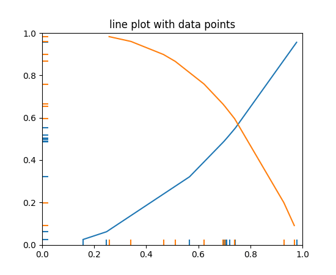

**`add_callback(self, func)`**

Add a callback function that will be called whenever one of the `Artist`'s properties changes.

Parameters:

**`func : callable`**

The callback function. It must have the signature:

```
def func(artist: Artist) -> Any
```

where *artist* is the calling `Artist`. Return values may exist but are ignored.

Returns:

**`oid : int`**

The observer id associated with the callback. This id can be used for removing the callback with `remove_callback` later.

See also

**`remove_callback`**

**`add_checker(self, checker)`**

Add an entry to a dictionary of boolean flags that are set to True when the mappable is changed.

**`add_positions(self, position)` [[source]](https://matplotlib.org/3.1.1/_modules/matplotlib/collections.html#EventCollection.add_positions)**

add one or more events at the specified positions

**`aname`**

**`append_positions(self, position)`**

add one or more events at the specified positions

**`autoscale(self)`**

Autoscale the scalar limits on the norm instance using the current array

**`autoscale_None(self)`**

Autoscale the scalar limits on the norm instance using the current array, changing only limits that are None

**`axes`**

The `Axes` instance the artist resides in, or *None*.

**`changed(self)`**

Call this whenever the mappable is changed to notify all the callbackSM listeners to the 'changed' signal

**`check_update(self, checker)`**

If mappable has changed since the last check, return True; else return False

**`contains(self, mouseevent)`**

Test whether the mouse event occurred in the collection.

Returns `bool, dict(ind=itemlist)`, where every item in itemlist contains the event.

**`convert_xunits(self, x)`**

Convert *x* using the unit type of the xaxis.

If the artist is not in contained in an Axes or if the xaxis does not have units, *x* itself is returned.

**`convert_yunits(self, y)`**

Convert *y* using the unit type of the yaxis.

If the artist is not in contained in an Axes or if the yaxis does not have units, *y* itself is returned.

**`draw(self, renderer)`**

Draw the Artist using the given renderer.

This method will be overridden in the Artist subclasses. Typically, it is implemented to not have any effect if the Artist is not visible (`Artist.get_visible` is *False*).

| Parameters: | **`renderer : RendererBase subclass.`** |
| --- | --- |

**`extend_positions(self, position)`**

add one or more events at the specified positions

**`findobj(self, match=None, include_self=True)`**

Find artist objects.

Recursively find all `Artist` instances contained in the artist.

Parameters:

**match**

A filter criterion for the matches. This can be

- *None*: Return all objects contained in artist.
- A function with signature `def match(artist: Artist) -> bool`. The result will only contain artists for which the function returns *True*.
- A class instance: e.g., `Line2D`. The result will only contain artists of this class or its subclasses (`isinstance` check).

**`include_self : bool`**

Include *self* in the list to be checked for a match.

Returns:

**`artists : list of Artist`**

**`format_cursor_data(self, data)`**

Return a string representation of *data*.

Note

This method is intended to be overridden by artist subclasses. As an end-user of Matplotlib you will most likely not call this method yourself.

The default implementation converts ints and floats and arrays of ints and floats into a comma-separated string enclosed in square brackets.

See also

**`get_cursor_data`**

**`get_agg_filter(self)`**

Return filter function to be used for agg filter.

**`get_alpha(self)`**

Return the alpha value used for blending - not supported on all backends

**`get_animated(self)`**

Return the animated state.

**`get_array(self)`**

Return the array

**`get_capstyle(self)`**

**`get_children(self)`**

Return a list of the child `Artist`s of this `Artist`.

**`get_clim(self)`**

return the min, max of the color limits for image scaling

**`get_clip_box(self)`**

Return the clipbox.

**`get_clip_on(self)`**

Return whether the artist uses clipping.

**`get_clip_path(self)`**

Return the clip path.

**`get_cmap(self)`**

return the colormap

**`get_color(self)` [[source]](https://matplotlib.org/3.1.1/_modules/matplotlib/collections.html#EventCollection.get_color)**

get the color of the lines used to mark each event

**`get_colors(self)`**

**`get_contains(self)`**

Return the custom contains function of the artist if set, or *None*.

See also

**`set_contains`**

**`get_cursor_data(self, event)`**

Return the cursor data for a given event.

Note

This method is intended to be overridden by artist subclasses. As an end-user of Matplotlib you will most likely not call this method yourself.

Cursor data can be used by Artists to provide additional context information for a given event. The default implementation just returns *None*.

Subclasses can override the method and return arbitrary data. However, when doing so, they must ensure that `format_cursor_data` can convert the data to a string representation.

The only current use case is displaying the z-value of an `AxesImage` in the status bar of a plot window, while moving the mouse.

| Parameters: | **`event : matplotlib.backend_bases.MouseEvent`** |
| --- | --- |

See also

**`format_cursor_data`**

**`get_dashes(self)`**

Alias for `get_linestyle`.

**`get_datalim(self, transData)`**

**`get_ec(self)`**

Alias for `get_edgecolor`.

**`get_edgecolor(self)`**

**`get_edgecolors(self)`**

Alias for `get_edgecolor`.

**`get_facecolor(self)`**

**`get_facecolors(self)`**

Alias for `get_facecolor`.

**`get_fc(self)`**

Alias for `get_facecolor`.

**`get_figure(self)`**

Return the `Figure` instance the artist belongs to.

**`get_fill(self)`**

return whether fill is set

**`get_gid(self)`**

Return the group id.

**`get_hatch(self)`**

Return the current hatching pattern.

**`get_in_layout(self)`**

Return boolean flag, `True` if artist is included in layout calculations.

E.g. [Constrained Layout Guide](https://matplotlib.org/3.1.1/tutorials/intermediate/constrainedlayout_guide.html), `Figure.tight_layout()`, and `fig.savefig(fname, bbox_inches='tight')`.

**`get_joinstyle(self)`**

**`get_label(self)`**

Return the label used for this artist in the legend.

**`get_linelength(self)` [[source]](https://matplotlib.org/3.1.1/_modules/matplotlib/collections.html#EventCollection.get_linelength)**

get the length of the lines used to mark each event

**`get_lineoffset(self)` [[source]](https://matplotlib.org/3.1.1/_modules/matplotlib/collections.html#EventCollection.get_lineoffset)**

get the offset of the lines used to mark each event

**`get_linestyle(self)`**

**`get_linestyles(self)`**

Alias for `get_linestyle`.

**`get_linewidth(self)` [[source]](https://matplotlib.org/3.1.1/_modules/matplotlib/collections.html#EventCollection.get_linewidth)**

Get the width of the lines used to mark each event.

**`get_linewidths(self)` [[source]](https://matplotlib.org/3.1.1/_modules/matplotlib/collections.html#EventCollection.get_linewidths)**

Alias for `get_linewidth`.

**`get_ls(self)`**

Alias for `get_linestyle`.

**`get_lw(self)`**

Alias for `get_linewidth`.

**`get_offset_position(self)`**

Returns how offsets are applied for the collection. If *offset_position* is 'screen', the offset is applied after the master transform has been applied, that is, the offsets are in screen coordinates. If offset_position is 'data', the offset is applied before the master transform, i.e., the offsets are in data coordinates.

**`get_offset_transform(self)`**

**`get_offsets(self)`**

Return the offsets for the collection.

**`get_orientation(self)` [[source]](https://matplotlib.org/3.1.1/_modules/matplotlib/collections.html#EventCollection.get_orientation)**

get the orientation of the event line, may be: [ 'horizontal' | 'vertical' ]

**`get_path_effects(self)`**

**`get_paths(self)`**

**`get_picker(self)`**

Return the picking behavior of the artist.

The possible values are described in `set_picker`.

See also

**`set_picker, pickable,` `pick`**

**`get_pickradius(self)`**

**`get_positions(self)` [[source]](https://matplotlib.org/3.1.1/_modules/matplotlib/collections.html#EventCollection.get_positions)**

return an array containing the floating-point values of the positions

**`get_rasterized(self)`**

Return whether the artist is to be rasterized.

**`get_segments(self)`**

| Returns: | **`segments : list`** List of segments in the LineCollection. Each list item contains an array of vertices. |
| --- | --- |

**`get_sketch_params(self)`**

Returns the sketch parameters for the artist.

Returns:

**`sketch_params : tuple or None`**

A 3-tuple with the following elements:

- *scale*: The amplitude of the wiggle perpendicular to the source line.
- *length*: The length of the wiggle along the line.
- *randomness*: The scale factor by which the length is shrunken or expanded.

Returns *None* if no sketch parameters were set.

**`get_snap(self)`**

Returns the snap setting.

See `set_snap` for details.

**`get_tightbbox(self, renderer)`**

Like `Artist.get_window_extent`, but includes any clipping.

| Parameters: | **`renderer : RendererBase instance`** renderer that will be used to draw the figures (i.e. `fig.canvas.get_renderer()`) |
| --- | --- |
| Returns: | **`bbox : BBox`** The enclosing bounding box (in figure pixel co-ordinates). |

**`get_transform(self)`**

Return the `Transform` instance used by this artist.

**`get_transformed_clip_path_and_affine(self)`**

Return the clip path with the non-affine part of its transformation applied, and the remaining affine part of its transformation.

**`get_transforms(self)`**

**`get_url(self)`**

Return the url.

**`get_urls(self)`**

**`get_visible(self)`**

Return the visibility.

**`get_window_extent(self, renderer)`**

Get the axes bounding box in display space.

The bounding box' width and height are nonnegative.

Subclasses should override for inclusion in the bounding box "tight" calculation. Default is to return an empty bounding box at 0, 0.

Be careful when using this function, the results will not update if the artist window extent of the artist changes. The extent can change due to any changes in the transform stack, such as changing the axes limits, the figure size, or the canvas used (as is done when saving a figure). This can lead to unexpected behavior where interactive figures will look fine on the screen, but will save incorrectly.

**`get_zorder(self)`**

Return the artist's zorder.

**`have_units(self)`**

Return *True* if units are set on the *x* or *y* axes.

**`is_horizontal(self)` [[source]](https://matplotlib.org/3.1.1/_modules/matplotlib/collections.html#EventCollection.is_horizontal)**

True if the eventcollection is horizontal, False if vertical

**`is_transform_set(self)`**

Return whether the Artist has an explicitly set transform.

This is *True* after `set_transform` has been called.

**`mouseover`**

**`pchanged(self)`**

Call all of the registered callbacks.

This function is triggered internally when a property is changed.

See also

**`add_callback`**

**`remove_callback`**

**`pick(self, mouseevent)`**

Process a pick event.

Each child artist will fire a pick event if *mouseevent* is over the artist and the artist has picker set.

See also

**`set_picker, get_picker,` `pickable`**

**`pickable(self)`**

Return whether the artist is pickable.

See also

**`set_picker, get_picker,` `pick`**

**`properties(self)`**

Return a dictionary of all the properties of the artist.

**`remove(self)`**

Remove the artist from the figure if possible.

The effect will not be visible until the figure is redrawn, e.g., with `FigureCanvasBase.draw_idle`. Call `relim` to update the axes limits if desired.

Note: `relim` will not see collections even if the collection was added to the axes with *autolim* = True.

Note: there is no support for removing the artist's legend entry.

**`remove_callback(self, oid)`**

Remove a callback based on its observer id.

See also

**`add_callback`**

**`set(self, **kwargs)`**

A property batch setter. Pass *kwargs* to set properties.

**`set_aa(self, aa)`**

Alias for `set_antialiased`.

**`set_agg_filter(self, filter_func)`**

Set the agg filter.

| Parameters: | **`filter_func : callable`** A filter function, which takes a (m, n, 3) float array and a dpi value, and returns a (m, n, 3) array. |
| --- | --- |

**`set_alpha(self, alpha)`**

Set the alpha transparencies of the collection.

| Parameters: | **`alpha : float or None`** |
| --- | --- |

**`set_animated(self, b)`**

Set the artist's animation state.

| Parameters: | **`b : bool`** |
| --- | --- |

**`set_antialiased(self, aa)`**

Set the antialiasing state for rendering.

| Parameters: | **`aa : bool or sequence of bools`** |
| --- | --- |

**`set_antialiaseds(self, aa)`**

Alias for `set_antialiased`.

**`set_array(self, A)`**

Set the image array from numpy array *A*.

| Parameters: | **`A : ndarray`** |
| --- | --- |

**`set_capstyle(self, cs)`**

Set the capstyle for the collection (for all its elements).

| Parameters: | **`cs : {'butt', 'round', 'projecting'}`** The capstyle |
| --- | --- |

**`set_clim(self, vmin=None, vmax=None)`**

set the norm limits for image scaling; if *vmin* is a length2 sequence, interpret it as `(vmin, vmax)` which is used to support setp

ACCEPTS: a length 2 sequence of floats; may be overridden in methods that have `vmin` and `vmax` kwargs.

**`set_clip_box(self, clipbox)`**

Set the artist's clip `Bbox`.

| Parameters: | **`clipbox : Bbox`** |
| --- | --- |

**`set_clip_on(self, b)`**

Set whether the artist uses clipping.

When False artists will be visible out side of the axes which can lead to unexpected results.

| Parameters: | **`b : bool`** |
| --- | --- |

**`set_clip_path(self, path, transform=None)`**

Set the artist's clip path, which may be:

- a `Patch` (or subclass) instance; or
- a `Path` instance, in which case a `Transform` instance, which will be applied to the path before using it for clipping, must be provided; or
- `None`, to remove a previously set clipping path.

For efficiency, if the path happens to be an axis-aligned rectangle, this method will set the clipping box to the corresponding rectangle and set the clipping path to `None`.

ACCEPTS: [(`Path`, `Transform`) | `Patch` | None]

**`set_cmap(self, cmap)`**

set the colormap for luminance data

| Parameters: | **`cmap : colormap or registered colormap name`** |
| --- | --- |

**`set_color(self, c)`**

Set the color(s) of the LineCollection.

| Parameters: | **`c : color or list of colors`** Matplotlib color argument (all patches have same color), or a sequence or rgba tuples; if it is a sequence the patches will cycle through the sequence. |
| --- | --- |

**`set_contains(self, picker)`**

Define a custom contains test for the artist.

The provided callable replaces the default `contains` method of the artist.

Parameters:

**`picker : callable`**

A custom picker function to evaluate if an event is within the artist. The function must have the signature:

```
def contains(artist: Artist, event: MouseEvent) -> bool, dict
```

that returns:

- a bool indicating if the event is within the artist
- a dict of additional information. The dict should at least return the same information as the default `contains()` implementation of the respective artist, but may provide additional information.

**`set_dashes(self, ls)`**

Alias for `set_linestyle`.

**`set_ec(self, c)`**

Alias for `set_edgecolor`.

**`set_edgecolor(self, c)`**

Set the edgecolor(s) of the collection.

| Parameters: | **`c : color or sequence of colors or 'face'`** The collection edgecolor(s). If a sequence, the patches cycle through it. If 'face', match the facecolor. |
| --- | --- |

**`set_edgecolors(self, c)`**

Alias for `set_edgecolor`.

**`set_facecolor(self, c)`**

Set the facecolor(s) of the collection. *c* can be a matplotlib color spec (all patches have same color), or a sequence of specs; if it is a sequence the patches will cycle through the sequence.

If *c* is 'none', the patch will not be filled.

| Parameters: | **`c : color or sequence of colors`** |
| --- | --- |

**`set_facecolors(self, c)`**

Alias for `set_facecolor`.

**`set_fc(self, c)`**

Alias for `set_facecolor`.

**`set_figure(self, fig)`**

Set the `Figure` instance the artist belongs to.

| Parameters: | **`fig : Figure`** |
| --- | --- |

**`set_gid(self, gid)`**

Set the (group) id for the artist.

| Parameters: | **`gid : str`** |
| --- | --- |

**`set_hatch(self, hatch)`**

Set the hatching pattern

*hatch* can be one of:

```
/   - diagonal hatching
\   - back diagonal
|   - vertical
-   - horizontal
+   - crossed
x   - crossed diagonal
o   - small circle
O   - large circle
.   - dots
*   - stars
```

Letters can be combined, in which case all the specified hatchings are done. If same letter repeats, it increases the density of hatching of that pattern.

Hatching is supported in the PostScript, PDF, SVG and Agg backends only.

Unlike other properties such as linewidth and colors, hatching can only be specified for the collection as a whole, not separately for each member.

| Parameters: | **`hatch : {'/', '\\', '\|', '-', '+', 'x', 'o', 'O', '.', '*'}`** |
| --- | --- |

**`set_in_layout(self, in_layout)`**

Set if artist is to be included in layout calculations, E.g. [Constrained Layout Guide](https://matplotlib.org/3.1.1/tutorials/intermediate/constrainedlayout_guide.html), `Figure.tight_layout()`, and `fig.savefig(fname, bbox_inches='tight')`.

| Parameters: | **`in_layout : bool`** |
| --- | --- |

**`set_joinstyle(self, js)`**

Set the joinstyle for the collection (for all its elements).

| Parameters: | **`js : {'miter', 'round', 'bevel'}`** The joinstyle |
| --- | --- |

**`set_label(self, s)`**

Set a label that will be displayed in the legend.

| Parameters: | **`s : object`** *s* will be converted to a string by calling [`str`](https://docs.python.org/3/library/stdtypes.html#str). |
| --- | --- |

**`set_linelength(self, linelength)` [[source]](https://matplotlib.org/3.1.1/_modules/matplotlib/collections.html#EventCollection.set_linelength)**

set the length of the lines used to mark each event

**`set_lineoffset(self, lineoffset)` [[source]](https://matplotlib.org/3.1.1/_modules/matplotlib/collections.html#EventCollection.set_lineoffset)**

set the offset of the lines used to mark each event

**`set_linestyle(self, ls)`**

Set the linestyle(s) for the collection.

| linestyle | description |
| --- | --- |
| `'-'` or `'solid'` | solid line |
| `'--'` or `'dashed'` | dashed line |
| `'-.'` or `'dashdot'` | dash-dotted line |
| `':'` or `'dotted'` | dotted line |

Alternatively a dash tuple of the following form can be provided:

```
(offset, onoffseq),
```

where `onoffseq` is an even length tuple of on and off ink in points.

| Parameters: | **`ls : {'-', '--', '-.', ':', '', (offset, on-off-seq), ...}`** The line style. |
| --- | --- |

**`set_linestyles(self, ls)`**

Alias for `set_linestyle`.

**`set_linewidth(self, lw)`**

Set the linewidth(s) for the collection. *lw* can be a scalar or a sequence; if it is a sequence the patches will cycle through the sequence

| Parameters: | **`lw : float or sequence of floats`** |
| --- | --- |

**`set_linewidths(self, lw)`**

Alias for `set_linewidth`.

**`set_ls(self, ls)`**

Alias for `set_linestyle`.

**`set_lw(self, lw)`**

Alias for `set_linewidth`.

**`set_norm(self, norm)`**

Set the normalization instance.

| Parameters: | **`norm : Normalize`** |
| --- | --- |

#### Notes

If there are any colorbars using the mappable for this norm, setting the norm of the mappable will reset the norm, locator, and formatters on the colorbar to default.

**`set_offset_position(self, offset_position)`**

Set how offsets are applied. If *offset_position* is 'screen' (default) the offset is applied after the master transform has been applied, that is, the offsets are in screen coordinates. If offset_position is 'data', the offset is applied before the master transform, i.e., the offsets are in data coordinates.

| Parameters: | **`offset_position : {'screen', 'data'}`** |
| --- | --- |

**`set_offsets(self, offsets)`**

Set the offsets for the collection.

| Parameters: | **`offsets : float or sequence of floats`** |
| --- | --- |

**`set_orientation(self, orientation=None)` [[source]](https://matplotlib.org/3.1.1/_modules/matplotlib/collections.html#EventCollection.set_orientation)**

set the orientation of the event line [ 'horizontal' | 'vertical' | None ] defaults to 'horizontal' if not specified or None

**`set_path_effects(self, path_effects)`**

Set the path effects.

| Parameters: | **`path_effects : AbstractPathEffect`** |
| --- | --- |

**`set_paths(self, segments)`**

**`set_picker(self, picker)`**

Define the picking behavior of the artist.

Parameters:

**`picker : None or bool or float or callable`**

This can be one of the following:

- *None*: Picking is disabled for this artist (default).
- A boolean: If *True* then picking will be enabled and the artist will fire a pick event if the mouse event is over the artist.
- A float: If picker is a number it is interpreted as an epsilon tolerance in points and the artist will fire off an event if it's data is within epsilon of the mouse event. For some artists like lines and patch collections, the artist may provide additional data to the pick event that is generated, e.g., the indices of the data within epsilon of the pick event
- A function: If picker is callable, it is a user supplied function which determines whether the artist is hit by the mouse event:

  ```
  hit, props = picker(artist, mouseevent)
  ```

  to determine the hit test. if the mouse event is over the artist, return *hit=True* and props is a dictionary of properties you want added to the PickEvent attributes.

**`set_pickradius(self, pr)`**

Set the pick radius used for containment tests.

| Parameters: | **`d : float`** Pick radius, in points. |
| --- | --- |

**`set_positions(self, positions)` [[source]](https://matplotlib.org/3.1.1/_modules/matplotlib/collections.html#EventCollection.set_positions)**

set the positions of the events to the specified value

**`set_rasterized(self, rasterized)`**

Force rasterized (bitmap) drawing in vector backend output.

Defaults to None, which implies the backend's default behavior.

| Parameters: | **`rasterized : bool or None`** |
| --- | --- |

**`set_segments(self, segments)`**

**`set_sketch_params(self, scale=None, length=None, randomness=None)`**

Sets the sketch parameters.

[output not shown]

**`set_snap(self, snap)`**

Set the snapping behavior.

Snapping aligns positions with the pixel grid, which results in clearer images. For example, if a black line of 1px width was defined at a position in between two pixels, the resulting image would contain the interpolated value of that line in the pixel grid, which would be a grey value on both adjacent pixel positions. In contrast, snapping will move the line to the nearest integer pixel value, so that the resulting image will really contain a 1px wide black line.

Snapping is currently only supported by the Agg and MacOSX backends.

Parameters:

**`snap : bool or None`**

Possible values:

- *True*: Snap vertices to the nearest pixel center.
- *False*: Do not modify vertex positions.
- *None*: (auto) If the path contains only rectilinear line segments, round to the nearest pixel center.

**`set_transform(self, t)`**

Set the artist transform.

| Parameters: | **`t : Transform`** |
| --- | --- |

**`set_url(self, url)`**

Set the url for the artist.

| Parameters: | **`url : str`** |
| --- | --- |

**`set_urls(self, urls)`**

| Parameters: | **`urls : List[str] or None`** |
| --- | --- |

**`set_verts(self, segments)`**

**`set_visible(self, b)`**

Set the artist's visibility.

| Parameters: | **`b : bool`** |
| --- | --- |

**`set_zorder(self, level)`**

Set the zorder for the artist. Artists with lower zorder values are drawn first.

| Parameters: | **`level : float`** |
| --- | --- |

**`stale`**

Whether the artist is 'stale' and needs to be re-drawn for the output to match the internal state of the artist.

**`sticky_edges`**

`x` and `y` sticky edge lists for autoscaling.

When performing autoscaling, if a data limit coincides with a value in the corresponding sticky_edges list, then no margin will be added--the view limit "sticks" to the edge. A typical use case is histograms, where one usually expects no margin on the bottom edge (0) of the histogram.

This attribute cannot be assigned to; however, the `x` and `y` lists can be modified in place as needed.

#### Examples

```
>>> artist.sticky_edges.x[:] = (xmin, xmax)
>>> artist.sticky_edges.y[:] = (ymin, ymax)
```

**`switch_orientation(self)` [[source]](https://matplotlib.org/3.1.1/_modules/matplotlib/collections.html#EventCollection.switch_orientation)**

switch the orientation of the event line, either from vertical to horizontal or vice versus

**`to_rgba(self, x, alpha=None, bytes=False, norm=True)`**

Return a normalized rgba array corresponding to *x*.

In the normal case, *x* is a 1-D or 2-D sequence of scalars, and the corresponding ndarray of rgba values will be returned, based on the norm and colormap set for this ScalarMappable.

There is one special case, for handling images that are already rgb or rgba, such as might have been read from an image file. If *x* is an ndarray with 3 dimensions, and the last dimension is either 3 or 4, then it will be treated as an rgb or rgba array, and no mapping will be done. The array can be uint8, or it can be floating point with values in the 0-1 range; otherwise a ValueError will be raised. If it is a masked array, the mask will be ignored. If the last dimension is 3, the *alpha* kwarg (defaulting to 1) will be used to fill in the transparency. If the last dimension is 4, the *alpha* kwarg is ignored; it does not replace the pre-existing alpha. A ValueError will be raised if the third dimension is other than 3 or 4.

In either case, if *bytes* is *False* (default), the rgba array will be floats in the 0-1 range; if it is *True*, the returned rgba array will be uint8 in the 0 to 255 range.

If norm is False, no normalization of the input data is performed, and it is assumed to be in the range (0-1).

**`update(self, props)`**

Update this artist's properties from the dictionary *props*.

**`update_from(self, other)`**

copy properties from other to self

**`update_scalarmappable(self)`**

Update colors from the scalar mappable array, if it is not None.

**`zorder = 0`**

**`class matplotlib.collections.LineCollection(segments, linewidths=None, colors=None, antialiaseds=None, linestyles='solid', offsets=None, transOffset=None, norm=None, cmap=None, pickradius=5, zorder=2, facecolors='none', **kwargs)` [[source]](https://matplotlib.org/3.1.1/_modules/matplotlib/collections.html#LineCollection)**

Bases: `matplotlib.collections.Collection`

All parameters must be sequences or scalars; if scalars, they will be converted to sequences. The property of the ith line segment is:

```
prop[i % len(props)]
```

i.e., the properties cycle if the `len` of props is less than the number of segments.

Parameters:

**segments**

A sequence of (*line0*, *line1*, *line2*), where:

```
linen = (x0, y0), (x1, y1), ... (xm, ym)
```

or the equivalent numpy array with two columns. Each line can be a different length.

**`colors : sequence, optional`**

A sequence of RGBA tuples (e.g., arbitrary color strings, etc, not allowed).

**`antialiaseds : sequence, optional`**

A sequence of ones or zeros.

**`linestyles : string, tuple, optional`**

Either one of [ 'solid' | 'dashed' | 'dashdot' | 'dotted' ], or a dash tuple. The dash tuple is:

```
(offset, onoffseq)
```

where `onoffseq` is an even length tuple of on and off ink in points.

**`norm : Normalize, optional`**

`Normalize` instance.

**`cmap : string or Colormap, optional`**

Colormap name or `Colormap` instance.

**`pickradius : float, optional`**

The tolerance in points for mouse clicks picking a line. Default is 5 pt.

**`zorder : int, optional`**

zorder of the LineCollection. Default is 2.

**`facecolors : optional`**

The facecolors of the LineCollection. Default is 'none'. Setting to a value other than 'none' will lead to a filled polygon being drawn between points on each line.

#### Notes

If *linewidths*, *colors*, or *antialiaseds* is None, they default to their rcParams setting, in sequence form.

If *offsets* and *transOffset* are not None, then *offsets* are transformed by *transOffset* and applied after the segments have been transformed to display coordinates.

If *offsets* is not None but *transOffset* is None, then the *offsets* are added to the segments before any transformation. In this case, a single offset can be specified as:

```
offsets=(xo,yo)
```

and this value will be added cumulatively to each successive segment, so as to produce a set of successively offset curves.

The use of `ScalarMappable` is optional. If the `ScalarMappable` array `_A` is not None (i.e., a call to `set_array()` has been made), at draw time a call to scalar mappable will be made to set the colors.

**`add_callback(self, func)`**

Add a callback function that will be called whenever one of the `Artist`'s properties changes.

Parameters:

**`func : callable`**

The callback function. It must have the signature:

```
def func(artist: Artist) -> Any
```

where *artist* is the calling `Artist`. Return values may exist but are ignored.

Returns:

**`oid : int`**

The observer id associated with the callback. This id can be used for removing the callback with `remove_callback` later.

See also

**`remove_callback`**

**`add_checker(self, checker)`**

Add an entry to a dictionary of boolean flags that are set to True when the mappable is changed.

**`aname`**

**`autoscale(self)`**

Autoscale the scalar limits on the norm instance using the current array

**`autoscale_None(self)`**

Autoscale the scalar limits on the norm instance using the current array, changing only limits that are None

**`axes`**

The `Axes` instance the artist resides in, or *None*.

**`changed(self)`**

Call this whenever the mappable is changed to notify all the callbackSM listeners to the 'changed' signal

**`check_update(self, checker)`**

If mappable has changed since the last check, return True; else return False

**`contains(self, mouseevent)`**

Test whether the mouse event occurred in the collection.

Returns `bool, dict(ind=itemlist)`, where every item in itemlist contains the event.

**`convert_xunits(self, x)`**

Convert *x* using the unit type of the xaxis.

If the artist is not in contained in an Axes or if the xaxis does not have units, *x* itself is returned.

**`convert_yunits(self, y)`**

Convert *y* using the unit type of the yaxis.

If the artist is not in contained in an Axes or if the yaxis does not have units, *y* itself is returned.

**`draw(self, renderer)`**

Draw the Artist using the given renderer.

This method will be overridden in the Artist subclasses. Typically, it is implemented to not have any effect if the Artist is not visible (`Artist.get_visible` is *False*).

| Parameters: | **`renderer : RendererBase subclass.`** |
| --- | --- |

**`findobj(self, match=None, include_self=True)`**

Find artist objects.

Recursively find all `Artist` instances contained in the artist.

Parameters:

**match**

A filter criterion for the matches. This can be

- *None*: Return all objects contained in artist.
- A function with signature `def match(artist: Artist) -> bool`. The result will only contain artists for which the function returns *True*.
- A class instance: e.g., `Line2D`. The result will only contain artists of this class or its subclasses (`isinstance` check).

**`include_self : bool`**

Include *self* in the list to be checked for a match.

Returns:

**`artists : list of Artist`**

**`format_cursor_data(self, data)`**

Return a string representation of *data*.

Note

This method is intended to be overridden by artist subclasses. As an end-user of Matplotlib you will most likely not call this method yourself.

The default implementation converts ints and floats and arrays of ints and floats into a comma-separated string enclosed in square brackets.

See also

**`get_cursor_data`**

**`get_agg_filter(self)`**

Return filter function to be used for agg filter.

**`get_alpha(self)`**

Return the alpha value used for blending - not supported on all backends

**`get_animated(self)`**

Return the animated state.

**`get_array(self)`**

Return the array

**`get_capstyle(self)`**

**`get_children(self)`**

Return a list of the child `Artist`s of this `Artist`.

**`get_clim(self)`**

return the min, max of the color limits for image scaling

**`get_clip_box(self)`**

Return the clipbox.

**`get_clip_on(self)`**

Return whether the artist uses clipping.

**`get_clip_path(self)`**

Return the clip path.

**`get_cmap(self)`**

return the colormap

**`get_color(self)` [[source]](https://matplotlib.org/3.1.1/_modules/matplotlib/collections.html#LineCollection.get_color)**

**`get_colors(self)`**

**`get_contains(self)`**

Return the custom contains function of the artist if set, or *None*.

See also

**`set_contains`**

**`get_cursor_data(self, event)`**

Return the cursor data for a given event.

Note

This method is intended to be overridden by artist subclasses. As an end-user of Matplotlib you will most likely not call this method yourself.

Cursor data can be used by Artists to provide additional context information for a given event. The default implementation just returns *None*.

Subclasses can override the method and return arbitrary data. However, when doing so, they must ensure that `format_cursor_data` can convert the data to a string representation.

The only current use case is displaying the z-value of an `AxesImage` in the status bar of a plot window, while moving the mouse.

| Parameters: | **`event : matplotlib.backend_bases.MouseEvent`** |
| --- | --- |

See also

**`format_cursor_data`**

**`get_dashes(self)`**

Alias for `get_linestyle`.

**`get_datalim(self, transData)`**

**`get_ec(self)`**

Alias for `get_edgecolor`.

**`get_edgecolor(self)`**

**`get_edgecolors(self)`**

Alias for `get_edgecolor`.

**`get_facecolor(self)`**

**`get_facecolors(self)`**

Alias for `get_facecolor`.

**`get_fc(self)`**

Alias for `get_facecolor`.

**`get_figure(self)`**

Return the `Figure` instance the artist belongs to.

**`get_fill(self)`**

return whether fill is set

**`get_gid(self)`**

Return the group id.

**`get_hatch(self)`**

Return the current hatching pattern.

**`get_in_layout(self)`**

Return boolean flag, `True` if artist is included in layout calculations.

E.g. [Constrained Layout Guide](https://matplotlib.org/3.1.1/tutorials/intermediate/constrainedlayout_guide.html), `Figure.tight_layout()`, and `fig.savefig(fname, bbox_inches='tight')`.

**`get_joinstyle(self)`**

**`get_label(self)`**

Return the label used for this artist in the legend.

**`get_linestyle(self)`**

**`get_linestyles(self)`**

Alias for `get_linestyle`.

**`get_linewidth(self)`**

**`get_linewidths(self)`**

Alias for `get_linewidth`.

**`get_ls(self)`**

Alias for `get_linestyle`.

**`get_lw(self)`**

Alias for `get_linewidth`.

**`get_offset_position(self)`**

Returns how offsets are applied for the collection. If *offset_position* is 'screen', the offset is applied after the master transform has been applied, that is, the offsets are in screen coordinates. If offset_position is 'data', the offset is applied before the master transform, i.e., the offsets are in data coordinates.

**`get_offset_transform(self)`**

**`get_offsets(self)`**

Return the offsets for the collection.

**`get_path_effects(self)`**

**`get_paths(self)`**

**`get_picker(self)`**

Return the picking behavior of the artist.

The possible values are described in `set_picker`.

See also

**`set_picker, pickable,` `pick`**

**`get_pickradius(self)`**

**`get_rasterized(self)`**

Return whether the artist is to be rasterized.

**`get_segments(self)` [[source]](https://matplotlib.org/3.1.1/_modules/matplotlib/collections.html#LineCollection.get_segments)**

| Returns: | **`segments : list`** List of segments in the LineCollection. Each list item contains an array of vertices. |
| --- | --- |

**`get_sketch_params(self)`**

Returns the sketch parameters for the artist.

Returns:

**`sketch_params : tuple or None`**

A 3-tuple with the following elements:

- *scale*: The amplitude of the wiggle perpendicular to the source line.
- *length*: The length of the wiggle along the line.
- *randomness*: The scale factor by which the length is shrunken or expanded.

Returns *None* if no sketch parameters were set.

**`get_snap(self)`**

Returns the snap setting.

See `set_snap` for details.

**`get_tightbbox(self, renderer)`**

Like `Artist.get_window_extent`, but includes any clipping.

| Parameters: | **`renderer : RendererBase instance`** renderer that will be used to draw the figures (i.e. `fig.canvas.get_renderer()`) |
| --- | --- |
| Returns: | **`bbox : BBox`** The enclosing bounding box (in figure pixel co-ordinates). |

**`get_transform(self)`**

Return the `Transform` instance used by this artist.

**`get_transformed_clip_path_and_affine(self)`**

Return the clip path with the non-affine part of its transformation applied, and the remaining affine part of its transformation.

**`get_transforms(self)`**

**`get_url(self)`**

Return the url.

**`get_urls(self)`**

**`get_visible(self)`**

Return the visibility.

**`get_window_extent(self, renderer)`**

Get the axes bounding box in display space.

The bounding box' width and height are nonnegative.

Subclasses should override for inclusion in the bounding box "tight" calculation. Default is to return an empty bounding box at 0, 0.

Be careful when using this function, the results will not update if the artist window extent of the artist changes. The extent can change due to any changes in the transform stack, such as changing the axes limits, the figure size, or the canvas used (as is done when saving a figure). This can lead to unexpected behavior where interactive figures will look fine on the screen, but will save incorrectly.

**`get_zorder(self)`**

Return the artist's zorder.

**`have_units(self)`**

Return *True* if units are set on the *x* or *y* axes.

**`is_transform_set(self)`**

Return whether the Artist has an explicitly set transform.

This is *True* after `set_transform` has been called.

**`mouseover`**

**`pchanged(self)`**

Call all of the registered callbacks.

This function is triggered internally when a property is changed.

See also

**`add_callback`**

**`remove_callback`**

**`pick(self, mouseevent)`**

Process a pick event.

Each child artist will fire a pick event if *mouseevent* is over the artist and the artist has picker set.

See also

**`set_picker, get_picker,` `pickable`**

**`pickable(self)`**

Return whether the artist is pickable.

See also

**`set_picker, get_picker,` `pick`**

**`properties(self)`**

Return a dictionary of all the properties of the artist.

**`remove(self)`**

Remove the artist from the figure if possible.

The effect will not be visible until the figure is redrawn, e.g., with `FigureCanvasBase.draw_idle`. Call `relim` to update the axes limits if desired.

Note: `relim` will not see collections even if the collection was added to the axes with *autolim* = True.

Note: there is no support for removing the artist's legend entry.

**`remove_callback(self, oid)`**

Remove a callback based on its observer id.

See also

**`add_callback`**

**`set(self, **kwargs)`**

A property batch setter. Pass *kwargs* to set properties.

**`set_aa(self, aa)`**

Alias for `set_antialiased`.

**`set_agg_filter(self, filter_func)`**

Set the agg filter.

| Parameters: | **`filter_func : callable`** A filter function, which takes a (m, n, 3) float array and a dpi value, and returns a (m, n, 3) array. |
| --- | --- |

**`set_alpha(self, alpha)`**

Set the alpha transparencies of the collection.

| Parameters: | **`alpha : float or None`** |
| --- | --- |

**`set_animated(self, b)`**

Set the artist's animation state.

| Parameters: | **`b : bool`** |
| --- | --- |

**`set_antialiased(self, aa)`**

Set the antialiasing state for rendering.

| Parameters: | **`aa : bool or sequence of bools`** |
| --- | --- |

**`set_antialiaseds(self, aa)`**

Alias for `set_antialiased`.

**`set_array(self, A)`**

Set the image array from numpy array *A*.

| Parameters: | **`A : ndarray`** |
| --- | --- |

**`set_capstyle(self, cs)`**

Set the capstyle for the collection (for all its elements).

| Parameters: | **`cs : {'butt', 'round', 'projecting'}`** The capstyle |
| --- | --- |

**`set_clim(self, vmin=None, vmax=None)`**

set the norm limits for image scaling; if *vmin* is a length2 sequence, interpret it as `(vmin, vmax)` which is used to support setp

ACCEPTS: a length 2 sequence of floats; may be overridden in methods that have `vmin` and `vmax` kwargs.

**`set_clip_box(self, clipbox)`**

Set the artist's clip `Bbox`.

| Parameters: | **`clipbox : Bbox`** |
| --- | --- |

**`set_clip_on(self, b)`**

Set whether the artist uses clipping.

When False artists will be visible out side of the axes which can lead to unexpected results.

| Parameters: | **`b : bool`** |
| --- | --- |

**`set_clip_path(self, path, transform=None)`**

Set the artist's clip path, which may be:

- a `Patch` (or subclass) instance; or
- a `Path` instance, in which case a `Transform` instance, which will be applied to the path before using it for clipping, must be provided; or
- `None`, to remove a previously set clipping path.

For efficiency, if the path happens to be an axis-aligned rectangle, this method will set the clipping box to the corresponding rectangle and set the clipping path to `None`.

ACCEPTS: [(`Path`, `Transform`) | `Patch` | None]

**`set_cmap(self, cmap)`**

set the colormap for luminance data

| Parameters: | **`cmap : colormap or registered colormap name`** |
| --- | --- |

**`set_color(self, c)` [[source]](https://matplotlib.org/3.1.1/_modules/matplotlib/collections.html#LineCollection.set_color)**

Set the color(s) of the LineCollection.

| Parameters: | **`c : color or list of colors`** Matplotlib color argument (all patches have same color), or a sequence or rgba tuples; if it is a sequence the patches will cycle through the sequence. |
| --- | --- |

**`set_contains(self, picker)`**

Define a custom contains test for the artist.

The provided callable replaces the default `contains` method of the artist.

Parameters:

**`picker : callable`**

A custom picker function to evaluate if an event is within the artist. The function must have the signature:

```
def contains(artist: Artist, event: MouseEvent) -> bool, dict
```

that returns:

- a bool indicating if the event is within the artist
- a dict of additional information. The dict should at least return the same information as the default `contains()` implementation of the respective artist, but may provide additional information.

**`set_dashes(self, ls)`**

Alias for `set_linestyle`.

**`set_ec(self, c)`**

Alias for `set_edgecolor`.

**`set_edgecolor(self, c)`**

Set the edgecolor(s) of the collection.

| Parameters: | **`c : color or sequence of colors or 'face'`** The collection edgecolor(s). If a sequence, the patches cycle through it. If 'face', match the facecolor. |
| --- | --- |

**`set_edgecolors(self, c)`**

Alias for `set_edgecolor`.

**`set_facecolor(self, c)`**

Set the facecolor(s) of the collection. *c* can be a matplotlib color spec (all patches have same color), or a sequence of specs; if it is a sequence the patches will cycle through the sequence.

If *c* is 'none', the patch will not be filled.

| Parameters: | **`c : color or sequence of colors`** |
| --- | --- |

**`set_facecolors(self, c)`**

Alias for `set_facecolor`.

**`set_fc(self, c)`**

Alias for `set_facecolor`.

**`set_figure(self, fig)`**

Set the `Figure` instance the artist belongs to.

| Parameters: | **`fig : Figure`** |
| --- | --- |

**`set_gid(self, gid)`**

Set the (group) id for the artist.

| Parameters: | **`gid : str`** |
| --- | --- |

**`set_hatch(self, hatch)`**

Set the hatching pattern

*hatch* can be one of:

```
/   - diagonal hatching
\   - back diagonal
|   - vertical
-   - horizontal
+   - crossed
x   - crossed diagonal
o   - small circle
O   - large circle
.   - dots
*   - stars
```

Letters can be combined, in which case all the specified hatchings are done. If same letter repeats, it increases the density of hatching of that pattern.

Hatching is supported in the PostScript, PDF, SVG and Agg backends only.

Unlike other properties such as linewidth and colors, hatching can only be specified for the collection as a whole, not separately for each member.

| Parameters: | **`hatch : {'/', '\\', '\|', '-', '+', 'x', 'o', 'O', '.', '*'}`** |
| --- | --- |

**`set_in_layout(self, in_layout)`**

Set if artist is to be included in layout calculations, E.g. [Constrained Layout Guide](https://matplotlib.org/3.1.1/tutorials/intermediate/constrainedlayout_guide.html), `Figure.tight_layout()`, and `fig.savefig(fname, bbox_inches='tight')`.

| Parameters: | **`in_layout : bool`** |
| --- | --- |

**`set_joinstyle(self, js)`**

Set the joinstyle for the collection (for all its elements).

| Parameters: | **`js : {'miter', 'round', 'bevel'}`** The joinstyle |
| --- | --- |

**`set_label(self, s)`**

Set a label that will be displayed in the legend.

| Parameters: | **`s : object`** *s* will be converted to a string by calling [`str`](https://docs.python.org/3/library/stdtypes.html#str). |
| --- | --- |

**`set_linestyle(self, ls)`**

Set the linestyle(s) for the collection.

| linestyle | description |
| --- | --- |
| `'-'` or `'solid'` | solid line |
| `'--'` or `'dashed'` | dashed line |
| `'-.'` or `'dashdot'` | dash-dotted line |
| `':'` or `'dotted'` | dotted line |

Alternatively a dash tuple of the following form can be provided:

```
(offset, onoffseq),
```

where `onoffseq` is an even length tuple of on and off ink in points.

| Parameters: | **`ls : {'-', '--', '-.', ':', '', (offset, on-off-seq), ...}`** The line style. |
| --- | --- |

**`set_linestyles(self, ls)`**

Alias for `set_linestyle`.

**`set_linewidth(self, lw)`**

Set the linewidth(s) for the collection. *lw* can be a scalar or a sequence; if it is a sequence the patches will cycle through the sequence

| Parameters: | **`lw : float or sequence of floats`** |
| --- | --- |

**`set_linewidths(self, lw)`**

Alias for `set_linewidth`.

**`set_ls(self, ls)`**

Alias for `set_linestyle`.

**`set_lw(self, lw)`**

Alias for `set_linewidth`.

**`set_norm(self, norm)`**

Set the normalization instance.

| Parameters: | **`norm : Normalize`** |
| --- | --- |

#### Notes

If there are any colorbars using the mappable for this norm, setting the norm of the mappable will reset the norm, locator, and formatters on the colorbar to default.

**`set_offset_position(self, offset_position)`**

Set how offsets are applied. If *offset_position* is 'screen' (default) the offset is applied after the master transform has been applied, that is, the offsets are in screen coordinates. If offset_position is 'data', the offset is applied before the master transform, i.e., the offsets are in data coordinates.

| Parameters: | **`offset_position : {'screen', 'data'}`** |
| --- | --- |

**`set_offsets(self, offsets)`**

Set the offsets for the collection.

| Parameters: | **`offsets : float or sequence of floats`** |
| --- | --- |

**`set_path_effects(self, path_effects)`**

Set the path effects.

| Parameters: | **`path_effects : AbstractPathEffect`** |
| --- | --- |

**`set_paths(self, segments)`**

**`set_picker(self, picker)`**

Define the picking behavior of the artist.

Parameters:

**`picker : None or bool or float or callable`**

This can be one of the following:

- *None*: Picking is disabled for this artist (default).
- A boolean: If *True* then picking will be enabled and the artist will fire a pick event if the mouse event is over the artist.
- A float: If picker is a number it is interpreted as an epsilon tolerance in points and the artist will fire off an event if it's data is within epsilon of the mouse event. For some artists like lines and patch collections, the artist may provide additional data to the pick event that is generated, e.g., the indices of the data within epsilon of the pick event
- A function: If picker is callable, it is a user supplied function which determines whether the artist is hit by the mouse event:

  ```
  hit, props = picker(artist, mouseevent)
  ```

  to determine the hit test. if the mouse event is over the artist, return *hit=True* and props is a dictionary of properties you want added to the PickEvent attributes.

**`set_pickradius(self, pr)`**

Set the pick radius used for containment tests.

| Parameters: | **`d : float`** Pick radius, in points. |
| --- | --- |

**`set_rasterized(self, rasterized)`**

Force rasterized (bitmap) drawing in vector backend output.

Defaults to None, which implies the backend's default behavior.

| Parameters: | **`rasterized : bool or None`** |
| --- | --- |

**`set_segments(self, segments)` [[source]](https://matplotlib.org/3.1.1/_modules/matplotlib/collections.html#LineCollection.set_segments)**

**`set_sketch_params(self, scale=None, length=None, randomness=None)`**

Sets the sketch parameters.

[output not shown]

**`set_snap(self, snap)`**

Set the snapping behavior.

Snapping aligns positions with the pixel grid, which results in clearer images. For example, if a black line of 1px width was defined at a position in between two pixels, the resulting image would contain the interpolated value of that line in the pixel grid, which would be a grey value on both adjacent pixel positions. In contrast, snapping will move the line to the nearest integer pixel value, so that the resulting image will really contain a 1px wide black line.

Snapping is currently only supported by the Agg and MacOSX backends.

Parameters:

**`snap : bool or None`**

Possible values:

- *True*: Snap vertices to the nearest pixel center.
- *False*: Do not modify vertex positions.
- *None*: (auto) If the path contains only rectilinear line segments, round to the nearest pixel center.

**`set_transform(self, t)`**

Set the artist transform.

| Parameters: | **`t : Transform`** |
| --- | --- |

**`set_url(self, url)`**

Set the url for the artist.

| Parameters: | **`url : str`** |
| --- | --- |

**`set_urls(self, urls)`**

| Parameters: | **`urls : List[str] or None`** |
| --- | --- |

**`set_verts(self, segments)`**

**`set_visible(self, b)`**

Set the artist's visibility.

| Parameters: | **`b : bool`** |
| --- | --- |

**`set_zorder(self, level)`**

Set the zorder for the artist. Artists with lower zorder values are drawn first.

| Parameters: | **`level : float`** |
| --- | --- |

**`stale`**

Whether the artist is 'stale' and needs to be re-drawn for the output to match the internal state of the artist.

**`sticky_edges`**

`x` and `y` sticky edge lists for autoscaling.

When performing autoscaling, if a data limit coincides with a value in the corresponding sticky_edges list, then no margin will be added--the view limit "sticks" to the edge. A typical use case is histograms, where one usually expects no margin on the bottom edge (0) of the histogram.

This attribute cannot be assigned to; however, the `x` and `y` lists can be modified in place as needed.

#### Examples

```
>>> artist.sticky_edges.x[:] = (xmin, xmax)
>>> artist.sticky_edges.y[:] = (ymin, ymax)
```

**`to_rgba(self, x, alpha=None, bytes=False, norm=True)`**

Return a normalized rgba array corresponding to *x*.

In the normal case, *x* is a 1-D or 2-D sequence of scalars, and the corresponding ndarray of rgba values will be returned, based on the norm and colormap set for this ScalarMappable.

There is one special case, for handling images that are already rgb or rgba, such as might have been read from an image file. If *x* is an ndarray with 3 dimensions, and the last dimension is either 3 or 4, then it will be treated as an rgb or rgba array, and no mapping will be done. The array can be uint8, or it can be floating point with values in the 0-1 range; otherwise a ValueError will be raised. If it is a masked array, the mask will be ignored. If the last dimension is 3, the *alpha* kwarg (defaulting to 1) will be used to fill in the transparency. If the last dimension is 4, the *alpha* kwarg is ignored; it does not replace the pre-existing alpha. A ValueError will be raised if the third dimension is other than 3 or 4.

In either case, if *bytes* is *False* (default), the rgba array will be floats in the 0-1 range; if it is *True*, the returned rgba array will be uint8 in the 0 to 255 range.

If norm is False, no normalization of the input data is performed, and it is assumed to be in the range (0-1).

**`update(self, props)`**

Update this artist's properties from the dictionary *props*.

**`update_from(self, other)`**

copy properties from other to self

**`update_scalarmappable(self)`**

Update colors from the scalar mappable array, if it is not None.

**`zorder = 0`**

**`class matplotlib.collections.PatchCollection(patches, match_original=False, **kwargs)` [[source]](https://matplotlib.org/3.1.1/_modules/matplotlib/collections.html#PatchCollection)**

Bases: `matplotlib.collections.Collection`

A generic collection of patches.

This makes it easier to assign a color map to a heterogeneous collection of patches.

This also may improve plotting speed, since PatchCollection will draw faster than a large number of patches.

**patches**

a sequence of Patch objects. This list may include a heterogeneous assortment of different patch types.

**match_original**

If True, use the colors and linewidths of the original patches. If False, new colors may be assigned by providing the standard collection arguments, facecolor, edgecolor, linewidths, norm or cmap.

If any of *edgecolors*, *facecolors*, *linewidths*, *antialiaseds* are None, they default to their `matplotlib.rcParams` patch setting, in sequence form.

The use of `ScalarMappable` is optional. If the `ScalarMappable` matrix _A is not None (i.e., a call to set_array has been made), at draw time a call to scalar mappable will be made to set the face colors.

**`add_callback(self, func)`**

Add a callback function that will be called whenever one of the `Artist`'s properties changes.

Parameters:

**`func : callable`**

The callback function. It must have the signature:

```
def func(artist: Artist) -> Any
```

where *artist* is the calling `Artist`. Return values may exist but are ignored.

Returns:

**`oid : int`**

The observer id associated with the callback. This id can be used for removing the callback with `remove_callback` later.

See also

**`remove_callback`**

**`add_checker(self, checker)`**

Add an entry to a dictionary of boolean flags that are set to True when the mappable is changed.

**`aname`**

**`autoscale(self)`**

Autoscale the scalar limits on the norm instance using the current array

**`autoscale_None(self)`**

Autoscale the scalar limits on the norm instance using the current array, changing only limits that are None

**`axes`**

The `Axes` instance the artist resides in, or *None*.

**`changed(self)`**

Call this whenever the mappable is changed to notify all the callbackSM listeners to the 'changed' signal

**`check_update(self, checker)`**

If mappable has changed since the last check, return True; else return False

**`contains(self, mouseevent)`**

Test whether the mouse event occurred in the collection.

Returns `bool, dict(ind=itemlist)`, where every item in itemlist contains the event.

**`convert_xunits(self, x)`**

Convert *x* using the unit type of the xaxis.

If the artist is not in contained in an Axes or if the xaxis does not have units, *x* itself is returned.

**`convert_yunits(self, y)`**

Convert *y* using the unit type of the yaxis.

If the artist is not in contained in an Axes or if the yaxis does not have units, *y* itself is returned.

**`draw(self, renderer)`**

Draw the Artist using the given renderer.

This method will be overridden in the Artist subclasses. Typically, it is implemented to not have any effect if the Artist is not visible (`Artist.get_visible` is *False*).

| Parameters: | **`renderer : RendererBase subclass.`** |
| --- | --- |

**`findobj(self, match=None, include_self=True)`**

Find artist objects.

Recursively find all `Artist` instances contained in the artist.

Parameters:

**match**

A filter criterion for the matches. This can be

- *None*: Return all objects contained in artist.
- A function with signature `def match(artist: Artist) -> bool`. The result will only contain artists for which the function returns *True*.
- A class instance: e.g., `Line2D`. The result will only contain artists of this class or its subclasses (`isinstance` check).

**`include_self : bool`**

Include *self* in the list to be checked for a match.

Returns:

**`artists : list of Artist`**

**`format_cursor_data(self, data)`**

Return a string representation of *data*.

Note

This method is intended to be overridden by artist subclasses. As an end-user of Matplotlib you will most likely not call this method yourself.

The default implementation converts ints and floats and arrays of ints and floats into a comma-separated string enclosed in square brackets.

See also

**`get_cursor_data`**

**`get_agg_filter(self)`**

Return filter function to be used for agg filter.

**`get_alpha(self)`**

Return the alpha value used for blending - not supported on all backends

**`get_animated(self)`**

Return the animated state.

**`get_array(self)`**

Return the array

**`get_capstyle(self)`**

**`get_children(self)`**

Return a list of the child `Artist`s of this `Artist`.

**`get_clim(self)`**

return the min, max of the color limits for image scaling

**`get_clip_box(self)`**

Return the clipbox.

**`get_clip_on(self)`**

Return whether the artist uses clipping.

**`get_clip_path(self)`**

Return the clip path.

**`get_cmap(self)`**

return the colormap

**`get_contains(self)`**

Return the custom contains function of the artist if set, or *None*.

See also

**`set_contains`**

**`get_cursor_data(self, event)`**

Return the cursor data for a given event.

Note

This method is intended to be overridden by artist subclasses. As an end-user of Matplotlib you will most likely not call this method yourself.

Cursor data can be used by Artists to provide additional context information for a given event. The default implementation just returns *None*.

Subclasses can override the method and return arbitrary data. However, when doing so, they must ensure that `format_cursor_data` can convert the data to a string representation.

The only current use case is displaying the z-value of an `AxesImage` in the status bar of a plot window, while moving the mouse.

| Parameters: | **`event : matplotlib.backend_bases.MouseEvent`** |
| --- | --- |

See also

**`format_cursor_data`**

**`get_dashes(self)`**

Alias for `get_linestyle`.

**`get_datalim(self, transData)`**

**`get_ec(self)`**

Alias for `get_edgecolor`.

**`get_edgecolor(self)`**

**`get_edgecolors(self)`**

Alias for `get_edgecolor`.

**`get_facecolor(self)`**

**`get_facecolors(self)`**

Alias for `get_facecolor`.

**`get_fc(self)`**

Alias for `get_facecolor`.

**`get_figure(self)`**

Return the `Figure` instance the artist belongs to.

**`get_fill(self)`**

return whether fill is set

**`get_gid(self)`**

Return the group id.

**`get_hatch(self)`**

Return the current hatching pattern.

**`get_in_layout(self)`**

Return boolean flag, `True` if artist is included in layout calculations.

E.g. [Constrained Layout Guide](https://matplotlib.org/3.1.1/tutorials/intermediate/constrainedlayout_guide.html), `Figure.tight_layout()`, and `fig.savefig(fname, bbox_inches='tight')`.

**`get_joinstyle(self)`**

**`get_label(self)`**

Return the label used for this artist in the legend.

**`get_linestyle(self)`**

**`get_linestyles(self)`**

Alias for `get_linestyle`.

**`get_linewidth(self)`**

**`get_linewidths(self)`**

Alias for `get_linewidth`.

**`get_ls(self)`**

Alias for `get_linestyle`.

**`get_lw(self)`**

Alias for `get_linewidth`.

**`get_offset_position(self)`**

Returns how offsets are applied for the collection. If *offset_position* is 'screen', the offset is applied after the master transform has been applied, that is, the offsets are in screen coordinates. If offset_position is 'data', the offset is applied before the master transform, i.e., the offsets are in data coordinates.

**`get_offset_transform(self)`**

**`get_offsets(self)`**

Return the offsets for the collection.

**`get_path_effects(self)`**

**`get_paths(self)`**

**`get_picker(self)`**

Return the picking behavior of the artist.

The possible values are described in `set_picker`.

See also

**`set_picker, pickable,` `pick`**

**`get_pickradius(self)`**

**`get_rasterized(self)`**

Return whether the artist is to be rasterized.

**`get_sketch_params(self)`**

Returns the sketch parameters for the artist.

Returns:

**`sketch_params : tuple or None`**

A 3-tuple with the following elements:

- *scale*: The amplitude of the wiggle perpendicular to the source line.
- *length*: The length of the wiggle along the line.
- *randomness*: The scale factor by which the length is shrunken or expanded.

Returns *None* if no sketch parameters were set.

**`get_snap(self)`**

Returns the snap setting.

See `set_snap` for details.

**`get_tightbbox(self, renderer)`**

Like `Artist.get_window_extent`, but includes any clipping.

| Parameters: | **`renderer : RendererBase instance`** renderer that will be used to draw the figures (i.e. `fig.canvas.get_renderer()`) |
| --- | --- |
| Returns: | **`bbox : BBox`** The enclosing bounding box (in figure pixel co-ordinates). |

**`get_transform(self)`**

Return the `Transform` instance used by this artist.

**`get_transformed_clip_path_and_affine(self)`**

Return the clip path with the non-affine part of its transformation applied, and the remaining affine part of its transformation.

**`get_transforms(self)`**

**`get_url(self)`**

Return the url.

**`get_urls(self)`**

**`get_visible(self)`**

Return the visibility.

**`get_window_extent(self, renderer)`**

Get the axes bounding box in display space.

The bounding box' width and height are nonnegative.

Subclasses should override for inclusion in the bounding box "tight" calculation. Default is to return an empty bounding box at 0, 0.

Be careful when using this function, the results will not update if the artist window extent of the artist changes. The extent can change due to any changes in the transform stack, such as changing the axes limits, the figure size, or the canvas used (as is done when saving a figure). This can lead to unexpected behavior where interactive figures will look fine on the screen, but will save incorrectly.

**`get_zorder(self)`**

Return the artist's zorder.

**`have_units(self)`**

Return *True* if units are set on the *x* or *y* axes.

**`is_transform_set(self)`**

Return whether the Artist has an explicitly set transform.

This is *True* after `set_transform` has been called.

**`mouseover`**

**`pchanged(self)`**

Call all of the registered callbacks.

This function is triggered internally when a property is changed.

See also

**`add_callback`**

**`remove_callback`**

**`pick(self, mouseevent)`**

Process a pick event.

Each child artist will fire a pick event if *mouseevent* is over the artist and the artist has picker set.

See also

**`set_picker, get_picker,` `pickable`**

**`pickable(self)`**

Return whether the artist is pickable.

See also

**`set_picker, get_picker,` `pick`**

**`properties(self)`**

Return a dictionary of all the properties of the artist.

**`remove(self)`**

Remove the artist from the figure if possible.

The effect will not be visible until the figure is redrawn, e.g., with `FigureCanvasBase.draw_idle`. Call `relim` to update the axes limits if desired.

Note: `relim` will not see collections even if the collection was added to the axes with *autolim* = True.

Note: there is no support for removing the artist's legend entry.

**`remove_callback(self, oid)`**

Remove a callback based on its observer id.

See also

**`add_callback`**

**`set(self, **kwargs)`**

A property batch setter. Pass *kwargs* to set properties.

**`set_aa(self, aa)`**

Alias for `set_antialiased`.

**`set_agg_filter(self, filter_func)`**

Set the agg filter.

| Parameters: | **`filter_func : callable`** A filter function, which takes a (m, n, 3) float array and a dpi value, and returns a (m, n, 3) array. |
| --- | --- |

**`set_alpha(self, alpha)`**

Set the alpha transparencies of the collection.

| Parameters: | **`alpha : float or None`** |
| --- | --- |

**`set_animated(self, b)`**

Set the artist's animation state.

| Parameters: | **`b : bool`** |
| --- | --- |

**`set_antialiased(self, aa)`**

Set the antialiasing state for rendering.

| Parameters: | **`aa : bool or sequence of bools`** |
| --- | --- |

**`set_antialiaseds(self, aa)`**

Alias for `set_antialiased`.

**`set_array(self, A)`**

Set the image array from numpy array *A*.

| Parameters: | **`A : ndarray`** |
| --- | --- |

**`set_capstyle(self, cs)`**

Set the capstyle for the collection (for all its elements).

| Parameters: | **`cs : {'butt', 'round', 'projecting'}`** The capstyle |
| --- | --- |

**`set_clim(self, vmin=None, vmax=None)`**

set the norm limits for image scaling; if *vmin* is a length2 sequence, interpret it as `(vmin, vmax)` which is used to support setp

ACCEPTS: a length 2 sequence of floats; may be overridden in methods that have `vmin` and `vmax` kwargs.

**`set_clip_box(self, clipbox)`**

Set the artist's clip `Bbox`.

| Parameters: | **`clipbox : Bbox`** |
| --- | --- |

**`set_clip_on(self, b)`**

Set whether the artist uses clipping.

When False artists will be visible out side of the axes which can lead to unexpected results.

| Parameters: | **`b : bool`** |
| --- | --- |

**`set_clip_path(self, path, transform=None)`**

Set the artist's clip path, which may be:

- a `Patch` (or subclass) instance; or
- a `Path` instance, in which case a `Transform` instance, which will be applied to the path before using it for clipping, must be provided; or
- `None`, to remove a previously set clipping path.

For efficiency, if the path happens to be an axis-aligned rectangle, this method will set the clipping box to the corresponding rectangle and set the clipping path to `None`.

ACCEPTS: [(`Path`, `Transform`) | `Patch` | None]

**`set_cmap(self, cmap)`**

set the colormap for luminance data

| Parameters: | **`cmap : colormap or registered colormap name`** |
| --- | --- |

**`set_color(self, c)`**

Set both the edgecolor and the facecolor.

| Parameters: | **`c : color or sequence of rgba tuples`** |
| --- | --- |

See also

**`Collection.set_facecolor,` `Collection.set_edgecolor`**

For setting the edge or face color individually.

**`set_contains(self, picker)`**

Define a custom contains test for the artist.

The provided callable replaces the default `contains` method of the artist.

Parameters:

**`picker : callable`**

A custom picker function to evaluate if an event is within the artist. The function must have the signature:

```
def contains(artist: Artist, event: MouseEvent) -> bool, dict
```

that returns:

- a bool indicating if the event is within the artist
- a dict of additional information. The dict should at least return the same information as the default `contains()` implementation of the respective artist, but may provide additional information.

**`set_dashes(self, ls)`**

Alias for `set_linestyle`.

**`set_ec(self, c)`**

Alias for `set_edgecolor`.

**`set_edgecolor(self, c)`**

Set the edgecolor(s) of the collection.

| Parameters: | **`c : color or sequence of colors or 'face'`** The collection edgecolor(s). If a sequence, the patches cycle through it. If 'face', match the facecolor. |
| --- | --- |

**`set_edgecolors(self, c)`**

Alias for `set_edgecolor`.

**`set_facecolor(self, c)`**

Set the facecolor(s) of the collection. *c* can be a matplotlib color spec (all patches have same color), or a sequence of specs; if it is a sequence the patches will cycle through the sequence.

If *c* is 'none', the patch will not be filled.

| Parameters: | **`c : color or sequence of colors`** |
| --- | --- |

**`set_facecolors(self, c)`**

Alias for `set_facecolor`.

**`set_fc(self, c)`**

Alias for `set_facecolor`.

**`set_figure(self, fig)`**

Set the `Figure` instance the artist belongs to.

| Parameters: | **`fig : Figure`** |
| --- | --- |

**`set_gid(self, gid)`**

Set the (group) id for the artist.

| Parameters: | **`gid : str`** |
| --- | --- |

**`set_hatch(self, hatch)`**

Set the hatching pattern

*hatch* can be one of:

```
/   - diagonal hatching
\   - back diagonal
|   - vertical
-   - horizontal
+   - crossed
x   - crossed diagonal
o   - small circle
O   - large circle
.   - dots
*   - stars
```

Letters can be combined, in which case all the specified hatchings are done. If same letter repeats, it increases the density of hatching of that pattern.

Hatching is supported in the PostScript, PDF, SVG and Agg backends only.

Unlike other properties such as linewidth and colors, hatching can only be specified for the collection as a whole, not separately for each member.

| Parameters: | **`hatch : {'/', '\\', '\|', '-', '+', 'x', 'o', 'O', '.', '*'}`** |
| --- | --- |

**`set_in_layout(self, in_layout)`**

Set if artist is to be included in layout calculations, E.g. [Constrained Layout Guide](https://matplotlib.org/3.1.1/tutorials/intermediate/constrainedlayout_guide.html), `Figure.tight_layout()`, and `fig.savefig(fname, bbox_inches='tight')`.

| Parameters: | **`in_layout : bool`** |
| --- | --- |

**`set_joinstyle(self, js)`**

Set the joinstyle for the collection (for all its elements).

| Parameters: | **`js : {'miter', 'round', 'bevel'}`** The joinstyle |
| --- | --- |

**`set_label(self, s)`**

Set a label that will be displayed in the legend.

| Parameters: | **`s : object`** *s* will be converted to a string by calling [`str`](https://docs.python.org/3/library/stdtypes.html#str). |
| --- | --- |

**`set_linestyle(self, ls)`**

Set the linestyle(s) for the collection.

| linestyle | description |
| --- | --- |
| `'-'` or `'solid'` | solid line |
| `'--'` or `'dashed'` | dashed line |
| `'-.'` or `'dashdot'` | dash-dotted line |
| `':'` or `'dotted'` | dotted line |

Alternatively a dash tuple of the following form can be provided:

```
(offset, onoffseq),
```

where `onoffseq` is an even length tuple of on and off ink in points.

| Parameters: | **`ls : {'-', '--', '-.', ':', '', (offset, on-off-seq), ...}`** The line style. |
| --- | --- |

**`set_linestyles(self, ls)`**

Alias for `set_linestyle`.

**`set_linewidth(self, lw)`**

Set the linewidth(s) for the collection. *lw* can be a scalar or a sequence; if it is a sequence the patches will cycle through the sequence

| Parameters: | **`lw : float or sequence of floats`** |
| --- | --- |

**`set_linewidths(self, lw)`**

Alias for `set_linewidth`.

**`set_ls(self, ls)`**

Alias for `set_linestyle`.

**`set_lw(self, lw)`**

Alias for `set_linewidth`.

**`set_norm(self, norm)`**

Set the normalization instance.

| Parameters: | **`norm : Normalize`** |
| --- | --- |

#### Notes

If there are any colorbars using the mappable for this norm, setting the norm of the mappable will reset the norm, locator, and formatters on the colorbar to default.

**`set_offset_position(self, offset_position)`**

Set how offsets are applied. If *offset_position* is 'screen' (default) the offset is applied after the master transform has been applied, that is, the offsets are in screen coordinates. If offset_position is 'data', the offset is applied before the master transform, i.e., the offsets are in data coordinates.

| Parameters: | **`offset_position : {'screen', 'data'}`** |
| --- | --- |

**`set_offsets(self, offsets)`**

Set the offsets for the collection.

| Parameters: | **`offsets : float or sequence of floats`** |
| --- | --- |

**`set_path_effects(self, path_effects)`**

Set the path effects.

| Parameters: | **`path_effects : AbstractPathEffect`** |
| --- | --- |

**`set_paths(self, patches)` [[source]](https://matplotlib.org/3.1.1/_modules/matplotlib/collections.html#PatchCollection.set_paths)**

**`set_picker(self, picker)`**

Define the picking behavior of the artist.

Parameters:

**`picker : None or bool or float or callable`**

This can be one of the following:

- *None*: Picking is disabled for this artist (default).
- A boolean: If *True* then picking will be enabled and the artist will fire a pick event if the mouse event is over the artist.
- A float: If picker is a number it is interpreted as an epsilon tolerance in points and the artist will fire off an event if it's data is within epsilon of the mouse event. For some artists like lines and patch collections, the artist may provide additional data to the pick event that is generated, e.g., the indices of the data within epsilon of the pick event
- A function: If picker is callable, it is a user supplied function which determines whether the artist is hit by the mouse event:

  ```
  hit, props = picker(artist, mouseevent)
  ```

  to determine the hit test. if the mouse event is over the artist, return *hit=True* and props is a dictionary of properties you want added to the PickEvent attributes.

**`set_pickradius(self, pr)`**

Set the pick radius used for containment tests.

| Parameters: | **`d : float`** Pick radius, in points. |
| --- | --- |

**`set_rasterized(self, rasterized)`**

Force rasterized (bitmap) drawing in vector backend output.

Defaults to None, which implies the backend's default behavior.

| Parameters: | **`rasterized : bool or None`** |
| --- | --- |

**`set_sketch_params(self, scale=None, length=None, randomness=None)`**

Sets the sketch parameters.

[output not shown]

**`set_snap(self, snap)`**

Set the snapping behavior.

Snapping aligns positions with the pixel grid, which results in clearer images. For example, if a black line of 1px width was defined at a position in between two pixels, the resulting image would contain the interpolated value of that line in the pixel grid, which would be a grey value on both adjacent pixel positions. In contrast, snapping will move the line to the nearest integer pixel value, so that the resulting image will really contain a 1px wide black line.

Snapping is currently only supported by the Agg and MacOSX backends.

Parameters:

**`snap : bool or None`**

Possible values:

- *True*: Snap vertices to the nearest pixel center.
- *False*: Do not modify vertex positions.
- *None*: (auto) If the path contains only rectilinear line segments, round to the nearest pixel center.

**`set_transform(self, t)`**

Set the artist transform.

| Parameters: | **`t : Transform`** |
| --- | --- |

**`set_url(self, url)`**

Set the url for the artist.

| Parameters: | **`url : str`** |
| --- | --- |

**`set_urls(self, urls)`**

| Parameters: | **`urls : List[str] or None`** |
| --- | --- |

**`set_visible(self, b)`**

Set the artist's visibility.

| Parameters: | **`b : bool`** |
| --- | --- |

**`set_zorder(self, level)`**

Set the zorder for the artist. Artists with lower zorder values are drawn first.

| Parameters: | **`level : float`** |
| --- | --- |

**`stale`**

Whether the artist is 'stale' and needs to be re-drawn for the output to match the internal state of the artist.

**`sticky_edges`**

`x` and `y` sticky edge lists for autoscaling.

When performing autoscaling, if a data limit coincides with a value in the corresponding sticky_edges list, then no margin will be added--the view limit "sticks" to the edge. A typical use case is histograms, where one usually expects no margin on the bottom edge (0) of the histogram.

This attribute cannot be assigned to; however, the `x` and `y` lists can be modified in place as needed.

#### Examples

```
>>> artist.sticky_edges.x[:] = (xmin, xmax)
>>> artist.sticky_edges.y[:] = (ymin, ymax)
```

**`to_rgba(self, x, alpha=None, bytes=False, norm=True)`**

Return a normalized rgba array corresponding to *x*.

In the normal case, *x* is a 1-D or 2-D sequence of scalars, and the corresponding ndarray of rgba values will be returned, based on the norm and colormap set for this ScalarMappable.

There is one special case, for handling images that are already rgb or rgba, such as might have been read from an image file. If *x* is an ndarray with 3 dimensions, and the last dimension is either 3 or 4, then it will be treated as an rgb or rgba array, and no mapping will be done. The array can be uint8, or it can be floating point with values in the 0-1 range; otherwise a ValueError will be raised. If it is a masked array, the mask will be ignored. If the last dimension is 3, the *alpha* kwarg (defaulting to 1) will be used to fill in the transparency. If the last dimension is 4, the *alpha* kwarg is ignored; it does not replace the pre-existing alpha. A ValueError will be raised if the third dimension is other than 3 or 4.

In either case, if *bytes* is *False* (default), the rgba array will be floats in the 0-1 range; if it is *True*, the returned rgba array will be uint8 in the 0 to 255 range.

If norm is False, no normalization of the input data is performed, and it is assumed to be in the range (0-1).

**`update(self, props)`**

Update this artist's properties from the dictionary *props*.

**`update_from(self, other)`**

copy properties from other to self

**`update_scalarmappable(self)`**

Update colors from the scalar mappable array, if it is not None.

**`zorder = 0`**

**`class matplotlib.collections.PathCollection(paths, sizes=None, **kwargs)` [[source]](https://matplotlib.org/3.1.1/_modules/matplotlib/collections.html#PathCollection)**

Bases: `matplotlib.collections._CollectionWithSizes`

This is the most basic `Collection` subclass. A `PathCollection` is e.g. created by a `scatter()` plot.

*paths* is a sequence of `matplotlib.path.Path` instances.

Valid Collection keyword arguments:

- *edgecolors*: None
- *facecolors*: None
- *linewidths*: None
- *antialiaseds*: None
- *offsets*: None
- *transOffset*: transforms.IdentityTransform()
- *norm*: None (optional for `matplotlib.cm.ScalarMappable`)
- *cmap*: None (optional for `matplotlib.cm.ScalarMappable`)

*offsets* and *transOffset* are used to translate the patch after rendering (default no offsets)

If any of *edgecolors*, *facecolors*, *linewidths*, *antialiaseds* are None, they default to their `matplotlib.rcParams` patch setting, in sequence form.

**`add_callback(self, func)`**

Add a callback function that will be called whenever one of the `Artist`'s properties changes.

Parameters:

**`func : callable`**

The callback function. It must have the signature:

```
def func(artist: Artist) -> Any
```

where *artist* is the calling `Artist`. Return values may exist but are ignored.

Returns:

**`oid : int`**

The observer id associated with the callback. This id can be used for removing the callback with `remove_callback` later.

See also

**`remove_callback`**

**`add_checker(self, checker)`**

Add an entry to a dictionary of boolean flags that are set to True when the mappable is changed.

**`aname`**

**`autoscale(self)`**

Autoscale the scalar limits on the norm instance using the current array

**`autoscale_None(self)`**

Autoscale the scalar limits on the norm instance using the current array, changing only limits that are None

**`axes`**

The `Axes` instance the artist resides in, or *None*.

**`changed(self)`**

Call this whenever the mappable is changed to notify all the callbackSM listeners to the 'changed' signal

**`check_update(self, checker)`**

If mappable has changed since the last check, return True; else return False

**`contains(self, mouseevent)`**

Test whether the mouse event occurred in the collection.

Returns `bool, dict(ind=itemlist)`, where every item in itemlist contains the event.

**`convert_xunits(self, x)`**

Convert *x* using the unit type of the xaxis.

If the artist is not in contained in an Axes or if the xaxis does not have units, *x* itself is returned.

**`convert_yunits(self, y)`**

Convert *y* using the unit type of the yaxis.

If the artist is not in contained in an Axes or if the yaxis does not have units, *y* itself is returned.

**`draw(self, renderer)`**

Draw the Artist using the given renderer.

This method will be overridden in the Artist subclasses. Typically, it is implemented to not have any effect if the Artist is not visible (`Artist.get_visible` is *False*).

| Parameters: | **`renderer : RendererBase subclass.`** |
| --- | --- |

**`findobj(self, match=None, include_self=True)`**

Find artist objects.

Recursively find all `Artist` instances contained in the artist.

Parameters:

**match**

A filter criterion for the matches. This can be

- *None*: Return all objects contained in artist.
- A function with signature `def match(artist: Artist) -> bool`. The result will only contain artists for which the function returns *True*.
- A class instance: e.g., `Line2D`. The result will only contain artists of this class or its subclasses (`isinstance` check).

**`include_self : bool`**

Include *self* in the list to be checked for a match.

Returns:

**`artists : list of Artist`**

**`format_cursor_data(self, data)`**

Return a string representation of *data*.

Note

This method is intended to be overridden by artist subclasses. As an end-user of Matplotlib you will most likely not call this method yourself.

The default implementation converts ints and floats and arrays of ints and floats into a comma-separated string enclosed in square brackets.

See also

**`get_cursor_data`**

**`get_agg_filter(self)`**

Return filter function to be used for agg filter.

**`get_alpha(self)`**

Return the alpha value used for blending - not supported on all backends

**`get_animated(self)`**

Return the animated state.

**`get_array(self)`**

Return the array

**`get_capstyle(self)`**

**`get_children(self)`**

Return a list of the child `Artist`s of this `Artist`.

**`get_clim(self)`**

return the min, max of the color limits for image scaling

**`get_clip_box(self)`**

Return the clipbox.

**`get_clip_on(self)`**

Return whether the artist uses clipping.

**`get_clip_path(self)`**

Return the clip path.

**`get_cmap(self)`**

return the colormap

**`get_contains(self)`**

Return the custom contains function of the artist if set, or *None*.

See also

**`set_contains`**

**`get_cursor_data(self, event)`**

Return the cursor data for a given event.

Note

This method is intended to be overridden by artist subclasses. As an end-user of Matplotlib you will most likely not call this method yourself.

Cursor data can be used by Artists to provide additional context information for a given event. The default implementation just returns *None*.

Subclasses can override the method and return arbitrary data. However, when doing so, they must ensure that `format_cursor_data` can convert the data to a string representation.

The only current use case is displaying the z-value of an `AxesImage` in the status bar of a plot window, while moving the mouse.

| Parameters: | **`event : matplotlib.backend_bases.MouseEvent`** |
| --- | --- |

See also

**`format_cursor_data`**

**`get_dashes(self)`**

Alias for `get_linestyle`.

**`get_datalim(self, transData)`**

**`get_ec(self)`**

Alias for `get_edgecolor`.

**`get_edgecolor(self)`**

**`get_edgecolors(self)`**

Alias for `get_edgecolor`.

**`get_facecolor(self)`**

**`get_facecolors(self)`**

Alias for `get_facecolor`.

**`get_fc(self)`**

Alias for `get_facecolor`.

**`get_figure(self)`**

Return the `Figure` instance the artist belongs to.

**`get_fill(self)`**

return whether fill is set

**`get_gid(self)`**

Return the group id.

**`get_hatch(self)`**

Return the current hatching pattern.

**`get_in_layout(self)`**

Return boolean flag, `True` if artist is included in layout calculations.

E.g. [Constrained Layout Guide](https://matplotlib.org/3.1.1/tutorials/intermediate/constrainedlayout_guide.html), `Figure.tight_layout()`, and `fig.savefig(fname, bbox_inches='tight')`.

**`get_joinstyle(self)`**

**`get_label(self)`**

Return the label used for this artist in the legend.

**`get_linestyle(self)`**

**`get_linestyles(self)`**

Alias for `get_linestyle`.

**`get_linewidth(self)`**

**`get_linewidths(self)`**

Alias for `get_linewidth`.

**`get_ls(self)`**

Alias for `get_linestyle`.

**`get_lw(self)`**

Alias for `get_linewidth`.

**`get_offset_position(self)`**

Returns how offsets are applied for the collection. If *offset_position* is 'screen', the offset is applied after the master transform has been applied, that is, the offsets are in screen coordinates. If offset_position is 'data', the offset is applied before the master transform, i.e., the offsets are in data coordinates.

**`get_offset_transform(self)`**

**`get_offsets(self)`**

Return the offsets for the collection.

**`get_path_effects(self)`**

**`get_paths(self)` [[source]](https://matplotlib.org/3.1.1/_modules/matplotlib/collections.html#PathCollection.get_paths)**

**`get_picker(self)`**

Return the picking behavior of the artist.

The possible values are described in `set_picker`.

See also

**`set_picker, pickable,` `pick`**

**`get_pickradius(self)`**

**`get_rasterized(self)`**

Return whether the artist is to be rasterized.

**`get_sizes(self)`**

Returns the sizes of the elements in the collection. The value represents the 'area' of the element.

| Returns: | **`sizes : array`** The 'area' of each element. |
| --- | --- |

**`get_sketch_params(self)`**

Returns the sketch parameters for the artist.

Returns:

**`sketch_params : tuple or None`**

A 3-tuple with the following elements:

- *scale*: The amplitude of the wiggle perpendicular to the source line.
- *length*: The length of the wiggle along the line.
- *randomness*: The scale factor by which the length is shrunken or expanded.

Returns *None* if no sketch parameters were set.

**`get_snap(self)`**

Returns the snap setting.

See `set_snap` for details.

**`get_tightbbox(self, renderer)`**

Like `Artist.get_window_extent`, but includes any clipping.

| Parameters: | **`renderer : RendererBase instance`** renderer that will be used to draw the figures (i.e. `fig.canvas.get_renderer()`) |
| --- | --- |
| Returns: | **`bbox : BBox`** The enclosing bounding box (in figure pixel co-ordinates). |

**`get_transform(self)`**

Return the `Transform` instance used by this artist.

**`get_transformed_clip_path_and_affine(self)`**

Return the clip path with the non-affine part of its transformation applied, and the remaining affine part of its transformation.

**`get_transforms(self)`**

**`get_url(self)`**

Return the url.

**`get_urls(self)`**

**`get_visible(self)`**

Return the visibility.

**`get_window_extent(self, renderer)`**

Get the axes bounding box in display space.

The bounding box' width and height are nonnegative.

Subclasses should override for inclusion in the bounding box "tight" calculation. Default is to return an empty bounding box at 0, 0.

Be careful when using this function, the results will not update if the artist window extent of the artist changes. The extent can change due to any changes in the transform stack, such as changing the axes limits, the figure size, or the canvas used (as is done when saving a figure). This can lead to unexpected behavior where interactive figures will look fine on the screen, but will save incorrectly.

**`get_zorder(self)`**

Return the artist's zorder.

**`have_units(self)`**

Return *True* if units are set on the *x* or *y* axes.

**`is_transform_set(self)`**

Return whether the Artist has an explicitly set transform.

This is *True* after `set_transform` has been called.

**`legend_elements(self, prop='colors', num='auto', fmt=None, func=<function PathCollection.<lambda> at 0x7f8092b730d0>, **kwargs)` [[source]](https://matplotlib.org/3.1.1/_modules/matplotlib/collections.html#PathCollection.legend_elements)**

Creates legend handles and labels for a PathCollection. This is useful for obtaining a legend for a `scatter()` plot. E.g.:

```
scatter = plt.scatter([1,2,3], [4,5,6], c=[7,2,3])
plt.legend(*scatter.legend_elements())
```

Also see the [Automated legend creation](https://matplotlib.org/3.1.1/gallery/lines_bars_and_markers/scatter_with_legend.html#automatedlegendcreation) example.

[output not shown]

**`mouseover`**

**`pchanged(self)`**

Call all of the registered callbacks.

This function is triggered internally when a property is changed.

See also

**`add_callback`**

**`remove_callback`**

**`pick(self, mouseevent)`**

Process a pick event.

Each child artist will fire a pick event if *mouseevent* is over the artist and the artist has picker set.

See also

**`set_picker, get_picker,` `pickable`**

**`pickable(self)`**

Return whether the artist is pickable.

See also

**`set_picker, get_picker,` `pick`**

**`properties(self)`**

Return a dictionary of all the properties of the artist.

**`remove(self)`**

Remove the artist from the figure if possible.

The effect will not be visible until the figure is redrawn, e.g., with `FigureCanvasBase.draw_idle`. Call `relim` to update the axes limits if desired.

Note: `relim` will not see collections even if the collection was added to the axes with *autolim* = True.

Note: there is no support for removing the artist's legend entry.

**`remove_callback(self, oid)`**

Remove a callback based on its observer id.

See also

**`add_callback`**

**`set(self, **kwargs)`**

A property batch setter. Pass *kwargs* to set properties.

**`set_aa(self, aa)`**

Alias for `set_antialiased`.

**`set_agg_filter(self, filter_func)`**

Set the agg filter.

| Parameters: | **`filter_func : callable`** A filter function, which takes a (m, n, 3) float array and a dpi value, and returns a (m, n, 3) array. |
| --- | --- |

**`set_alpha(self, alpha)`**

Set the alpha transparencies of the collection.

| Parameters: | **`alpha : float or None`** |
| --- | --- |

**`set_animated(self, b)`**

Set the artist's animation state.

| Parameters: | **`b : bool`** |
| --- | --- |

**`set_antialiased(self, aa)`**

Set the antialiasing state for rendering.

| Parameters: | **`aa : bool or sequence of bools`** |
| --- | --- |

**`set_antialiaseds(self, aa)`**

Alias for `set_antialiased`.

**`set_array(self, A)`**

Set the image array from numpy array *A*.

| Parameters: | **`A : ndarray`** |
| --- | --- |

**`set_capstyle(self, cs)`**

Set the capstyle for the collection (for all its elements).

| Parameters: | **`cs : {'butt', 'round', 'projecting'}`** The capstyle |
| --- | --- |

**`set_clim(self, vmin=None, vmax=None)`**

set the norm limits for image scaling; if *vmin* is a length2 sequence, interpret it as `(vmin, vmax)` which is used to support setp

ACCEPTS: a length 2 sequence of floats; may be overridden in methods that have `vmin` and `vmax` kwargs.

**`set_clip_box(self, clipbox)`**

Set the artist's clip `Bbox`.

| Parameters: | **`clipbox : Bbox`** |
| --- | --- |

**`set_clip_on(self, b)`**

Set whether the artist uses clipping.

When False artists will be visible out side of the axes which can lead to unexpected results.

| Parameters: | **`b : bool`** |
| --- | --- |

**`set_clip_path(self, path, transform=None)`**

Set the artist's clip path, which may be:

- a `Patch` (or subclass) instance; or
- a `Path` instance, in which case a `Transform` instance, which will be applied to the path before using it for clipping, must be provided; or
- `None`, to remove a previously set clipping path.

For efficiency, if the path happens to be an axis-aligned rectangle, this method will set the clipping box to the corresponding rectangle and set the clipping path to `None`.

ACCEPTS: [(`Path`, `Transform`) | `Patch` | None]

**`set_cmap(self, cmap)`**

set the colormap for luminance data

| Parameters: | **`cmap : colormap or registered colormap name`** |
| --- | --- |

**`set_color(self, c)`**

Set both the edgecolor and the facecolor.

| Parameters: | **`c : color or sequence of rgba tuples`** |
| --- | --- |

See also

**`Collection.set_facecolor,` `Collection.set_edgecolor`**

For setting the edge or face color individually.

**`set_contains(self, picker)`**

Define a custom contains test for the artist.

The provided callable replaces the default `contains` method of the artist.

Parameters:

**`picker : callable`**

A custom picker function to evaluate if an event is within the artist. The function must have the signature:

```
def contains(artist: Artist, event: MouseEvent) -> bool, dict
```

that returns:

- a bool indicating if the event is within the artist
- a dict of additional information. The dict should at least return the same information as the default `contains()` implementation of the respective artist, but may provide additional information.

**`set_dashes(self, ls)`**

Alias for `set_linestyle`.

**`set_ec(self, c)`**

Alias for `set_edgecolor`.

**`set_edgecolor(self, c)`**

Set the edgecolor(s) of the collection.

| Parameters: | **`c : color or sequence of colors or 'face'`** The collection edgecolor(s). If a sequence, the patches cycle through it. If 'face', match the facecolor. |
| --- | --- |

**`set_edgecolors(self, c)`**

Alias for `set_edgecolor`.

**`set_facecolor(self, c)`**

Set the facecolor(s) of the collection. *c* can be a matplotlib color spec (all patches have same color), or a sequence of specs; if it is a sequence the patches will cycle through the sequence.

If *c* is 'none', the patch will not be filled.

| Parameters: | **`c : color or sequence of colors`** |
| --- | --- |

**`set_facecolors(self, c)`**

Alias for `set_facecolor`.

**`set_fc(self, c)`**

Alias for `set_facecolor`.

**`set_figure(self, fig)`**

Set the `Figure` instance the artist belongs to.

| Parameters: | **`fig : Figure`** |
| --- | --- |

**`set_gid(self, gid)`**

Set the (group) id for the artist.

| Parameters: | **`gid : str`** |
| --- | --- |

**`set_hatch(self, hatch)`**

Set the hatching pattern

*hatch* can be one of:

```
/   - diagonal hatching
\   - back diagonal
|   - vertical
-   - horizontal
+   - crossed
x   - crossed diagonal
o   - small circle
O   - large circle
.   - dots
*   - stars
```

Letters can be combined, in which case all the specified hatchings are done. If same letter repeats, it increases the density of hatching of that pattern.

Hatching is supported in the PostScript, PDF, SVG and Agg backends only.

Unlike other properties such as linewidth and colors, hatching can only be specified for the collection as a whole, not separately for each member.

| Parameters: | **`hatch : {'/', '\\', '\|', '-', '+', 'x', 'o', 'O', '.', '*'}`** |
| --- | --- |

**`set_in_layout(self, in_layout)`**

Set if artist is to be included in layout calculations, E.g. [Constrained Layout Guide](https://matplotlib.org/3.1.1/tutorials/intermediate/constrainedlayout_guide.html), `Figure.tight_layout()`, and `fig.savefig(fname, bbox_inches='tight')`.

| Parameters: | **`in_layout : bool`** |
| --- | --- |

**`set_joinstyle(self, js)`**

Set the joinstyle for the collection (for all its elements).

| Parameters: | **`js : {'miter', 'round', 'bevel'}`** The joinstyle |
| --- | --- |

**`set_label(self, s)`**

Set a label that will be displayed in the legend.

| Parameters: | **`s : object`** *s* will be converted to a string by calling [`str`](https://docs.python.org/3/library/stdtypes.html#str). |
| --- | --- |

**`set_linestyle(self, ls)`**

Set the linestyle(s) for the collection.

| linestyle | description |
| --- | --- |
| `'-'` or `'solid'` | solid line |
| `'--'` or `'dashed'` | dashed line |
| `'-.'` or `'dashdot'` | dash-dotted line |
| `':'` or `'dotted'` | dotted line |

Alternatively a dash tuple of the following form can be provided:

```
(offset, onoffseq),
```

where `onoffseq` is an even length tuple of on and off ink in points.

| Parameters: | **`ls : {'-', '--', '-.', ':', '', (offset, on-off-seq), ...}`** The line style. |
| --- | --- |

**`set_linestyles(self, ls)`**

Alias for `set_linestyle`.

**`set_linewidth(self, lw)`**

Set the linewidth(s) for the collection. *lw* can be a scalar or a sequence; if it is a sequence the patches will cycle through the sequence

| Parameters: | **`lw : float or sequence of floats`** |
| --- | --- |

**`set_linewidths(self, lw)`**

Alias for `set_linewidth`.

**`set_ls(self, ls)`**

Alias for `set_linestyle`.

**`set_lw(self, lw)`**

Alias for `set_linewidth`.

**`set_norm(self, norm)`**

Set the normalization instance.

| Parameters: | **`norm : Normalize`** |
| --- | --- |

#### Notes

If there are any colorbars using the mappable for this norm, setting the norm of the mappable will reset the norm, locator, and formatters on the colorbar to default.

**`set_offset_position(self, offset_position)`**

Set how offsets are applied. If *offset_position* is 'screen' (default) the offset is applied after the master transform has been applied, that is, the offsets are in screen coordinates. If offset_position is 'data', the offset is applied before the master transform, i.e., the offsets are in data coordinates.

| Parameters: | **`offset_position : {'screen', 'data'}`** |
| --- | --- |

**`set_offsets(self, offsets)`**

Set the offsets for the collection.

| Parameters: | **`offsets : float or sequence of floats`** |
| --- | --- |

**`set_path_effects(self, path_effects)`**

Set the path effects.

| Parameters: | **`path_effects : AbstractPathEffect`** |
| --- | --- |

**`set_paths(self, paths)` [[source]](https://matplotlib.org/3.1.1/_modules/matplotlib/collections.html#PathCollection.set_paths)**

**`set_picker(self, picker)`**

Define the picking behavior of the artist.

Parameters:

**`picker : None or bool or float or callable`**

This can be one of the following:

- *None*: Picking is disabled for this artist (default).
- A boolean: If *True* then picking will be enabled and the artist will fire a pick event if the mouse event is over the artist.
- A float: If picker is a number it is interpreted as an epsilon tolerance in points and the artist will fire off an event if it's data is within epsilon of the mouse event. For some artists like lines and patch collections, the artist may provide additional data to the pick event that is generated, e.g., the indices of the data within epsilon of the pick event
- A function: If picker is callable, it is a user supplied function which determines whether the artist is hit by the mouse event:

  ```
  hit, props = picker(artist, mouseevent)
  ```

  to determine the hit test. if the mouse event is over the artist, return *hit=True* and props is a dictionary of properties you want added to the PickEvent attributes.

**`set_pickradius(self, pr)`**

Set the pick radius used for containment tests.

| Parameters: | **`d : float`** Pick radius, in points. |
| --- | --- |

**`set_rasterized(self, rasterized)`**

Force rasterized (bitmap) drawing in vector backend output.

Defaults to None, which implies the backend's default behavior.

| Parameters: | **`rasterized : bool or None`** |
| --- | --- |

**`set_sizes(self, sizes, dpi=72.0)`**

Set the sizes of each member of the collection.

| Parameters: | **`sizes : ndarray or None`** The size to set for each element of the collection. The value is the 'area' of the element. **`dpi : float`** The dpi of the canvas. Defaults to 72.0. |
| --- | --- |

**`set_sketch_params(self, scale=None, length=None, randomness=None)`**

Sets the sketch parameters.

[output not shown]

**`set_snap(self, snap)`**

Set the snapping behavior.

Snapping aligns positions with the pixel grid, which results in clearer images. For example, if a black line of 1px width was defined at a position in between two pixels, the resulting image would contain the interpolated value of that line in the pixel grid, which would be a grey value on both adjacent pixel positions. In contrast, snapping will move the line to the nearest integer pixel value, so that the resulting image will really contain a 1px wide black line.

Snapping is currently only supported by the Agg and MacOSX backends.

Parameters:

**`snap : bool or None`**

Possible values:

- *True*: Snap vertices to the nearest pixel center.
- *False*: Do not modify vertex positions.
- *None*: (auto) If the path contains only rectilinear line segments, round to the nearest pixel center.

**`set_transform(self, t)`**

Set the artist transform.

| Parameters: | **`t : Transform`** |
| --- | --- |

**`set_url(self, url)`**

Set the url for the artist.

| Parameters: | **`url : str`** |
| --- | --- |

**`set_urls(self, urls)`**

| Parameters: | **`urls : List[str] or None`** |
| --- | --- |

**`set_visible(self, b)`**

Set the artist's visibility.

| Parameters: | **`b : bool`** |
| --- | --- |

**`set_zorder(self, level)`**

Set the zorder for the artist. Artists with lower zorder values are drawn first.

| Parameters: | **`level : float`** |
| --- | --- |

**`stale`**

Whether the artist is 'stale' and needs to be re-drawn for the output to match the internal state of the artist.

**`sticky_edges`**

`x` and `y` sticky edge lists for autoscaling.

When performing autoscaling, if a data limit coincides with a value in the corresponding sticky_edges list, then no margin will be added--the view limit "sticks" to the edge. A typical use case is histograms, where one usually expects no margin on the bottom edge (0) of the histogram.

This attribute cannot be assigned to; however, the `x` and `y` lists can be modified in place as needed.

#### Examples

```
>>> artist.sticky_edges.x[:] = (xmin, xmax)
>>> artist.sticky_edges.y[:] = (ymin, ymax)
```

**`to_rgba(self, x, alpha=None, bytes=False, norm=True)`**

Return a normalized rgba array corresponding to *x*.

In the normal case, *x* is a 1-D or 2-D sequence of scalars, and the corresponding ndarray of rgba values will be returned, based on the norm and colormap set for this ScalarMappable.

There is one special case, for handling images that are already rgb or rgba, such as might have been read from an image file. If *x* is an ndarray with 3 dimensions, and the last dimension is either 3 or 4, then it will be treated as an rgb or rgba array, and no mapping will be done. The array can be uint8, or it can be floating point with values in the 0-1 range; otherwise a ValueError will be raised. If it is a masked array, the mask will be ignored. If the last dimension is 3, the *alpha* kwarg (defaulting to 1) will be used to fill in the transparency. If the last dimension is 4, the *alpha* kwarg is ignored; it does not replace the pre-existing alpha. A ValueError will be raised if the third dimension is other than 3 or 4.

In either case, if *bytes* is *False* (default), the rgba array will be floats in the 0-1 range; if it is *True*, the returned rgba array will be uint8 in the 0 to 255 range.

If norm is False, no normalization of the input data is performed, and it is assumed to be in the range (0-1).

**`update(self, props)`**

Update this artist's properties from the dictionary *props*.

**`update_from(self, other)`**

copy properties from other to self

**`update_scalarmappable(self)`**

Update colors from the scalar mappable array, if it is not None.

**`zorder = 0`**

**`class matplotlib.collections.PolyCollection(verts, sizes=None, closed=True, **kwargs)` [[source]](https://matplotlib.org/3.1.1/_modules/matplotlib/collections.html#PolyCollection)**

Bases: `matplotlib.collections._CollectionWithSizes`

*verts* is a sequence of ( *verts0*, *verts1*, ...) where *verts_i* is a sequence of *xy* tuples of vertices, or an equivalent [`numpy`](https://docs.scipy.org/doc/numpy/reference/index.html#module-numpy) array of shape (*nv*, 2).

*sizes* is *None* (default) or a sequence of floats that scale the corresponding *verts_i*. The scaling is applied before the Artist master transform; if the latter is an identity transform, then the overall scaling is such that if *verts_i* specify a unit square, then *sizes_i* is the area of that square in points^2. If len(*sizes*) < *nv*, the additional values will be taken cyclically from the array.

*closed*, when *True*, will explicitly close the polygon.

Valid Collection keyword arguments:

- *edgecolors*: None
- *facecolors*: None
- *linewidths*: None
- *antialiaseds*: None
- *offsets*: None
- *transOffset*: transforms.IdentityTransform()
- *norm*: None (optional for `matplotlib.cm.ScalarMappable`)
- *cmap*: None (optional for `matplotlib.cm.ScalarMappable`)

*offsets* and *transOffset* are used to translate the patch after rendering (default no offsets)

If any of *edgecolors*, *facecolors*, *linewidths*, *antialiaseds* are None, they default to their `matplotlib.rcParams` patch setting, in sequence form.

**`add_callback(self, func)`**

Add a callback function that will be called whenever one of the `Artist`'s properties changes.

Parameters:

**`func : callable`**

The callback function. It must have the signature:

```
def func(artist: Artist) -> Any
```

where *artist* is the calling `Artist`. Return values may exist but are ignored.

Returns:

**`oid : int`**

The observer id associated with the callback. This id can be used for removing the callback with `remove_callback` later.

See also

**`remove_callback`**

**`add_checker(self, checker)`**

Add an entry to a dictionary of boolean flags that are set to True when the mappable is changed.

**`aname`**

**`autoscale(self)`**

Autoscale the scalar limits on the norm instance using the current array

**`autoscale_None(self)`**

Autoscale the scalar limits on the norm instance using the current array, changing only limits that are None

**`axes`**

The `Axes` instance the artist resides in, or *None*.

**`changed(self)`**

Call this whenever the mappable is changed to notify all the callbackSM listeners to the 'changed' signal

**`check_update(self, checker)`**

If mappable has changed since the last check, return True; else return False

**`contains(self, mouseevent)`**

Test whether the mouse event occurred in the collection.

Returns `bool, dict(ind=itemlist)`, where every item in itemlist contains the event.

**`convert_xunits(self, x)`**

Convert *x* using the unit type of the xaxis.

If the artist is not in contained in an Axes or if the xaxis does not have units, *x* itself is returned.

**`convert_yunits(self, y)`**

Convert *y* using the unit type of the yaxis.

If the artist is not in contained in an Axes or if the yaxis does not have units, *y* itself is returned.

**`draw(self, renderer)`**

Draw the Artist using the given renderer.

This method will be overridden in the Artist subclasses. Typically, it is implemented to not have any effect if the Artist is not visible (`Artist.get_visible` is *False*).

| Parameters: | **`renderer : RendererBase subclass.`** |
| --- | --- |

**`findobj(self, match=None, include_self=True)`**

Find artist objects.

Recursively find all `Artist` instances contained in the artist.

Parameters:

**match**

A filter criterion for the matches. This can be

- *None*: Return all objects contained in artist.
- A function with signature `def match(artist: Artist) -> bool`. The result will only contain artists for which the function returns *True*.
- A class instance: e.g., `Line2D`. The result will only contain artists of this class or its subclasses (`isinstance` check).

**`include_self : bool`**

Include *self* in the list to be checked for a match.

Returns:

**`artists : list of Artist`**

**`format_cursor_data(self, data)`**

Return a string representation of *data*.

Note

This method is intended to be overridden by artist subclasses. As an end-user of Matplotlib you will most likely not call this method yourself.

The default implementation converts ints and floats and arrays of ints and floats into a comma-separated string enclosed in square brackets.

See also

**`get_cursor_data`**

**`get_agg_filter(self)`**

Return filter function to be used for agg filter.

**`get_alpha(self)`**

Return the alpha value used for blending - not supported on all backends

**`get_animated(self)`**

Return the animated state.

**`get_array(self)`**

Return the array

**`get_capstyle(self)`**

**`get_children(self)`**

Return a list of the child `Artist`s of this `Artist`.

**`get_clim(self)`**

return the min, max of the color limits for image scaling

**`get_clip_box(self)`**

Return the clipbox.

**`get_clip_on(self)`**

Return whether the artist uses clipping.

**`get_clip_path(self)`**

Return the clip path.

**`get_cmap(self)`**

return the colormap

**`get_contains(self)`**

Return the custom contains function of the artist if set, or *None*.

See also

**`set_contains`**

**`get_cursor_data(self, event)`**

Return the cursor data for a given event.

Note

This method is intended to be overridden by artist subclasses. As an end-user of Matplotlib you will most likely not call this method yourself.

Cursor data can be used by Artists to provide additional context information for a given event. The default implementation just returns *None*.

Subclasses can override the method and return arbitrary data. However, when doing so, they must ensure that `format_cursor_data` can convert the data to a string representation.

The only current use case is displaying the z-value of an `AxesImage` in the status bar of a plot window, while moving the mouse.

| Parameters: | **`event : matplotlib.backend_bases.MouseEvent`** |
| --- | --- |

See also

**`format_cursor_data`**

**`get_dashes(self)`**

Alias for `get_linestyle`.

**`get_datalim(self, transData)`**

**`get_ec(self)`**

Alias for `get_edgecolor`.

**`get_edgecolor(self)`**

**`get_edgecolors(self)`**

Alias for `get_edgecolor`.

**`get_facecolor(self)`**

**`get_facecolors(self)`**

Alias for `get_facecolor`.

**`get_fc(self)`**

Alias for `get_facecolor`.

**`get_figure(self)`**

Return the `Figure` instance the artist belongs to.

**`get_fill(self)`**

return whether fill is set

**`get_gid(self)`**

Return the group id.

**`get_hatch(self)`**

Return the current hatching pattern.

**`get_in_layout(self)`**

Return boolean flag, `True` if artist is included in layout calculations.

E.g. [Constrained Layout Guide](https://matplotlib.org/3.1.1/tutorials/intermediate/constrainedlayout_guide.html), `Figure.tight_layout()`, and `fig.savefig(fname, bbox_inches='tight')`.

**`get_joinstyle(self)`**

**`get_label(self)`**

Return the label used for this artist in the legend.

**`get_linestyle(self)`**

**`get_linestyles(self)`**

Alias for `get_linestyle`.

**`get_linewidth(self)`**

**`get_linewidths(self)`**

Alias for `get_linewidth`.

**`get_ls(self)`**

Alias for `get_linestyle`.

**`get_lw(self)`**

Alias for `get_linewidth`.

**`get_offset_position(self)`**

Returns how offsets are applied for the collection. If *offset_position* is 'screen', the offset is applied after the master transform has been applied, that is, the offsets are in screen coordinates. If offset_position is 'data', the offset is applied before the master transform, i.e., the offsets are in data coordinates.

**`get_offset_transform(self)`**

**`get_offsets(self)`**

Return the offsets for the collection.

**`get_path_effects(self)`**

**`get_paths(self)`**

**`get_picker(self)`**

Return the picking behavior of the artist.

The possible values are described in `set_picker`.

See also

**`set_picker, pickable,` `pick`**

**`get_pickradius(self)`**

**`get_rasterized(self)`**

Return whether the artist is to be rasterized.

**`get_sizes(self)`**

Returns the sizes of the elements in the collection. The value represents the 'area' of the element.

| Returns: | **`sizes : array`** The 'area' of each element. |
| --- | --- |

**`get_sketch_params(self)`**

Returns the sketch parameters for the artist.

Returns: